# EndPoints hormonal treatments - CTL08

```r
OvObj <- newGOM(DEGs_Agonist, DEGs_Agonist, genome.size=length(Universe))
print(OvObj)
## A GeneOverlapMatrix object:
## ###### Intersection ######
##               Thyr_Ag_Up Thyr_Ag_Down Ret_Ag_Up Ret_Ag_Down Estr_Ag_Up
## Thyr_Ag_Up           142            0        81          14         84
## Thyr_Ag_Down           0           22         3           2          0
## Ret_Ag_Up             81            3      1677           0        462
## Ret_Ag_Down           14            2         0        1369         21
## Estr_Ag_Up            84            0       462          21        905
## Estr_Ag_Down           1            8        26         401          0
## Andr_Ag_Up             5            0         4           1          4
## Andr_Ag_Down           0            1         0           1          0
## GC_Ag_Up               0            0         1           2          1
## GC_Ag_Down             0            0         0           0          0
## LivX_Ag_Up            56            1       367           7        219
## LivX_Ag_Down           0            0         5         210          2
## AhHyd_Ag_Up            0            0         0           0          0
## AhHyd_Ag_Down          0           12        21           2          9
##               Estr_Ag_Down Andr_Ag_Up Andr_Ag_Down GC_Ag_Up GC_Ag_Down
## Thyr_Ag_Up               1          5            0        0          0
## Thyr_Ag_Down             8          0            1        0          0
## Ret_Ag_Up               26          4            0        1          0
## Ret_Ag_Down            401          1            1        2          0
## Estr_Ag_Up               0          4            0        1          0
## Estr_Ag_Down           797          0            2        1          1
## Andr_Ag_Up               0          6            0        0          0
## Andr_Ag_Down             2          0            4        0          0
## GC_Ag_Up                 1          0            0        6          0
## GC_Ag_Down               1          0            0        0          3
## LivX_Ag_Up               3          5            0        0          0
## LivX_Ag_Down            72          0            1        0          1
## AhHyd_Ag_Up              0          0            0        0          0
## AhHyd_Ag_Down            9          0            1        0          0
##               LivX_Ag_Up LivX_Ag_Down AhHyd_Ag_Up AhHyd_Ag_Down
## Thyr_Ag_Up            56            0           0             0
## Thyr_Ag_Down           1            0           0            12
## Ret_Ag_Up            367            5           0            21
## Ret_Ag_Down            7          210           0             2
## Estr_Ag_Up           219            2           0             9
## Estr_Ag_Down           3           72           0             9
## Andr_Ag_Up             5            0           0             0
## Andr_Ag_Down           0            1           0             1
## GC_Ag_Up               0            0           0             0
## GC_Ag_Down             0            1           0             0
## LivX_Ag_Up           450            0           0             5
## LivX_Ag_Down           0          383           0             1
## AhHyd_Ag_Up            0            0           3             0
## AhHyd_Ag_Down          5            1           0            58
## ###### P-value ######
##                 Thyr_Ag_Up Thyr_Ag_Down     Ret_Ag_Up   Ret_Ag_Down
## Thyr_Ag_Up    0.000000e+00 1.000000e+00  3.063677e-40  4.373418e-01
## Thyr_Ag_Down  1.000000e+00 1.903459e-71  4.596806e-01  6.150185e-01
## Ret_Ag_Up     3.063677e-40 4.596806e-01  0.000000e+00  1.000000e+00
## Ret_Ag_Down   4.373418e-01 6.150185e-01  1.000000e+00  0.000000e+00
## Estr_Ag_Up    2.641447e-65 1.000000e+00 3.762356e-212  1.000000e+00
## Estr_Ag_Down  9.996186e-01 1.083997e-05  1.000000e+00 1.370389e-215
## Andr_Ag_Up    4.435963e-10 1.000000e+00  2.013961e-03  4.403334e-01
## Andr_Ag_Down  1.000000e+00 5.913366e-03  1.000000e+00  3.208514e-01
## GC_Ag_Up      1.000000e+00 1.000000e+00  5.128154e-01  9.920095e-02
## GC_Ag_Down    1.000000e+00 1.000000e+00  1.000000e+00  1.000000e+00
## LivX_Ag_Up    4.556114e-48 4.920961e-01 1.730574e-276  1.000000e+00
## LivX_Ag_Down  1.000000e+00 1.000000e+00  1.000000e+00 6.406226e-118
## AhHyd_Ag_Up   1.000000e+00 1.000000e+00  1.000000e+00  1.000000e+00
## AhHyd_Ag_Down 1.000000e+00 2.344408e-24  6.035614e-07  9.749612e-01
##                  Estr_Ag_Up  Estr_Ag_Down   Andr_Ag_Up Andr_Ag_Down
## Thyr_Ag_Up     2.641447e-65  9.996186e-01 4.435963e-10 1.000000e+00
## Thyr_Ag_Down   1.000000e+00  1.083997e-05 1.000000e+00 5.913366e-03
## Ret_Ag_Up     3.762356e-212  1.000000e+00 2.013961e-03 1.000000e+00
## Ret_Ag_Down    1.000000e+00 1.370389e-215 4.403334e-01 3.208514e-01
## Estr_Ag_Up     0.000000e+00  1.000000e+00 1.861609e-04 1.000000e+00
## Estr_Ag_Down   1.000000e+00  0.000000e+00 1.000000e+00 1.605467e-02
## Andr_Ag_Up     1.861609e-04  1.000000e+00 6.720669e-23 1.000000e+00
## Andr_Ag_Down   1.000000e+00  1.605467e-02 1.000000e+00 4.937202e-16
## GC_Ag_Up       3.143162e-01  2.818244e-01 1.000000e+00 1.000000e+00
## GC_Ag_Down     1.000000e+00  1.525330e-01 1.000000e+00 1.000000e+00
## LivX_Ag_Up    1.688829e-149  1.000000e+00 1.462864e-07 1.000000e+00
## LivX_Ag_Down   1.000000e+00  3.359345e-21 1.000000e+00 9.925167e-02
## AhHyd_Ag_Up    1.000000e+00  1.000000e+00 1.000000e+00 1.000000e+00
## AhHyd_Ag_Down  8.022330e-03  3.526989e-03 1.000000e+00 1.553317e-02
##                   GC_Ag_Up   GC_Ag_Down    LivX_Ag_Up  LivX_Ag_Down
## Thyr_Ag_Up    1.000000e+00 1.000000e+00  4.556114e-48  1.000000e+00
## Thyr_Ag_Down  1.000000e+00 1.000000e+00  4.920961e-01  1.000000e+00
## Ret_Ag_Up     5.128154e-01 1.000000e+00 1.730574e-276  1.000000e+00
## Ret_Ag_Down   9.920095e-02 1.000000e+00  1.000000e+00 6.406226e-118
## Estr_Ag_Up    3.143162e-01 1.000000e+00 1.688829e-149  1.000000e+00
## Estr_Ag_Down  2.818244e-01 1.525330e-01  1.000000e+00  3.359345e-21
## Andr_Ag_Up    1.000000e+00 1.000000e+00  1.462864e-07  1.000000e+00
## Andr_Ag_Down  1.000000e+00 1.000000e+00  1.000000e+00  9.925167e-02
## GC_Ag_Up      6.720669e-23 1.000000e+00  1.000000e+00  1.000000e+00
## GC_Ag_Down    1.000000e+00 1.832566e-12  1.000000e+00  7.540027e-02
## LivX_Ag_Up    1.000000e+00 1.000000e+00  0.000000e+00  1.000000e+00
## LivX_Ag_Down  1.000000e+00 7.540027e-02  1.000000e+00  0.000000e+00
## AhHyd_Ag_Up   1.000000e+00 1.000000e+00  1.000000e+00  1.000000e+00
## AhHyd_Ag_Down 1.000000e+00 1.000000e+00  3.077775e-02  7.809545e-01
##                AhHyd_Ag_Up AhHyd_Ag_Down
## Thyr_Ag_Up    1.000000e+00  1.000000e+00
## Thyr_Ag_Down  1.000000e+00  2.344408e-24
## Ret_Ag_Up     1.000000e+00  6.035614e-07
## Ret_Ag_Down   1.000000e+00  9.749612e-01
## Estr_Ag_Up    1.000000e+00  8.022330e-03
## Estr_Ag_Down  1.000000e+00  3.526989e-03
## Andr_Ag_Up    1.000000e+00  1.000000e+00
## Andr_Ag_Down  1.000000e+00  1.553317e-02
## GC_Ag_Up      1.000000e+00  1.000000e+00
## GC_Ag_Down    1.000000e+00  1.000000e+00
## LivX_Ag_Up    1.000000e+00  3.077775e-02
## LivX_Ag_Down  1.000000e+00  7.809545e-01
## AhHyd_Ag_Up   1.832566e-12  1.000000e+00
## AhHyd_Ag_Down 1.000000e+00 2.880331e-164
## ###### Odds Ratio ######
##                Thyr_Ag_Up Thyr_Ag_Down  Ret_Ag_Up Ret_Ag_Down  Estr_Ag_Up
## Thyr_Ag_Up            Inf    0.0000000 10.9057151   1.0778737 24.46916321
## Thyr_Ag_Down    0.0000000          Inf  1.2406888   0.9847119  0.00000000
## Ret_Ag_Up      10.9057151    1.2406888        Inf   0.0000000 10.92340731
## Ret_Ag_Down     1.0778737    0.9847119  0.0000000         Inf  0.22200854
## Estr_Ag_Up     24.4691632    0.0000000 10.9234073   0.2220085         Inf
## Estr_Ag_Down    0.1239603   10.1637020  0.2533306  13.6832853  0.00000000
## Andr_Ag_Up    533.9879643    0.0000000 15.7395497   1.9701008 30.94356191
## Andr_Ag_Down    0.0000000  233.8786721  0.0000000   3.2836910  0.00000000
## GC_Ag_Up        0.0000000    0.0000000  1.5712909   4.9284852  3.08367430
## GC_Ag_Down      0.0000000    0.0000000  0.0000000   0.0000000  0.00000000
## LivX_Ag_Up     23.6359221    1.5248917 44.2014086   0.1512710 18.94632507
## LivX_Ag_Down    0.0000000    0.0000000  0.1012307  13.9349772  0.07884643
## AhHyd_Ag_Up     0.0000000    0.0000000  0.0000000   0.0000000  0.00000000
## AhHyd_Ag_Down   0.0000000  380.7075634  4.5016304   0.3507583  2.84825846
##               Estr_Ag_Down Andr_Ag_Up Andr_Ag_Down GC_Ag_Up GC_Ag_Down
## Thyr_Ag_Up       0.1239603 533.987964     0.000000 0.000000   0.000000
## Thyr_Ag_Down    10.1637020   0.000000   233.878672 0.000000   0.000000
## Ret_Ag_Up        0.2533306  15.739550     0.000000 1.571291   0.000000
## Ret_Ag_Down     13.6832853   1.970101     3.283691 4.928485   0.000000
## Estr_Ag_Up       0.0000000  30.943562     0.000000 3.083674   0.000000
## Estr_Ag_Down           Inf   0.000000    17.661478 3.529102   8.823612
## Andr_Ag_Up       0.0000000        Inf     0.000000 0.000000   0.000000
## Andr_Ag_Down    17.6614783   0.000000          Inf 0.000000   0.000000
## GC_Ag_Up         3.5291021   0.000000     0.000000      Inf   0.000000
## GC_Ag_Down       8.8236122   0.000000     0.000000 0.000000        Inf
## LivX_Ag_Up       0.1150142 161.910790     0.000000 0.000000   0.000000
## LivX_Ag_Down     4.3873765   0.000000    12.611124 0.000000  18.918890
## AhHyd_Ag_Up      0.0000000   0.000000     0.000000 0.000000   0.000000
## AhHyd_Ag_Down    3.2637058   0.000000    86.109402 0.000000   0.000000
##                LivX_Ag_Up LivX_Ag_Down AhHyd_Ag_Up AhHyd_Ag_Down
## Thyr_Ag_Up     23.6359221   0.00000000           0     0.0000000
## Thyr_Ag_Down    1.5248917   0.00000000           0   380.7075634
## Ret_Ag_Up      44.2014086   0.10123069           0     4.5016304
## Ret_Ag_Down     0.1512710  13.93497718           0     0.3507583
## Estr_Ag_Up     18.9463251   0.07884643           0     2.8482585
## Estr_Ag_Down    0.1150142   4.38737655           0     3.2637058
## Andr_Ag_Up    161.9107898   0.00000000           0     0.0000000
## Andr_Ag_Down    0.0000000  12.61112374           0    86.1094022
## GC_Ag_Up        0.0000000   0.00000000           0     0.0000000
## GC_Ag_Down      0.0000000  18.91888965           0     0.0000000
## LivX_Ag_Up            Inf   0.00000000           0     3.0411259
## LivX_Ag_Down    0.0000000          Inf           0     0.6618125
## AhHyd_Ag_Up     0.0000000   0.00000000         Inf     0.0000000
## AhHyd_Ag_Down   3.0411259   0.66181252           0           Inf
## ###### Jaccard Index ######
##                Thyr_Ag_Up Thyr_Ag_Down    Ret_Ag_Up Ret_Ag_Down  Estr_Ag_Up
## Thyr_Ag_Up    1.000000000  0.000000000 0.0466052934 0.009352037 0.087227414
## Thyr_Ag_Down  0.000000000  1.000000000 0.0017688679 0.001439885 0.000000000
## Ret_Ag_Up     0.046605293  0.001768868 1.0000000000 0.000000000 0.217924528
## Ret_Ag_Down   0.009352037  0.001439885 0.0000000000 1.000000000 0.009320905
## Estr_Ag_Up    0.087227414  0.000000000 0.2179245283 0.009320905 1.000000000
## Estr_Ag_Down  0.001066098  0.009864365 0.0106209150 0.227195467 0.000000000
## Andr_Ag_Up    0.034965035  0.000000000 0.0023823705 0.000727802 0.004410143
## Andr_Ag_Down  0.000000000  0.040000000 0.0000000000 0.000728863 0.000000000
## GC_Ag_Up      0.000000000  0.000000000 0.0005945303 0.001456664 0.001098901
## GC_Ag_Down    0.000000000  0.000000000 0.0000000000 0.000000000 0.000000000
## LivX_Ag_Up    0.104477612  0.002123142 0.2085227273 0.003863135 0.192781690
## LivX_Ag_Down  0.000000000  0.000000000 0.0024330900 0.136186770 0.001555210
## AhHyd_Ag_Up   0.000000000  0.000000000 0.0000000000 0.000000000 0.000000000
## AhHyd_Ag_Down 0.000000000  0.176470588 0.0122520420 0.001403509 0.009433962
##               Estr_Ag_Down  Andr_Ag_Up Andr_Ag_Down     GC_Ag_Up  GC_Ag_Down
## Thyr_Ag_Up     0.001066098 0.034965035  0.000000000 0.0000000000 0.000000000
## Thyr_Ag_Down   0.009864365 0.000000000  0.040000000 0.0000000000 0.000000000
```

```r
## Ret_Ag_Up      0.010620915 0.002382370  0.000000000 0.0005945303 0.000000000
## Ret_Ag_Down    0.227195467 0.000727802  0.000728863 0.0014566642 0.000000000
## Estr_Ag_Up     0.000000000 0.004410143  0.000000000 0.0010989011 0.000000000
## Estr_Ag_Down   1.000000000 0.000000000  0.002503129 0.0012468828 0.001251564
## Andr_Ag_Up     0.000000000 1.000000000  0.000000000 0.0000000000 0.000000000
## Andr_Ag_Down   0.002503129 0.000000000  1.000000000 0.0000000000 0.000000000
## GC_Ag_Up       0.001246883 0.000000000  0.000000000 1.0000000000 0.000000000
## GC_Ag_Down     0.001251564 0.000000000  0.000000000 0.0000000000 1.000000000
## LivX_Ag_Up     0.002411576 0.011086475  0.000000000 0.0000000000 0.000000000
## LivX_Ag_Down   0.064981949 0.000000000  0.002590674 0.0000000000 0.002597403
## AhHyd_Ag_Up    0.000000000 0.000000000  0.000000000 0.0000000000 0.000000000
## AhHyd_Ag_Down  0.010638298 0.000000000  0.016393443 0.0000000000 0.000000000
##                LivX_Ag_Up LivX_Ag_Down AhHyd_Ag_Up AhHyd_Ag_Down
## Thyr_Ag_Up    0.104477612  0.000000000           0   0.000000000
## Thyr_Ag_Down  0.002123142  0.000000000           0   0.176470588
## Ret_Ag_Up     0.208522727  0.002433090           0   0.012252042
## Ret_Ag_Down   0.003863135  0.136186770           0   0.001403509
## Estr_Ag_Up    0.192781690  0.001555210           0   0.009433962
## Estr_Ag_Down  0.002411576  0.064981949           0   0.010638298
## Andr_Ag_Up    0.011086475  0.000000000           0   0.000000000
## Andr_Ag_Down  0.000000000  0.002590674           0   0.016393443
## GC_Ag_Up      0.000000000  0.000000000           0   0.000000000
## GC_Ag_Down    0.000000000  0.002597403           0   0.000000000
## LivX_Ag_Up    1.000000000  0.000000000           0   0.009940358
## LivX_Ag_Down  0.000000000  1.000000000           0   0.002272727
## AhHyd_Ag_Up   0.000000000  0.000000000           1   0.000000000
## AhHyd_Ag_Down 0.009940358  0.002272727           0   1.000000000
```

```r
getMatrix(OvObj, name='intersection')
##               Thyr_Ag_Up Thyr_Ag_Down Ret_Ag_Up Ret_Ag_Down Estr_Ag_Up
## Thyr_Ag_Up           142            0        81          14         84
## Thyr_Ag_Down           0           22         3           2          0
## Ret_Ag_Up             81            3      1677           0        462
## Ret_Ag_Down           14            2         0        1369         21
## Estr_Ag_Up            84            0       462          21        905
## Estr_Ag_Down           1            8        26         401          0
## Andr_Ag_Up             5            0         4           1          4
## Andr_Ag_Down           0            1         0           1          0
## GC_Ag_Up               0            0         1           2          1
## GC_Ag_Down             0            0         0           0          0
## LivX_Ag_Up            56            1       367           7        219
## LivX_Ag_Down           0            0         5         210          2
## AhHyd_Ag_Up            0            0         0           0          0
## AhHyd_Ag_Down          0           12        21           2          9
##               Estr_Ag_Down Andr_Ag_Up Andr_Ag_Down GC_Ag_Up GC_Ag_Down
## Thyr_Ag_Up               1          5            0        0          0
## Thyr_Ag_Down             8          0            1        0          0
## Ret_Ag_Up               26          4            0        1          0
## Ret_Ag_Down            401          1            1        2          0
## Estr_Ag_Up               0          4            0        1          0
## Estr_Ag_Down           797          0            2        1          1
## Andr_Ag_Up               0          6            0        0          0
## Andr_Ag_Down             2          0            4        0          0
## GC_Ag_Up                 1          0            0        6          0
## GC_Ag_Down               1          0            0        0          3
## LivX_Ag_Up               3          5            0        0          0
## LivX_Ag_Down            72          0            1        0          1
## AhHyd_Ag_Up              0          0            0        0          0
## AhHyd_Ag_Down            9          0            1        0          0
##               LivX_Ag_Up LivX_Ag_Down AhHyd_Ag_Up AhHyd_Ag_Down
## Thyr_Ag_Up            56            0           0             0
## Thyr_Ag_Down           1            0           0            12
## Ret_Ag_Up            367            5           0            21
## Ret_Ag_Down            7          210           0             2
## Estr_Ag_Up           219            2           0             9
## Estr_Ag_Down           3           72           0             9
## Andr_Ag_Up             5            0           0             0
## Andr_Ag_Down           0            1           0             1
## GC_Ag_Up               0            0           0             0
## GC_Ag_Down             0            1           0             0
## LivX_Ag_Up           450            0           0             5
## LivX_Ag_Down           0          383           0             1
## AhHyd_Ag_Up            0            0           3             0
## AhHyd_Ag_Down          5            1           0            58
```

```r
getMatrix(OvObj, name='pval')
##                 Thyr_Ag_Up Thyr_Ag_Down     Ret_Ag_Up   Ret_Ag_Down
## Thyr_Ag_Up    0.000000e+00 1.000000e+00  3.063677e-40  4.373418e-01
## Thyr_Ag_Down  1.000000e+00 1.903459e-71  4.596806e-01  6.150185e-01
## Ret_Ag_Up     3.063677e-40 4.596806e-01  0.000000e+00  1.000000e+00
## Ret_Ag_Down   4.373418e-01 6.150185e-01  1.000000e+00  0.000000e+00
## Estr_Ag_Up    2.641447e-65 1.000000e+00 3.762356e-212  1.000000e+00
## Estr_Ag_Down  9.996186e-01 1.083997e-05  1.000000e+00 1.370389e-215
## Andr_Ag_Up    4.435963e-10 1.000000e+00  2.013961e-03  4.403334e-01
## Andr_Ag_Down  1.000000e+00 5.913366e-03  1.000000e+00  3.208514e-01
## GC_Ag_Up      1.000000e+00 1.000000e+00  5.128154e-01  9.920095e-02
## GC_Ag_Down    1.000000e+00 1.000000e+00  1.000000e+00  1.000000e+00
## LivX_Ag_Up    4.556114e-48 4.920961e-01 1.730574e-276  1.000000e+00
## LivX_Ag_Down  1.000000e+00 1.000000e+00  1.000000e+00 6.406226e-118
## AhHyd_Ag_Up   1.000000e+00 1.000000e+00  1.000000e+00  1.000000e+00
## AhHyd_Ag_Down 1.000000e+00 2.344408e-24  6.035614e-07  9.749612e-01
##                  Estr_Ag_Up  Estr_Ag_Down   Andr_Ag_Up Andr_Ag_Down
## Thyr_Ag_Up     2.641447e-65  9.996186e-01 4.435963e-10 1.000000e+00
## Thyr_Ag_Down   1.000000e+00  1.083997e-05 1.000000e+00 5.913366e-03
## Ret_Ag_Up     3.762356e-212  1.000000e+00 2.013961e-03 1.000000e+00
## Ret_Ag_Down    1.000000e+00 1.370389e-215 4.403334e-01 3.208514e-01
## Estr_Ag_Up     0.000000e+00  1.000000e+00 1.861609e-04 1.000000e+00
## Estr_Ag_Down   1.000000e+00  0.000000e+00 1.000000e+00 1.605467e-02
## Andr_Ag_Up     1.861609e-04  1.000000e+00 6.720669e-23 1.000000e+00
## Andr_Ag_Down   1.000000e+00  1.605467e-02 1.000000e+00 4.937202e-16
## GC_Ag_Up       3.143162e-01  2.818244e-01 1.000000e+00 1.000000e+00
## GC_Ag_Down     1.000000e+00  1.525330e-01 1.000000e+00 1.000000e+00
## LivX_Ag_Up    1.688829e-149  1.000000e+00 1.462864e-07 1.000000e+00
## LivX_Ag_Down   1.000000e+00  3.359345e-21 1.000000e+00 9.925167e-02
## AhHyd_Ag_Up    1.000000e+00  1.000000e+00 1.000000e+00 1.000000e+00
## AhHyd_Ag_Down  8.022330e-03  3.526989e-03 1.000000e+00 1.553317e-02
##                   GC_Ag_Up   GC_Ag_Down    LivX_Ag_Up  LivX_Ag_Down
## Thyr_Ag_Up    1.000000e+00 1.000000e+00  4.556114e-48  1.000000e+00
## Thyr_Ag_Down  1.000000e+00 1.000000e+00  4.920961e-01  1.000000e+00
## Ret_Ag_Up     5.128154e-01 1.000000e+00 1.730574e-276  1.000000e+00
## Ret_Ag_Down   9.920095e-02 1.000000e+00  1.000000e+00 6.406226e-118
## Estr_Ag_Up    3.143162e-01 1.000000e+00 1.688829e-149  1.000000e+00
## Estr_Ag_Down  2.818244e-01 1.525330e-01  1.000000e+00  3.359345e-21
## Andr_Ag_Up    1.000000e+00 1.000000e+00  1.462864e-07  1.000000e+00
## Andr_Ag_Down  1.000000e+00 1.000000e+00  1.000000e+00  9.925167e-02
## GC_Ag_Up      6.720669e-23 1.000000e+00  1.000000e+00  1.000000e+00
## GC_Ag_Down    1.000000e+00 1.832566e-12  1.000000e+00  7.540027e-02
## LivX_Ag_Up    1.000000e+00 1.000000e+00  0.000000e+00  1.000000e+00
## LivX_Ag_Down  1.000000e+00 7.540027e-02  1.000000e+00  0.000000e+00
## AhHyd_Ag_Up   1.000000e+00 1.000000e+00  1.000000e+00  1.000000e+00
## AhHyd_Ag_Down 1.000000e+00 1.000000e+00  3.077775e-02  7.809545e-01
##                AhHyd_Ag_Up AhHyd_Ag_Down
## Thyr_Ag_Up    1.000000e+00  1.000000e+00
## Thyr_Ag_Down  1.000000e+00  2.344408e-24
## Ret_Ag_Up     1.000000e+00  6.035614e-07
## Ret_Ag_Down   1.000000e+00  9.749612e-01
## Estr_Ag_Up    1.000000e+00  8.022330e-03
## Estr_Ag_Down  1.000000e+00  3.526989e-03
## Andr_Ag_Up    1.000000e+00  1.000000e+00
## Andr_Ag_Down  1.000000e+00  1.553317e-02
## GC_Ag_Up      1.000000e+00  1.000000e+00
## GC_Ag_Down    1.000000e+00  1.000000e+00
## LivX_Ag_Up    1.000000e+00  3.077775e-02
## LivX_Ag_Down  1.000000e+00  7.809545e-01
## AhHyd_Ag_Up   1.832566e-12  1.000000e+00
## AhHyd_Ag_Down 1.000000e+00 2.880331e-164
```

```r
getMatrix(OvObj, name='odds.ratio')
##                Thyr_Ag_Up Thyr_Ag_Down  Ret_Ag_Up Ret_Ag_Down  Estr_Ag_Up
## Thyr_Ag_Up            Inf    0.0000000 10.9057151   1.0778737 24.46916321
## Thyr_Ag_Down    0.0000000          Inf  1.2406888   0.9847119  0.00000000
## Ret_Ag_Up      10.9057151    1.2406888        Inf   0.0000000 10.92340731
## Ret_Ag_Down     1.0778737    0.9847119  0.0000000         Inf  0.22200854
## Estr_Ag_Up     24.4691632    0.0000000 10.9234073   0.2220085         Inf
## Estr_Ag_Down    0.1239603   10.1637020  0.2533306  13.6832853  0.00000000
## Andr_Ag_Up    533.9879643    0.0000000 15.7395497   1.9701008 30.94356191
## Andr_Ag_Down    0.0000000  233.8786721  0.0000000   3.2836910  0.00000000
## GC_Ag_Up        0.0000000    0.0000000  1.5712909   4.9284852  3.08367430
## GC_Ag_Down      0.0000000    0.0000000  0.0000000   0.0000000  0.00000000
## LivX_Ag_Up     23.6359221    1.5248917 44.2014086   0.1512710 18.94632507
## LivX_Ag_Down    0.0000000    0.0000000  0.1012307  13.9349772  0.07884643
## AhHyd_Ag_Up     0.0000000    0.0000000  0.0000000   0.0000000  0.00000000
## AhHyd_Ag_Down   0.0000000  380.7075634  4.5016304   0.3507583  2.84825846
##               Estr_Ag_Down Andr_Ag_Up Andr_Ag_Down GC_Ag_Up GC_Ag_Down
## Thyr_Ag_Up       0.1239603 533.987964     0.000000 0.000000   0.000000
## Thyr_Ag_Down    10.1637020   0.000000   233.878672 0.000000   0.000000
## Ret_Ag_Up        0.2533306  15.739550     0.000000 1.571291   0.000000
## Ret_Ag_Down     13.6832853   1.970101     3.283691 4.928485   0.000000
## Estr_Ag_Up       0.0000000  30.943562     0.000000 3.083674   0.000000
## Estr_Ag_Down           Inf   0.000000    17.661478 3.529102   8.823612
## Andr_Ag_Up       0.0000000        Inf     0.000000 0.000000   0.000000
## Andr_Ag_Down    17.6614783   0.000000          Inf 0.000000   0.000000
## GC_Ag_Up         3.5291021   0.000000     0.000000      Inf   0.000000
## GC_Ag_Down       8.8236122   0.000000     0.000000 0.000000        Inf
## LivX_Ag_Up       0.1150142 161.910790     0.000000 0.000000   0.000000
## LivX_Ag_Down     4.3873765   0.000000    12.611124 0.000000  18.918890
## AhHyd_Ag_Up      0.0000000   0.000000     0.000000 0.000000   0.000000
## AhHyd_Ag_Down    3.2637058   0.000000    86.109402 0.000000   0.000000
##                LivX_Ag_Up LivX_Ag_Down AhHyd_Ag_Up AhHyd_Ag_Down
## Thyr_Ag_Up     23.6359221   0.00000000           0     0.0000000
## Thyr_Ag_Down    1.5248917   0.00000000           0   380.7075634
## Ret_Ag_Up      44.2014086   0.10123069           0     4.5016304
## Ret_Ag_Down     0.1512710  13.93497718           0     0.3507583
## Estr_Ag_Up     18.9463251   0.07884643           0     2.8482585
## Estr_Ag_Down    0.1150142   4.38737655           0     3.2637058
## Andr_Ag_Up    161.9107898   0.00000000           0     0.0000000
## Andr_Ag_Down    0.0000000  12.61112374           0    86.1094022
## GC_Ag_Up        0.0000000   0.00000000           0     0.0000000
## GC_Ag_Down      0.0000000  18.91888965           0     0.0000000
## LivX_Ag_Up            Inf   0.00000000           0     3.0411259
## LivX_Ag_Down    0.0000000          Inf           0     0.6618125
## AhHyd_Ag_Up     0.0000000   0.00000000         Inf     0.0000000
## AhHyd_Ag_Down   3.0411259   0.66181252           0           Inf
```

## 3.2 Visualize overlap results

### DotPlot: data preparation

```r
OR <- data.frame(getMatrix(OvObj, name='odds.ratio'))
OR$DEGs <- row.names(OR)
OR <- gather(OR, 'KBase', 'OR', -DEGs)
PVAL <- data.frame(getMatrix(OvObj, name='pval'))
PVAL$DEGs <- row.names(PVAL)
PVAL <- gather(PVAL, 'KBase', 'PVal', -DEGs)
NUM <- data.frame(getMatrix(OvObj, name='intersection'))
NUM$DEGs <- row.names(NUM)
NUM <- gather(NUM, 'KBase', 'Numbers', -DEGs)
if(! identical(OR$DEGs, PVAL$DEGs)){
  stop('Inconsistecy')
}
if(! identical(OR$DEGs, NUM$DEGs)){
  stop('Inconsistecy')
}
if(! identical(OR$KBase, NUM$KBase)){
  stop('Inconsistecy')
}
if(! identical(OR$KBase, NUM$KBase)){
  stop('Inconsistecy')
}
Res <- mutate(OR, Pval=PVAL$PVal) %>% mutate(Numbers=NUM$Numbers)
Res
##              DEGs         KBase           OR          Pval Numbers
## 1      Thyr_Ag_Up    Thyr_Ag_Up          Inf  0.000000e+00     142
## 2    Thyr_Ag_Down    Thyr_Ag_Up   0.00000000  1.000000e+00       0
## 3       Ret_Ag_Up    Thyr_Ag_Up  10.90571508  3.063677e-40      81
## 4     Ret_Ag_Down    Thyr_Ag_Up   1.07787369  4.373418e-01      14
## 5      Estr_Ag_Up    Thyr_Ag_Up  24.46916321  2.641447e-65      84
## 6    Estr_Ag_Down    Thyr_Ag_Up   0.12396030  9.996186e-01       1
## 7      Andr_Ag_Up    Thyr_Ag_Up 533.98796429  4.435963e-10       5
## 8    Andr_Ag_Down    Thyr_Ag_Up   0.00000000  1.000000e+00       0
## 9        GC_Ag_Up    Thyr_Ag_Up   0.00000000  1.000000e+00       0
## 10     GC_Ag_Down    Thyr_Ag_Up   0.00000000  1.000000e+00       0
## 11     LivX_Ag_Up    Thyr_Ag_Up  23.63592207  4.556114e-48      56
## 12   LivX_Ag_Down    Thyr_Ag_Up   0.00000000  1.000000e+00       0
## 13    AhHyd_Ag_Up    Thyr_Ag_Up   0.00000000  1.000000e+00       0
## 14  AhHyd_Ag_Down    Thyr_Ag_Up   0.00000000  1.000000e+00       0
## 15     Thyr_Ag_Up  Thyr_Ag_Down   0.00000000  1.000000e+00       0
## 16   Thyr_Ag_Down  Thyr_Ag_Down          Inf  1.903459e-71      22
## 17      Ret_Ag_Up  Thyr_Ag_Down   1.24068882  4.596806e-01       3
## 18    Ret_Ag_Down  Thyr_Ag_Down   0.98471188  6.150185e-01       2
## 19     Estr_Ag_Up  Thyr_Ag_Down   0.00000000  1.000000e+00       0
## 20   Estr_Ag_Down  Thyr_Ag_Down  10.16370202  1.083997e-05       8
## 21     Andr_Ag_Up  Thyr_Ag_Down   0.00000000  1.000000e+00       0
## 22   Andr_Ag_Down  Thyr_Ag_Down 233.87867212  5.913366e-03       1
## 23       GC_Ag_Up  Thyr_Ag_Down   0.00000000  1.000000e+00       0
## 24     GC_Ag_Down  Thyr_Ag_Down   0.00000000  1.000000e+00       0
## 25     LivX_Ag_Up  Thyr_Ag_Down   1.52489175  4.920961e-01       1
## 26   LivX_Ag_Down  Thyr_Ag_Down   0.00000000  1.000000e+00       0
## 27    AhHyd_Ag_Up  Thyr_Ag_Down   0.00000000  1.000000e+00       0
## 28  AhHyd_Ag_Down  Thyr_Ag_Down 380.70756337  2.344408e-24      12
## 29     Thyr_Ag_Up     Ret_Ag_Up  10.90571508  3.063677e-40      81
## 30   Thyr_Ag_Down     Ret_Ag_Up   1.24068882  4.596806e-01       3
## 31      Ret_Ag_Up     Ret_Ag_Up          Inf  0.000000e+00    1677
## 32    Ret_Ag_Down     Ret_Ag_Up   0.00000000  1.000000e+00       0
## 33     Estr_Ag_Up     Ret_Ag_Up  10.92340731 3.762356e-212     462
## 34   Estr_Ag_Down     Ret_Ag_Up   0.25333064  1.000000e+00      26
## 35     Andr_Ag_Up     Ret_Ag_Up  15.73954967  2.013961e-03       4
## 36   Andr_Ag_Down     Ret_Ag_Up   0.00000000  1.000000e+00       0
## 37       GC_Ag_Up     Ret_Ag_Up   1.57129089  5.128154e-01       1
## 38     GC_Ag_Down     Ret_Ag_Up   0.00000000  1.000000e+00       0
## 39     LivX_Ag_Up     Ret_Ag_Up  44.20140863 1.730574e-276     367
## 40   LivX_Ag_Down     Ret_Ag_Up   0.10123069  1.000000e+00       5
## 41    AhHyd_Ag_Up     Ret_Ag_Up   0.00000000  1.000000e+00       0
## 42  AhHyd_Ag_Down     Ret_Ag_Up   4.50163038  6.035614e-07      21
## 43     Thyr_Ag_Up   Ret_Ag_Down   1.07787369  4.373418e-01      14
## 44   Thyr_Ag_Down   Ret_Ag_Down   0.98471188  6.150185e-01       2
## 45      Ret_Ag_Up   Ret_Ag_Down   0.00000000  1.000000e+00       0
## 46    Ret_Ag_Down   Ret_Ag_Down          Inf  0.000000e+00    1369
## 47     Estr_Ag_Up   Ret_Ag_Down   0.22200854  1.000000e+00      21
## 48   Estr_Ag_Down   Ret_Ag_Down  13.68328533 1.370389e-215     401
## 49     Andr_Ag_Up   Ret_Ag_Down   1.97010077  4.403334e-01       1
## 50   Andr_Ag_Down   Ret_Ag_Down   3.28369103  3.208514e-01       1
## 51       GC_Ag_Up   Ret_Ag_Down   4.92848520  9.920095e-02       2
## 52     GC_Ag_Down   Ret_Ag_Down   0.00000000  1.000000e+00       0
## 53     LivX_Ag_Up   Ret_Ag_Down   0.15127105  1.000000e+00       7
## 54   LivX_Ag_Down   Ret_Ag_Down  13.93497718 6.406226e-118     210
## 55    AhHyd_Ag_Up   Ret_Ag_Down   0.00000000  1.000000e+00       0
## 56  AhHyd_Ag_Down   Ret_Ag_Down   0.35075826  9.749612e-01       2
## 57     Thyr_Ag_Up    Estr_Ag_Up  24.46916321  2.641447e-65      84
## 58   Thyr_Ag_Down    Estr_Ag_Up   0.00000000  1.000000e+00       0
## 59      Ret_Ag_Up    Estr_Ag_Up  10.92340731 3.762356e-212     462
## 60    Ret_Ag_Down    Estr_Ag_Up   0.22200854  1.000000e+00      21
## 61     Estr_Ag_Up    Estr_Ag_Up          Inf  0.000000e+00     905
## 62   Estr_Ag_Down    Estr_Ag_Up   0.00000000  1.000000e+00       0
## 63     Andr_Ag_Up    Estr_Ag_Up  30.94356191  1.861609e-04       4
## 64   Andr_Ag_Down    Estr_Ag_Up   0.00000000  1.000000e+00       0
## 65       GC_Ag_Up    Estr_Ag_Up   3.08367430  3.143162e-01       1
## 66     GC_Ag_Down    Estr_Ag_Up   0.00000000  1.000000e+00       0
## 67     LivX_Ag_Up    Estr_Ag_Up  18.94632507 1.688829e-149     219
## 68   LivX_Ag_Down    Estr_Ag_Up   0.07884643  1.000000e+00       2
## 69    AhHyd_Ag_Up    Estr_Ag_Up   0.00000000  1.000000e+00       0
## 70  AhHyd_Ag_Down    Estr_Ag_Up   2.84825846  8.022330e-03       9
## 71     Thyr_Ag_Up  Estr_Ag_Down   0.12396030  9.996186e-01       1
## 72   Thyr_Ag_Down  Estr_Ag_Down  10.16370202  1.083997e-05       8
## 73      Ret_Ag_Up  Estr_Ag_Down   0.25333064  1.000000e+00      26
## 74    Ret_Ag_Down  Estr_Ag_Down  13.68328533 1.370389e-215     401
## 75     Estr_Ag_Up  Estr_Ag_Down   0.00000000  1.000000e+00       0
## 76   Estr_Ag_Down  Estr_Ag_Down          Inf  0.000000e+00     797
## 77     Andr_Ag_Up  Estr_Ag_Down   0.00000000  1.000000e+00       0
## 78   Andr_Ag_Down  Estr_Ag_Down  17.66147826  1.605467e-02       2
## 79       GC_Ag_Up  Estr_Ag_Down   3.52910210  2.818244e-01       1
## 80     GC_Ag_Down  Estr_Ag_Down   8.82361218  1.525330e-01       1
## 81     LivX_Ag_Up  Estr_Ag_Down   0.11501425  1.000000e+00       3
## 82   LivX_Ag_Down  Estr_Ag_Down   4.38737655  3.359345e-21      72
## 83    AhHyd_Ag_Up  Estr_Ag_Down   0.00000000  1.000000e+00       0
## 84  AhHyd_Ag_Down  Estr_Ag_Down   3.26370576  3.526989e-03       9
## 85     Thyr_Ag_Up    Andr_Ag_Up 533.98796429  4.435963e-10       5
## 86   Thyr_Ag_Down    Andr_Ag_Up   0.00000000  1.000000e+00       0
## 87      Ret_Ag_Up    Andr_Ag_Up  15.73954967  2.013961e-03       4
## 88    Ret_Ag_Down    Andr_Ag_Up   1.97010077  4.403334e-01       1
## 89     Estr_Ag_Up    Andr_Ag_Up  30.94356191  1.861609e-04       4
## 90   Estr_Ag_Down    Andr_Ag_Up   0.00000000  1.000000e+00       0
## 91     Andr_Ag_Up    Andr_Ag_Up          Inf  6.720669e-23       6
## 92   Andr_Ag_Down    Andr_Ag_Up   0.00000000  1.000000e+00       0
## 93       GC_Ag_Up    Andr_Ag_Up   0.00000000  1.000000e+00       0
## 94     GC_Ag_Down    Andr_Ag_Up   0.00000000  1.000000e+00       0
## 95     LivX_Ag_Up    Andr_Ag_Up 161.91078980  1.462864e-07       5
## 96   LivX_Ag_Down    Andr_Ag_Up   0.00000000  1.000000e+00       0
## 97    AhHyd_Ag_Up    Andr_Ag_Up   0.00000000  1.000000e+00       0
## 98  AhHyd_Ag_Down    Andr_Ag_Up   0.00000000  1.000000e+00       0
## 99     Thyr_Ag_Up  Andr_Ag_Down   0.00000000  1.000000e+00       0
## 100  Thyr_Ag_Down  Andr_Ag_Down 233.87867212  5.913366e-03       1
## 101     Ret_Ag_Up  Andr_Ag_Down   0.00000000  1.000000e+00       0
## 102   Ret_Ag_Down  Andr_Ag_Down   3.28369103  3.208514e-01       1
## 103    Estr_Ag_Up  Andr_Ag_Down   0.00000000  1.000000e+00       0
## 104  Estr_Ag_Down  Andr_Ag_Down  17.66147826  1.605467e-02       2
## 105    Andr_Ag_Up  Andr_Ag_Down   0.00000000  1.000000e+00       0
## 106  Andr_Ag_Down  Andr_Ag_Down          Inf  4.937202e-16       4
## 107      GC_Ag_Up  Andr_Ag_Down   0.00000000  1.000000e+00       0
## 108    GC_Ag_Down  Andr_Ag_Down   0.00000000  1.000000e+00       0
## 109    LivX_Ag_Up  Andr_Ag_Down   0.00000000  1.000000e+00       0
## 110  LivX_Ag_Down  Andr_Ag_Down  12.61112374  9.925167e-02       1
## 111   AhHyd_Ag_Up  Andr_Ag_Down   0.00000000  1.000000e+00       0
## 112 AhHyd_Ag_Down  Andr_Ag_Down  86.10940218  1.553317e-02       1
## 113    Thyr_Ag_Up      GC_Ag_Up   0.00000000  1.000000e+00       0
## 114  Thyr_Ag_Down      GC_Ag_Up   0.00000000  1.000000e+00       0
## 115     Ret_Ag_Up      GC_Ag_Up   1.57129089  5.128154e-01       1
## 116   Ret_Ag_Down      GC_Ag_Up   4.92848520  9.920095e-02       2
## 117    Estr_Ag_Up      GC_Ag_Up   3.08367430  3.143162e-01       1
## 118  Estr_Ag_Down      GC_Ag_Up   3.52910210  2.818244e-01       1
## 119    Andr_Ag_Up      GC_Ag_Up   0.00000000  1.000000e+00       0
## 120  Andr_Ag_Down      GC_Ag_Up   0.00000000  1.000000e+00       0
## 121      GC_Ag_Up      GC_Ag_Up          Inf  6.720669e-23       6
## 122    GC_Ag_Down      GC_Ag_Up   0.00000000  1.000000e+00       0
## 123    LivX_Ag_Up      GC_Ag_Up   0.00000000  1.000000e+00       0
## 124  LivX_Ag_Down      GC_Ag_Up   0.00000000  1.000000e+00       0
## 125   AhHyd_Ag_Up      GC_Ag_Up   0.00000000  1.000000e+00       0
## 126 AhHyd_Ag_Down      GC_Ag_Up   0.00000000  1.000000e+00       0
## 127    Thyr_Ag_Up    GC_Ag_Down   0.00000000  1.000000e+00       0
## 128  Thyr_Ag_Down    GC_Ag_Down   0.00000000  1.000000e+00       0
## 129     Ret_Ag_Up    GC_Ag_Down   0.00000000  1.000000e+00       0
## 130   Ret_Ag_Down    GC_Ag_Down   0.00000000  1.000000e+00       0
## 131    Estr_Ag_Up    GC_Ag_Down   0.00000000  1.000000e+00       0
## 132  Estr_Ag_Down    GC_Ag_Down   8.82361218  1.525330e-01       1
## 133    Andr_Ag_Up    GC_Ag_Down   0.00000000  1.000000e+00       0
## 134  Andr_Ag_Down    GC_Ag_Down   0.00000000  1.000000e+00       0
## 135      GC_Ag_Up    GC_Ag_Down   0.00000000  1.000000e+00       0
## 136    GC_Ag_Down    GC_Ag_Down          Inf  1.832566e-12       3
## 137    LivX_Ag_Up    GC_Ag_Down   0.00000000  1.000000e+00       0
## 138  LivX_Ag_Down    GC_Ag_Down  18.91888965  7.540027e-02       1
## 139   AhHyd_Ag_Up    GC_Ag_Down   0.00000000  1.000000e+00       0
## 140 AhHyd_Ag_Down    GC_Ag_Down   0.00000000  1.000000e+00       0
## 141    Thyr_Ag_Up    LivX_Ag_Up  23.63592207  4.556114e-48      56
## 142  Thyr_Ag_Down    LivX_Ag_Up   1.52489175  4.920961e-01       1
## 143     Ret_Ag_Up    LivX_Ag_Up  44.20140863 1.730574e-276     367
## 144   Ret_Ag_Down    LivX_Ag_Up   0.15127105  1.000000e+00       7
## 145    Estr_Ag_Up    LivX_Ag_Up  18.94632507 1.688829e-149     219
## 146  Estr_Ag_Down    LivX_Ag_Up   0.11501425  1.000000e+00       3
## 147    Andr_Ag_Up    LivX_Ag_Up 161.91078981  1.462864e-07       5
## 148  Andr_Ag_Down    LivX_Ag_Up   0.00000000  1.000000e+00       0
## 149      GC_Ag_Up    LivX_Ag_Up   0.00000000  1.000000e+00       0
## 150    GC_Ag_Down    LivX_Ag_Up   0.00000000  1.000000e+00       0
## 151    LivX_Ag_Up    LivX_Ag_Up          Inf  0.000000e+00     450
## 152  LivX_Ag_Down    LivX_Ag_Up   0.00000000  1.000000e+00       0
## 153   AhHyd_Ag_Up    LivX_Ag_Up   0.00000000  1.000000e+00       0
## 154 AhHyd_Ag_Down    LivX_Ag_Up   3.04112595  3.077775e-02       5
## 155    Thyr_Ag_Up  LivX_Ag_Down   0.00000000  1.000000e+00       0
## 156  Thyr_Ag_Down  LivX_Ag_Down   0.00000000  1.000000e+00       0
## 157     Ret_Ag_Up  LivX_Ag_Down   0.10123069  1.000000e+00       5
## 158   Ret_Ag_Down  LivX_Ag_Down  13.93497718 6.406226e-118     210
## 159    Estr_Ag_Up  LivX_Ag_Down   0.07884643  1.000000e+00       2
## 160  Estr_Ag_Down  LivX_Ag_Down   4.38737655  3.359345e-21      72
## 161    Andr_Ag_Up  LivX_Ag_Down   0.00000000  1.000000e+00       0
```

```r
## 162  Andr_Ag_Down  LivX_Ag_Down  12.61112374  9.925167e-02       1
## 163      GC_Ag_Up  LivX_Ag_Down   0.00000000  1.000000e+00       0
## 164    GC_Ag_Down  LivX_Ag_Down  18.91888965  7.540027e-02       1
## 165    LivX_Ag_Up  LivX_Ag_Down   0.00000000  1.000000e+00       0
## 166  LivX_Ag_Down  LivX_Ag_Down          Inf  0.000000e+00     383
## 167   AhHyd_Ag_Up  LivX_Ag_Down   0.00000000  1.000000e+00       0
## 168 AhHyd_Ag_Down  LivX_Ag_Down   0.66181252  7.809545e-01       1
## 169    Thyr_Ag_Up   AhHyd_Ag_Up   0.00000000  1.000000e+00       0
## 170  Thyr_Ag_Down   AhHyd_Ag_Up   0.00000000  1.000000e+00       0
## 171     Ret_Ag_Up   AhHyd_Ag_Up   0.00000000  1.000000e+00       0
## 172   Ret_Ag_Down   AhHyd_Ag_Up   0.00000000  1.000000e+00       0
## 173    Estr_Ag_Up   AhHyd_Ag_Up   0.00000000  1.000000e+00       0
## 174  Estr_Ag_Down   AhHyd_Ag_Up   0.00000000  1.000000e+00       0
## 175    Andr_Ag_Up   AhHyd_Ag_Up   0.00000000  1.000000e+00       0
## 176  Andr_Ag_Down   AhHyd_Ag_Up   0.00000000  1.000000e+00       0
## 177      GC_Ag_Up   AhHyd_Ag_Up   0.00000000  1.000000e+00       0
## 178    GC_Ag_Down   AhHyd_Ag_Up   0.00000000  1.000000e+00       0
## 179    LivX_Ag_Up   AhHyd_Ag_Up   0.00000000  1.000000e+00       0
## 180  LivX_Ag_Down   AhHyd_Ag_Up   0.00000000  1.000000e+00       0
## 181   AhHyd_Ag_Up   AhHyd_Ag_Up          Inf  1.832566e-12       3
## 182 AhHyd_Ag_Down   AhHyd_Ag_Up   0.00000000  1.000000e+00       0
## 183    Thyr_Ag_Up AhHyd_Ag_Down   0.00000000  1.000000e+00       0
## 184  Thyr_Ag_Down AhHyd_Ag_Down 380.70756337  2.344408e-24      12
## 185     Ret_Ag_Up AhHyd_Ag_Down   4.50163038  6.035614e-07      21
## 186   Ret_Ag_Down AhHyd_Ag_Down   0.35075826  9.749612e-01       2
## 187    Estr_Ag_Up AhHyd_Ag_Down   2.84825846  8.022330e-03       9
## 188  Estr_Ag_Down AhHyd_Ag_Down   3.26370576  3.526989e-03       9
## 189    Andr_Ag_Up AhHyd_Ag_Down   0.00000000  1.000000e+00       0
## 190  Andr_Ag_Down AhHyd_Ag_Down  86.10940218  1.553317e-02       1
## 191      GC_Ag_Up AhHyd_Ag_Down   0.00000000  1.000000e+00       0
## 192    GC_Ag_Down AhHyd_Ag_Down   0.00000000  1.000000e+00       0
## 193    LivX_Ag_Up AhHyd_Ag_Down   3.04112595  3.077775e-02       5
## 194  LivX_Ag_Down AhHyd_Ag_Down   0.66181252  7.809545e-01       1
## 195   AhHyd_Ag_Up AhHyd_Ag_Down   0.00000000  1.000000e+00       0
## 196 AhHyd_Ag_Down AhHyd_Ag_Down          Inf 2.880331e-164      58
```

```r
ResMod <- Res

ResMod[ResMod$DEGs == ResMod$KBase, ]$OR <- 1
ResMod[ResMod$DEGs == ResMod$KBase, ]$Pval <- 1

ResMod
##              DEGs         KBase           OR          Pval Numbers
## 1      Thyr_Ag_Up    Thyr_Ag_Up   1.00000000  1.000000e+00     142
## 2    Thyr_Ag_Down    Thyr_Ag_Up   0.00000000  1.000000e+00       0
## 3       Ret_Ag_Up    Thyr_Ag_Up  10.90571508  3.063677e-40      81
## 4     Ret_Ag_Down    Thyr_Ag_Up   1.07787369  4.373418e-01      14
## 5      Estr_Ag_Up    Thyr_Ag_Up  24.46916321  2.641447e-65      84
## 6    Estr_Ag_Down    Thyr_Ag_Up   0.12396030  9.996186e-01       1
## 7      Andr_Ag_Up    Thyr_Ag_Up 533.98796429  4.435963e-10       5
## 8    Andr_Ag_Down    Thyr_Ag_Up   0.00000000  1.000000e+00       0
## 9        GC_Ag_Up    Thyr_Ag_Up   0.00000000  1.000000e+00       0
## 10     GC_Ag_Down    Thyr_Ag_Up   0.00000000  1.000000e+00       0
## 11     LivX_Ag_Up    Thyr_Ag_Up  23.63592207  4.556114e-48      56
## 12   LivX_Ag_Down    Thyr_Ag_Up   0.00000000  1.000000e+00       0
## 13    AhHyd_Ag_Up    Thyr_Ag_Up   0.00000000  1.000000e+00       0
## 14  AhHyd_Ag_Down    Thyr_Ag_Up   0.00000000  1.000000e+00       0
## 15     Thyr_Ag_Up  Thyr_Ag_Down   0.00000000  1.000000e+00       0
## 16   Thyr_Ag_Down  Thyr_Ag_Down   1.00000000  1.000000e+00      22
## 17      Ret_Ag_Up  Thyr_Ag_Down   1.24068882  4.596806e-01       3
## 18    Ret_Ag_Down  Thyr_Ag_Down   0.98471188  6.150185e-01       2
## 19     Estr_Ag_Up  Thyr_Ag_Down   0.00000000  1.000000e+00       0
## 20   Estr_Ag_Down  Thyr_Ag_Down  10.16370202  1.083997e-05       8
## 21     Andr_Ag_Up  Thyr_Ag_Down   0.00000000  1.000000e+00       0
## 22   Andr_Ag_Down  Thyr_Ag_Down 233.87867212  5.913366e-03       1
## 23       GC_Ag_Up  Thyr_Ag_Down   0.00000000  1.000000e+00       0
## 24     GC_Ag_Down  Thyr_Ag_Down   0.00000000  1.000000e+00       0
## 25     LivX_Ag_Up  Thyr_Ag_Down   1.52489175  4.920961e-01       1
## 26   LivX_Ag_Down  Thyr_Ag_Down   0.00000000  1.000000e+00       0
## 27    AhHyd_Ag_Up  Thyr_Ag_Down   0.00000000  1.000000e+00       0
## 28  AhHyd_Ag_Down  Thyr_Ag_Down 380.70756337  2.344408e-24      12
## 29     Thyr_Ag_Up     Ret_Ag_Up  10.90571508  3.063677e-40      81
## 30   Thyr_Ag_Down     Ret_Ag_Up   1.24068882  4.596806e-01       3
## 31      Ret_Ag_Up     Ret_Ag_Up   1.00000000  1.000000e+00    1677
## 32    Ret_Ag_Down     Ret_Ag_Up   0.00000000  1.000000e+00       0
## 33     Estr_Ag_Up     Ret_Ag_Up  10.92340731 3.762356e-212     462
## 34   Estr_Ag_Down     Ret_Ag_Up   0.25333064  1.000000e+00      26
## 35     Andr_Ag_Up     Ret_Ag_Up  15.73954967  2.013961e-03       4
## 36   Andr_Ag_Down     Ret_Ag_Up   0.00000000  1.000000e+00       0
## 37       GC_Ag_Up     Ret_Ag_Up   1.57129089  5.128154e-01       1
## 38     GC_Ag_Down     Ret_Ag_Up   0.00000000  1.000000e+00       0
## 39     LivX_Ag_Up     Ret_Ag_Up  44.20140863 1.730574e-276     367
## 40   LivX_Ag_Down     Ret_Ag_Up   0.10123069  1.000000e+00       5
## 41    AhHyd_Ag_Up     Ret_Ag_Up   0.00000000  1.000000e+00       0
## 42  AhHyd_Ag_Down     Ret_Ag_Up   4.50163038  6.035614e-07      21
## 43     Thyr_Ag_Up   Ret_Ag_Down   1.07787369  4.373418e-01      14
## 44   Thyr_Ag_Down   Ret_Ag_Down   0.98471188  6.150185e-01       2
## 45      Ret_Ag_Up   Ret_Ag_Down   0.00000000  1.000000e+00       0
## 46    Ret_Ag_Down   Ret_Ag_Down   1.00000000  1.000000e+00    1369
## 47     Estr_Ag_Up   Ret_Ag_Down   0.22200854  1.000000e+00      21
## 48   Estr_Ag_Down   Ret_Ag_Down  13.68328533 1.370389e-215     401
## 49     Andr_Ag_Up   Ret_Ag_Down   1.97010077  4.403334e-01       1
## 50   Andr_Ag_Down   Ret_Ag_Down   3.28369103  3.208514e-01       1
## 51       GC_Ag_Up   Ret_Ag_Down   4.92848520  9.920095e-02       2
## 52     GC_Ag_Down   Ret_Ag_Down   0.00000000  1.000000e+00       0
## 53     LivX_Ag_Up   Ret_Ag_Down   0.15127105  1.000000e+00       7
## 54   LivX_Ag_Down   Ret_Ag_Down  13.93497718 6.406226e-118     210
## 55    AhHyd_Ag_Up   Ret_Ag_Down   0.00000000  1.000000e+00       0
## 56  AhHyd_Ag_Down   Ret_Ag_Down   0.35075826  9.749612e-01       2
## 57     Thyr_Ag_Up    Estr_Ag_Up  24.46916321  2.641447e-65      84
## 58   Thyr_Ag_Down    Estr_Ag_Up   0.00000000  1.000000e+00       0
## 59      Ret_Ag_Up    Estr_Ag_Up  10.92340731 3.762356e-212     462
## 60    Ret_Ag_Down    Estr_Ag_Up   0.22200854  1.000000e+00      21
## 61     Estr_Ag_Up    Estr_Ag_Up   1.00000000  1.000000e+00     905
## 62   Estr_Ag_Down    Estr_Ag_Up   0.00000000  1.000000e+00       0
## 63     Andr_Ag_Up    Estr_Ag_Up  30.94356191  1.861609e-04       4
## 64   Andr_Ag_Down    Estr_Ag_Up   0.00000000  1.000000e+00       0
## 65       GC_Ag_Up    Estr_Ag_Up   3.08367430  3.143162e-01       1
## 66     GC_Ag_Down    Estr_Ag_Up   0.00000000  1.000000e+00       0
## 67     LivX_Ag_Up    Estr_Ag_Up  18.94632507 1.688829e-149     219
## 68   LivX_Ag_Down    Estr_Ag_Up   0.07884643  1.000000e+00       2
## 69    AhHyd_Ag_Up    Estr_Ag_Up   0.00000000  1.000000e+00       0
## 70  AhHyd_Ag_Down    Estr_Ag_Up   2.84825846  8.022330e-03       9
## 71     Thyr_Ag_Up  Estr_Ag_Down   0.12396030  9.996186e-01       1
## 72   Thyr_Ag_Down  Estr_Ag_Down  10.16370202  1.083997e-05       8
## 73      Ret_Ag_Up  Estr_Ag_Down   0.25333064  1.000000e+00      26
## 74    Ret_Ag_Down  Estr_Ag_Down  13.68328533 1.370389e-215     401
## 75     Estr_Ag_Up  Estr_Ag_Down   0.00000000  1.000000e+00       0
## 76   Estr_Ag_Down  Estr_Ag_Down   1.00000000  1.000000e+00     797
## 77     Andr_Ag_Up  Estr_Ag_Down   0.00000000  1.000000e+00       0
## 78   Andr_Ag_Down  Estr_Ag_Down  17.66147826  1.605467e-02       2
## 79       GC_Ag_Up  Estr_Ag_Down   3.52910210  2.818244e-01       1
## 80     GC_Ag_Down  Estr_Ag_Down   8.82361218  1.525330e-01       1
## 81     LivX_Ag_Up  Estr_Ag_Down   0.11501425  1.000000e+00       3
## 82   LivX_Ag_Down  Estr_Ag_Down   4.38737655  3.359345e-21      72
## 83    AhHyd_Ag_Up  Estr_Ag_Down   0.00000000  1.000000e+00       0
## 84  AhHyd_Ag_Down  Estr_Ag_Down   3.26370576  3.526989e-03       9
## 85     Thyr_Ag_Up    Andr_Ag_Up 533.98796429  4.435963e-10       5
## 86   Thyr_Ag_Down    Andr_Ag_Up   0.00000000  1.000000e+00       0
## 87      Ret_Ag_Up    Andr_Ag_Up  15.73954967  2.013961e-03       4
## 88    Ret_Ag_Down    Andr_Ag_Up   1.97010077  4.403334e-01       1
## 89     Estr_Ag_Up    Andr_Ag_Up  30.94356191  1.861609e-04       4
## 90   Estr_Ag_Down    Andr_Ag_Up   0.00000000  1.000000e+00       0
## 91     Andr_Ag_Up    Andr_Ag_Up   1.00000000  1.000000e+00       6
## 92   Andr_Ag_Down    Andr_Ag_Up   0.00000000  1.000000e+00       0
## 93       GC_Ag_Up    Andr_Ag_Up   0.00000000  1.000000e+00       0
## 94     GC_Ag_Down    Andr_Ag_Up   0.00000000  1.000000e+00       0
## 95     LivX_Ag_Up    Andr_Ag_Up 161.91078980  1.462864e-07       5
## 96   LivX_Ag_Down    Andr_Ag_Up   0.00000000  1.000000e+00       0
## 97    AhHyd_Ag_Up    Andr_Ag_Up   0.00000000  1.000000e+00       0
## 98  AhHyd_Ag_Down    Andr_Ag_Up   0.00000000  1.000000e+00       0
## 99     Thyr_Ag_Up  Andr_Ag_Down   0.00000000  1.000000e+00       0
## 100  Thyr_Ag_Down  Andr_Ag_Down 233.87867212  5.913366e-03       1
## 101     Ret_Ag_Up  Andr_Ag_Down   0.00000000  1.000000e+00       0
## 102   Ret_Ag_Down  Andr_Ag_Down   3.28369103  3.208514e-01       1
## 103    Estr_Ag_Up  Andr_Ag_Down   0.00000000  1.000000e+00       0
## 104  Estr_Ag_Down  Andr_Ag_Down  17.66147826  1.605467e-02       2
## 105    Andr_Ag_Up  Andr_Ag_Down   0.00000000  1.000000e+00       0
## 106  Andr_Ag_Down  Andr_Ag_Down   1.00000000  1.000000e+00       4
## 107      GC_Ag_Up  Andr_Ag_Down   0.00000000  1.000000e+00       0
## 108    GC_Ag_Down  Andr_Ag_Down   0.00000000  1.000000e+00       0
## 109    LivX_Ag_Up  Andr_Ag_Down   0.00000000  1.000000e+00       0
## 110  LivX_Ag_Down  Andr_Ag_Down  12.61112374  9.925167e-02       1
## 111   AhHyd_Ag_Up  Andr_Ag_Down   0.00000000  1.000000e+00       0
## 112 AhHyd_Ag_Down  Andr_Ag_Down  86.10940218  1.553317e-02       1
## 113    Thyr_Ag_Up      GC_Ag_Up   0.00000000  1.000000e+00       0
## 114  Thyr_Ag_Down      GC_Ag_Up   0.00000000  1.000000e+00       0
## 115     Ret_Ag_Up      GC_Ag_Up   1.57129089  5.128154e-01       1
## 116   Ret_Ag_Down      GC_Ag_Up   4.92848520  9.920095e-02       2
## 117    Estr_Ag_Up      GC_Ag_Up   3.08367430  3.143162e-01       1
## 118  Estr_Ag_Down      GC_Ag_Up   3.52910210  2.818244e-01       1
## 119    Andr_Ag_Up      GC_Ag_Up   0.00000000  1.000000e+00       0
## 120  Andr_Ag_Down      GC_Ag_Up   0.00000000  1.000000e+00       0
## 121      GC_Ag_Up      GC_Ag_Up   1.00000000  1.000000e+00       6
## 122    GC_Ag_Down      GC_Ag_Up   0.00000000  1.000000e+00       0
## 123    LivX_Ag_Up      GC_Ag_Up   0.00000000  1.000000e+00       0
## 124  LivX_Ag_Down      GC_Ag_Up   0.00000000  1.000000e+00       0
## 125   AhHyd_Ag_Up      GC_Ag_Up   0.00000000  1.000000e+00       0
## 126 AhHyd_Ag_Down      GC_Ag_Up   0.00000000  1.000000e+00       0
## 127    Thyr_Ag_Up    GC_Ag_Down   0.00000000  1.000000e+00       0
## 128  Thyr_Ag_Down    GC_Ag_Down   0.00000000  1.000000e+00       0
## 129     Ret_Ag_Up    GC_Ag_Down   0.00000000  1.000000e+00       0
## 130   Ret_Ag_Down    GC_Ag_Down   0.00000000  1.000000e+00       0
## 131    Estr_Ag_Up    GC_Ag_Down   0.00000000  1.000000e+00       0
## 132  Estr_Ag_Down    GC_Ag_Down   8.82361218  1.525330e-01       1
## 133    Andr_Ag_Up    GC_Ag_Down   0.00000000  1.000000e+00       0
## 134  Andr_Ag_Down    GC_Ag_Down   0.00000000  1.000000e+00       0
## 135      GC_Ag_Up    GC_Ag_Down   0.00000000  1.000000e+00       0
## 136    GC_Ag_Down    GC_Ag_Down   1.00000000  1.000000e+00       3
## 137    LivX_Ag_Up    GC_Ag_Down   0.00000000  1.000000e+00       0
## 138  LivX_Ag_Down    GC_Ag_Down  18.91888965  7.540027e-02       1
## 139   AhHyd_Ag_Up    GC_Ag_Down   0.00000000  1.000000e+00       0
## 140 AhHyd_Ag_Down    GC_Ag_Down   0.00000000  1.000000e+00       0
## 141    Thyr_Ag_Up    LivX_Ag_Up  23.63592207  4.556114e-48      56
## 142  Thyr_Ag_Down    LivX_Ag_Up   1.52489175  4.920961e-01       1
## 143     Ret_Ag_Up    LivX_Ag_Up  44.20140863 1.730574e-276     367
## 144   Ret_Ag_Down    LivX_Ag_Up   0.15127105  1.000000e+00       7
## 145    Estr_Ag_Up    LivX_Ag_Up  18.94632507 1.688829e-149     219
## 146  Estr_Ag_Down    LivX_Ag_Up   0.11501425  1.000000e+00       3
## 147    Andr_Ag_Up    LivX_Ag_Up 161.91078981  1.462864e-07       5
## 148  Andr_Ag_Down    LivX_Ag_Up   0.00000000  1.000000e+00       0
## 149      GC_Ag_Up    LivX_Ag_Up   0.00000000  1.000000e+00       0
## 150    GC_Ag_Down    LivX_Ag_Up   0.00000000  1.000000e+00       0
## 151    LivX_Ag_Up    LivX_Ag_Up   1.00000000  1.000000e+00     450
## 152  LivX_Ag_Down    LivX_Ag_Up   0.00000000  1.000000e+00       0
## 153   AhHyd_Ag_Up    LivX_Ag_Up   0.00000000  1.000000e+00       0
## 154 AhHyd_Ag_Down    LivX_Ag_Up   3.04112595  3.077775e-02       5
## 155    Thyr_Ag_Up  LivX_Ag_Down   0.00000000  1.000000e+00       0
## 156  Thyr_Ag_Down  LivX_Ag_Down   0.00000000  1.000000e+00       0
## 157     Ret_Ag_Up  LivX_Ag_Down   0.10123069  1.000000e+00       5
## 158   Ret_Ag_Down  LivX_Ag_Down  13.93497718 6.406226e-118     210
## 159    Estr_Ag_Up  LivX_Ag_Down   0.07884643  1.000000e+00       2
## 160  Estr_Ag_Down  LivX_Ag_Down   4.38737655  3.359345e-21      72
## 161    Andr_Ag_Up  LivX_Ag_Down   0.00000000  1.000000e+00       0
## 162  Andr_Ag_Down  LivX_Ag_Down  12.61112374  9.925167e-02       1
## 163      GC_Ag_Up  LivX_Ag_Down   0.00000000  1.000000e+00       0
## 164    GC_Ag_Down  LivX_Ag_Down  18.91888965  7.540027e-02       1
## 165    LivX_Ag_Up  LivX_Ag_Down   0.00000000  1.000000e+00       0
## 166  LivX_Ag_Down  LivX_Ag_Down   1.00000000  1.000000e+00     383
## 167   AhHyd_Ag_Up  LivX_Ag_Down   0.00000000  1.000000e+00       0
## 168 AhHyd_Ag_Down  LivX_Ag_Down   0.66181252  7.809545e-01       1
## 169    Thyr_Ag_Up   AhHyd_Ag_Up   0.00000000  1.000000e+00       0
```

```r
## 170  Thyr_Ag_Down   AhHyd_Ag_Up   0.00000000  1.000000e+00       0
## 171     Ret_Ag_Up   AhHyd_Ag_Up   0.00000000  1.000000e+00       0
## 172   Ret_Ag_Down   AhHyd_Ag_Up   0.00000000  1.000000e+00       0
## 173    Estr_Ag_Up   AhHyd_Ag_Up   0.00000000  1.000000e+00       0
## 174  Estr_Ag_Down   AhHyd_Ag_Up   0.00000000  1.000000e+00       0
## 175    Andr_Ag_Up   AhHyd_Ag_Up   0.00000000  1.000000e+00       0
## 176  Andr_Ag_Down   AhHyd_Ag_Up   0.00000000  1.000000e+00       0
## 177      GC_Ag_Up   AhHyd_Ag_Up   0.00000000  1.000000e+00       0
## 178    GC_Ag_Down   AhHyd_Ag_Up   0.00000000  1.000000e+00       0
## 179    LivX_Ag_Up   AhHyd_Ag_Up   0.00000000  1.000000e+00       0
## 180  LivX_Ag_Down   AhHyd_Ag_Up   0.00000000  1.000000e+00       0
## 181   AhHyd_Ag_Up   AhHyd_Ag_Up   1.00000000  1.000000e+00       3
## 182 AhHyd_Ag_Down   AhHyd_Ag_Up   0.00000000  1.000000e+00       0
## 183    Thyr_Ag_Up AhHyd_Ag_Down   0.00000000  1.000000e+00       0
## 184  Thyr_Ag_Down AhHyd_Ag_Down 380.70756337  2.344408e-24      12
## 185     Ret_Ag_Up AhHyd_Ag_Down   4.50163038  6.035614e-07      21
## 186   Ret_Ag_Down AhHyd_Ag_Down   0.35075826  9.749612e-01       2
## 187    Estr_Ag_Up AhHyd_Ag_Down   2.84825846  8.022330e-03       9
## 188  Estr_Ag_Down AhHyd_Ag_Down   3.26370576  3.526989e-03       9
## 189    Andr_Ag_Up AhHyd_Ag_Down   0.00000000  1.000000e+00       0
## 190  Andr_Ag_Down AhHyd_Ag_Down  86.10940218  1.553317e-02       1
## 191      GC_Ag_Up AhHyd_Ag_Down   0.00000000  1.000000e+00       0
## 192    GC_Ag_Down AhHyd_Ag_Down   0.00000000  1.000000e+00       0
## 193    LivX_Ag_Up AhHyd_Ag_Down   3.04112595  3.077775e-02       5
## 194  LivX_Ag_Down AhHyd_Ag_Down   0.66181252  7.809545e-01       1
## 195   AhHyd_Ag_Up AhHyd_Ag_Down   0.00000000  1.000000e+00       0
## 196 AhHyd_Ag_Down AhHyd_Ag_Down   1.00000000  1.000000e+00      58
```

### DotPlot: visualization

I select as significant overlaps having an OR > 2 and at least 25 overlapping genes. Dots are shown for PVals < 0.01 (set in the plot). Max value in the plot must be set according to minimum PVal to avoid dots not to be shown.

```r
cols <- viridis::cividis(100)[1:80]
ResSel <- dplyr::filter(ResMod, OR > 2) %>% dplyr::filter(Numbers > 25)
min(ResSel$Pval)
```

```
## [1] 1.730574e-276
```

```r
max(ResSel$OR)
```

```
## [1] 44.20141
```

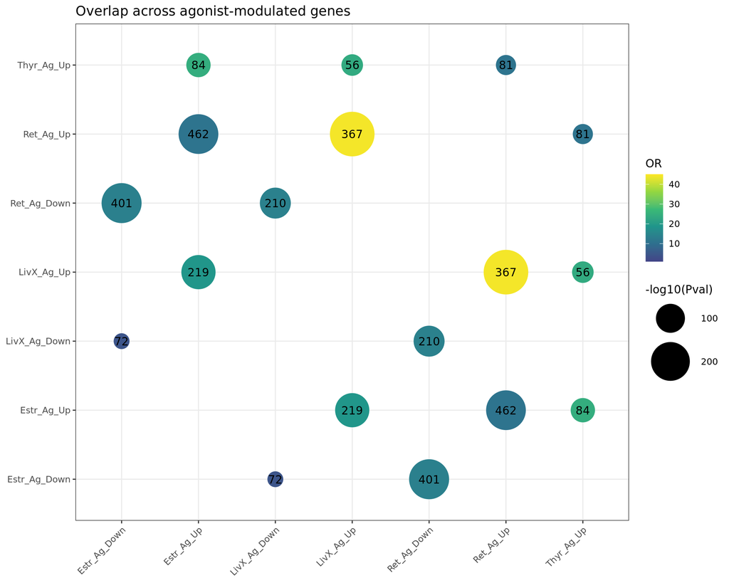

```r
Dot <- ggplot(ResSel, aes(DEGs, KBase, label=Numbers)) +
  geom_point(aes(size=-log10(Pval), col=OR)) +
  geom_text() +
  scale_size_continuous(range=c(2, 20), limits=c(2, round(-log10(min(ResSel$Pval)) + 0.5))) +
  scale_color_viridis_c(limits=c(1, round(max(ResSel$OR)+1)), begin=0.2) + xlab('') + ylab('') +
  theme_bw() +
  theme(axis.line = element_blank(), axis.title = element_blank(),
        axis.text.x = element_text(angle = 45, hjust = 1)) +
  ggtitle('Overlap across agonist-modulated genes')

Dot
```

```r
ggsave(Dot, filename=paste0(OutputFolder, 'DotPlot_Agonist.pdf'), width=8, height=8)
```

## 3.3 Visualize overlap results selectively for retinoic, liverX, estrogen, thyroid

### Selection

```r
Path <- c('Thyr_Ag_Up', 'Thyr_Ag_Down', 'Ret_Ag_Up', 'Ret_Ag_Down',
          'Estr_Ag_Up', 'Estr_Ag_Down', 'LivX_Ag_Up', 'LivX_Ag_Down')
ResPath <- ResSel[ResSel$DEGs %in% Path & ResSel$KBase %in% Path, ]

ResPath
##            DEGs        KBase        OR          Pval Numbers
## 1     Ret_Ag_Up   Thyr_Ag_Up 10.905715  3.063677e-40      81
## 2    Estr_Ag_Up   Thyr_Ag_Up 24.469163  2.641447e-65      84
## 3    LivX_Ag_Up   Thyr_Ag_Up 23.635922  4.556114e-48      56
## 4    Thyr_Ag_Up    Ret_Ag_Up 10.905715  3.063677e-40      81
## 5    Estr_Ag_Up    Ret_Ag_Up 10.923407 3.762356e-212     462
## 6    LivX_Ag_Up    Ret_Ag_Up 44.201409 1.730574e-276     367
## 7  Estr_Ag_Down  Ret_Ag_Down 13.683285 1.370389e-215     401
## 8  LivX_Ag_Down  Ret_Ag_Down 13.934977 6.406226e-118     210
## 9    Thyr_Ag_Up   Estr_Ag_Up 24.469163  2.641447e-65      84
## 10    Ret_Ag_Up   Estr_Ag_Up 10.923407 3.762356e-212     462
## 11   LivX_Ag_Up   Estr_Ag_Up 18.946325 1.688829e-149     219
## 12  Ret_Ag_Down Estr_Ag_Down 13.683285 1.370389e-215     401
## 13 LivX_Ag_Down Estr_Ag_Down  4.387377  3.359345e-21      72
## 14   Thyr_Ag_Up   LivX_Ag_Up 23.635922  4.556114e-48      56
## 15    Ret_Ag_Up   LivX_Ag_Up 44.201409 1.730574e-276     367
## 16   Estr_Ag_Up   LivX_Ag_Up 18.946325 1.688829e-149     219
## 17  Ret_Ag_Down LivX_Ag_Down 13.934977 6.406226e-118     210
## 18 Estr_Ag_Down LivX_Ag_Down  4.387377  3.359345e-21      72
```

### DotPlot: visualization

```r
ResPath <- dplyr::filter(ResPath, OR > 2) %>% dplyr::filter(Numbers > 25)
min(ResPath$Pval)
```

```
## [1] 1.730574e-276
```

```r
max(ResPath$OR)
```

```
## [1] 44.20141
```

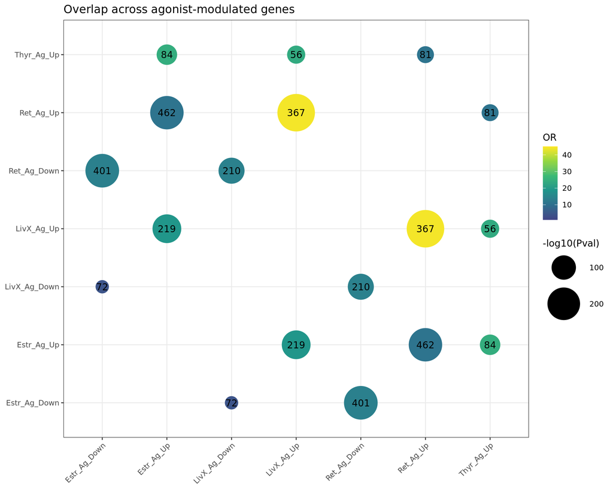

```r
Dot <- ggplot(ResPath, aes(DEGs, KBase, label=Numbers)) +
  geom_point(aes(size=-log10(Pval), col=OR)) +
  geom_text() +
  scale_size_continuous(range=c(2, 20), limits=c(2, round(-log10(min(ResSel$Pval)) + 0.5))) +
  scale_color_viridis_c(limits=c(1, round(max(ResSel$OR)+1)), begin=0.2) + xlab('') + ylab('') +
  theme_bw() +
  theme(axis.line = element_blank(), axis.title = element_blank(),
        axis.text.x = element_text(angle = 45, hjust = 1))+
  ggtitle('Overlap across agonist-modulated genes')


Dot
```

```r
ggsave(Dot, filename=paste0(OutputFolder, 'DotPlot_Agonist_Selected.pdf'), width=8, height=8)
```

# 4. Comparison across pathways: treatment with Inhibitor

## 4.1 Perform Overlap

```r
DEGs_Inh <- list(

  Thyr_Inh_Up= row.names(DEA$Thyr$Inhibitor$DEGs[DEA$Thyr$Inhibitor$DEGs$log2FoldChange > 0, ]),
  Thyr_Inh_Down= row.names(DEA$Thyr$Inhibitor$DEGs[DEA$Thyr$Inhibitor$DEGs$log2FoldChange < 0, ]),

  Ret_Inh_Up= row.names(DEA$Ret$Inhibitor$DEGs[DEA$Ret$Inhibitor$DEGs$log2FoldChange > 0, ]),
  Ret_Inh_Down= row.names(DEA$Ret$Inhibitor$DEGs[DEA$Ret$Inhibitor$DEGs$log2FoldChange < 0, ]),

  Andr_Inh_Up= row.names(DEA$Andr$Inhibitor$DEGs[DEA$Andr$Inhibitor$DEGs$log2FoldChange > 0, ]),
  Andr_Inh_Down= row.names(DEA$Andr$Inhibitor$DEGs[DEA$Andr$Inhibitor$DEGs$log2FoldChange < 0, ]),

  GC_Inh_Up= row.names(DEA$GC$Inhibitor$DEGs[DEA$GC$Inhibitor$DEGs$log2FoldChange > 0, ]),
  GC_Inh_Down= row.names(DEA$GC$Inhibitor$DEGs[DEA$GC$Inhibitor$DEGs$log2FoldChange < 0, ]),

  LivX_Inh_Up= row.names(DEA$LivX$Inhibitor$DEGs[DEA$LivX$Inhibitor$DEGs$log2FoldChange > 0, ]),
  LivX_Inh_Down= row.names(DEA$LivX$Inhibitor$DEGs[DEA$LivX$Inhibitor$DEGs$log2FoldChange < 0, ]),

  AhHyd_Inh_Up= row.names(DEA$AhHyd$Inhibitor$DEGs[DEA$AhHyd$Inhibitor$DEGs$log2FoldChange > 0, ]),
  AhHyd_Inh_Down= row.names(DEA$AhHyd$Inhibitor$DEGs[DEA$AhHyd$Inhibitor$DEGs$log2FoldChange < 0, ])

            )
```

```r
Universe <- row.names(DEA$Ret$Inhibitor$Res) %>% unique()
length(Universe)
## [1] 14850
```

```r
OvObj <- newGOM(DEGs_Inh, DEGs_Inh, genome.size=length(Universe))
print(OvObj)
## A GeneOverlapMatrix object:
## ###### Intersection ######
##                Thyr_Inh_Up Thyr_Inh_Down Ret_Inh_Up Ret_Inh_Down Andr_Inh_Up
## Thyr_Inh_Up            270             0          0            2           0
## Thyr_Inh_Down            0           188          0            1           0
## Ret_Inh_Up               0             0          1            0           0
## Ret_Inh_Down             2             1          0            7           0
## Andr_Inh_Up              0             0          0            0           1
## Andr_Inh_Down            3             0          0            1           0
## GC_Inh_Up               19             0          0            1           0
## GC_Inh_Down              0            65          0            1           0
## LivX_Inh_Up              0             0          0            0           0
## LivX_Inh_Down            2             4          0            6           0
## AhHyd_Inh_Up             5             0          1            0           0
## AhHyd_Inh_Down           0             8          0            0           1
##                Andr_Inh_Down GC_Inh_Up GC_Inh_Down LivX_Inh_Up LivX_Inh_Down
## Thyr_Inh_Up                3        19           0           0             2
## Thyr_Inh_Down              0         0          65           0             4
## Ret_Inh_Up                 0         0           0           0             0
## Ret_Inh_Down               1         1           1           0             6
## Andr_Inh_Up                0         0           0           0             0
## Andr_Inh_Down              8         4           1           0             3
## GC_Inh_Up                  4        48           0           0             2
## GC_Inh_Down                1         0         303           0            10
## LivX_Inh_Up                0         0           0           4             0
## LivX_Inh_Down              3         2          10           0            42
## AhHyd_Inh_Up               0         1           1           0             0
## AhHyd_Inh_Down             0         0           3           0             2
##                AhHyd_Inh_Up AhHyd_Inh_Down
## Thyr_Inh_Up               5              0
## Thyr_Inh_Down             0              8
## Ret_Inh_Up                1              0
## Ret_Inh_Down              0              0
## Andr_Inh_Up               0              1
## Andr_Inh_Down             0              0
## GC_Inh_Up                 1              0
## GC_Inh_Down               1              3
## LivX_Inh_Up               0              0
## LivX_Inh_Down             0              2
## AhHyd_Inh_Up             13              0
## AhHyd_Inh_Down            0             29
## ###### P-value ######
##                 Thyr_Inh_Up Thyr_Inh_Down   Ret_Inh_Up Ret_Inh_Down
## Thyr_Inh_Up    0.000000e+00  1.000000e+00 1.000000e+00 6.511812e-03
## Thyr_Inh_Down  1.000000e+00  0.000000e+00 1.000000e+00 8.534049e-02
## Ret_Inh_Up     1.000000e+00  1.000000e+00 6.734007e-05 1.000000e+00
## Ret_Inh_Down   6.511812e-03  8.534049e-02 1.000000e+00 3.169273e-26
## Andr_Inh_Up    1.000000e+00  1.000000e+00 1.000000e+00 1.000000e+00
## Andr_Inh_Down  3.111080e-04  1.000000e+00 1.000000e+00 3.765714e-03
## GC_Inh_Up      3.270578e-21  1.000000e+00 1.000000e+00 2.241252e-02
## GC_Inh_Down    1.000000e+00  3.521227e-63 1.000000e+00 1.344023e-01
## LivX_Inh_Up    1.000000e+00  1.000000e+00 1.000000e+00 1.000000e+00
## LivX_Inh_Down  1.772825e-01  1.912469e-03 1.000000e+00 2.462733e-15
## AhHyd_Inh_Up   2.187153e-06  1.000000e+00 8.754209e-04 1.000000e+00
## AhHyd_Inh_Down 1.000000e+00  1.943615e-09 1.000000e+00 1.000000e+00
##                 Andr_Inh_Up Andr_Inh_Down     GC_Inh_Up  GC_Inh_Down
## Thyr_Inh_Up    1.000000e+00  3.111080e-04  3.270578e-21 1.000000e+00
## Thyr_Inh_Down  1.000000e+00  1.000000e+00  1.000000e+00 3.521227e-63
## Ret_Inh_Up     1.000000e+00  1.000000e+00  1.000000e+00 1.000000e+00
## Ret_Inh_Down   1.000000e+00  3.765714e-03  2.241252e-02 1.344023e-01
## Andr_Inh_Up    6.734007e-05  1.000000e+00  1.000000e+00 1.000000e+00
## Andr_Inh_Down  1.000000e+00  1.708157e-29  6.661218e-09 1.520723e-01
## GC_Inh_Up      1.000000e+00  6.661218e-09 7.657078e-140 1.000000e+00
## GC_Inh_Down    1.000000e+00  1.520723e-01  1.000000e+00 0.000000e+00
## LivX_Inh_Up    1.000000e+00  1.000000e+00  1.000000e+00 1.000000e+00
## LivX_Inh_Down  1.000000e+00  1.166562e-06  8.112407e-03 8.906368e-09
## AhHyd_Inh_Up   1.000000e+00  1.000000e+00  4.123119e-02 2.351729e-01
## AhHyd_Inh_Down 1.952862e-03  1.000000e+00  1.000000e+00 2.077014e-02
##                 LivX_Inh_Up LivX_Inh_Down AhHyd_Inh_Up AhHyd_Inh_Down
## Thyr_Inh_Up    1.000000e+00  1.772825e-01 2.187153e-06   1.000000e+00
## Thyr_Inh_Down  1.000000e+00  1.912469e-03 1.000000e+00   1.943615e-09
## Ret_Inh_Up     1.000000e+00  1.000000e+00 8.754209e-04   1.000000e+00
## Ret_Inh_Down   1.000000e+00  2.462733e-15 1.000000e+00   1.000000e+00
## Andr_Inh_Up    1.000000e+00  1.000000e+00 1.000000e+00   1.952862e-03
## Andr_Inh_Down  1.000000e+00  1.166562e-06 1.000000e+00   1.000000e+00
## GC_Inh_Up      1.000000e+00  8.112407e-03 4.123119e-02   1.000000e+00
## GC_Inh_Down    1.000000e+00  8.906368e-09 2.351729e-01   2.077014e-02
## LivX_Inh_Up    4.937202e-16  1.000000e+00 1.000000e+00   1.000000e+00
## LivX_Inh_Down  1.000000e+00 9.127902e-125 1.000000e+00   3.020683e-03
## AhHyd_Inh_Up   1.000000e+00  1.000000e+00 3.665373e-45   1.000000e+00
## AhHyd_Inh_Down 1.000000e+00  3.020683e-03 1.000000e+00   9.513776e-91
## ###### Odds Ratio ######
##                Thyr_Inh_Up Thyr_Inh_Down Ret_Inh_Up Ret_Inh_Down Andr_Inh_Up
## Thyr_Inh_Up            Inf      0.000000          0    21.730217           0
## Thyr_Inh_Down     0.000000           Inf          0    13.053133           0
## Ret_Inh_Up        0.000000      0.000000        Inf     0.000000           0
## Ret_Inh_Down     21.730217     13.053133          0          Inf           0
## Andr_Inh_Up       0.000000      0.000000          0     0.000000         Inf
## Andr_Inh_Down    32.708898      0.000000          0   347.875457           0
## GC_Inh_Up        37.929142      0.000000          0    52.274907           0
## GC_Inh_Down       0.000000     31.989423          0     8.021994           0
## LivX_Inh_Up       0.000000      0.000000          0     0.000000           0
## LivX_Inh_Down     2.712281      8.362407          0  2421.329155           0
## AhHyd_Inh_Up     34.320883      0.000000        Inf     0.000000           0
## AhHyd_Inh_Down    0.000000     30.931807          0     0.000000         Inf
##                Andr_Inh_Down GC_Inh_Up GC_Inh_Down LivX_Inh_Up LivX_Inh_Down
## Thyr_Inh_Up        32.708898  37.92914    0.000000           0      2.712281
## Thyr_Inh_Down       0.000000   0.00000   31.989423           0      8.362407
## Ret_Inh_Up          0.000000   0.00000    0.000000           0      0.000000
## Ret_Inh_Down      347.875457  52.27491    8.021994           0   2421.329155
## Andr_Inh_Up         0.000000   0.00000    0.000000           0      0.000000
## Andr_Inh_Down            Inf 333.44051    6.875475           0    224.966301
## GC_Inh_Up         333.440509       Inf    0.000000           0     16.030728
## GC_Inh_Down         6.875475   0.00000         Inf           0     15.473027
## LivX_Inh_Up         0.000000   0.00000    0.000000         Inf      0.000000
## LivX_Inh_Down     224.966301  16.03073   15.473027           0           Inf
## AhHyd_Inh_Up        0.000000  26.19770    4.010017           0      0.000000
## AhHyd_Inh_Down      0.000000   0.00000    5.583418           0     27.338048
##                AhHyd_Inh_Up AhHyd_Inh_Down
## Thyr_Inh_Up       34.320883       0.000000
## Thyr_Inh_Down      0.000000      30.931807
## Ret_Inh_Up              Inf       0.000000
## Ret_Inh_Down       0.000000       0.000000
## Andr_Inh_Up        0.000000            Inf
## Andr_Inh_Down      0.000000       0.000000
## GC_Inh_Up         26.197703       0.000000
## GC_Inh_Down        4.010017       5.583418
## LivX_Inh_Up        0.000000       0.000000
## LivX_Inh_Down      0.000000      27.338048
## AhHyd_Inh_Up            Inf       0.000000
## AhHyd_Inh_Down     0.000000            Inf
## ###### Jaccard Index ######
##                Thyr_Inh_Up Thyr_Inh_Down Ret_Inh_Up Ret_Inh_Down Andr_Inh_Up
## Thyr_Inh_Up    1.000000000   0.000000000 0.00000000  0.007272727  0.00000000
## Thyr_Inh_Down  0.000000000   1.000000000 0.00000000  0.005154639  0.00000000
## Ret_Inh_Up     0.000000000   0.000000000 1.00000000  0.000000000  0.00000000
## Ret_Inh_Down   0.007272727   0.005154639 0.00000000  1.000000000  0.00000000
## Andr_Inh_Up    0.000000000   0.000000000 0.00000000  0.000000000  1.00000000
## Andr_Inh_Down  0.010909091   0.000000000 0.00000000  0.071428571  0.00000000
## GC_Inh_Up      0.063545151   0.000000000 0.00000000  0.018518519  0.00000000
## GC_Inh_Down    0.000000000   0.152582160 0.00000000  0.003236246  0.00000000
## LivX_Inh_Up    0.000000000   0.000000000 0.00000000  0.000000000  0.00000000
## LivX_Inh_Down  0.006451613   0.017699115 0.00000000  0.139534884  0.00000000
## AhHyd_Inh_Up   0.017985612   0.000000000 0.07692308  0.000000000  0.00000000
## AhHyd_Inh_Down 0.000000000   0.038277512 0.00000000  0.000000000  0.03448276
##                Andr_Inh_Down  GC_Inh_Up GC_Inh_Down LivX_Inh_Up LivX_Inh_Down
## Thyr_Inh_Up      0.010909091 0.06354515 0.000000000           0   0.006451613
## Thyr_Inh_Down    0.000000000 0.00000000 0.152582160           0   0.017699115
## Ret_Inh_Up       0.000000000 0.00000000 0.000000000           0   0.000000000
## Ret_Inh_Down     0.071428571 0.01851852 0.003236246           0   0.139534884
## Andr_Inh_Up      0.000000000 0.00000000 0.000000000           0   0.000000000
## Andr_Inh_Down    1.000000000 0.07692308 0.003225806           0   0.063829787
## GC_Inh_Up        0.076923077 1.00000000 0.000000000           0   0.022727273
## GC_Inh_Down      0.003225806 0.00000000 1.000000000           0   0.029850746
## LivX_Inh_Up      0.000000000 0.00000000 0.000000000           1   0.000000000
## LivX_Inh_Down    0.063829787 0.02272727 0.029850746           0   1.000000000
## AhHyd_Inh_Up     0.000000000 0.01666667 0.003174603           0   0.000000000
## AhHyd_Inh_Down   0.000000000 0.00000000 0.009118541           0   0.028985507
##                AhHyd_Inh_Up AhHyd_Inh_Down
## Thyr_Inh_Up     0.017985612    0.000000000
## Thyr_Inh_Down   0.000000000    0.038277512
## Ret_Inh_Up      0.076923077    0.000000000
## Ret_Inh_Down    0.000000000    0.000000000
## Andr_Inh_Up     0.000000000    0.034482759
## Andr_Inh_Down   0.000000000    0.000000000
## GC_Inh_Up       0.016666667    0.000000000
## GC_Inh_Down     0.003174603    0.009118541
## LivX_Inh_Up     0.000000000    0.000000000
## LivX_Inh_Down   0.000000000    0.028985507
## AhHyd_Inh_Up    1.000000000    0.000000000
## AhHyd_Inh_Down  0.000000000    1.000000000
```

```r
getMatrix(OvObj, name='intersection')
##                Thyr_Inh_Up Thyr_Inh_Down Ret_Inh_Up Ret_Inh_Down Andr_Inh_Up
## Thyr_Inh_Up            270             0          0            2           0
## Thyr_Inh_Down            0           188          0            1           0
## Ret_Inh_Up               0             0          1            0           0
## Ret_Inh_Down             2             1          0            7           0
## Andr_Inh_Up              0             0          0            0           1
## Andr_Inh_Down            3             0          0            1           0
## GC_Inh_Up               19             0          0            1           0
## GC_Inh_Down              0            65          0            1           0
## LivX_Inh_Up              0             0          0            0           0
## LivX_Inh_Down            2             4          0            6           0
## AhHyd_Inh_Up             5             0          1            0           0
## AhHyd_Inh_Down           0             8          0            0           1
##                Andr_Inh_Down GC_Inh_Up GC_Inh_Down LivX_Inh_Up LivX_Inh_Down
## Thyr_Inh_Up                3        19           0           0             2
## Thyr_Inh_Down              0         0          65           0             4
## Ret_Inh_Up                 0         0           0           0             0
## Ret_Inh_Down               1         1           1           0             6
## Andr_Inh_Up                0         0           0           0             0
## Andr_Inh_Down              8         4           1           0             3
## GC_Inh_Up                  4        48           0           0             2
## GC_Inh_Down                1         0         303           0            10
## LivX_Inh_Up                0         0           0           4             0
## LivX_Inh_Down              3         2          10           0            42
## AhHyd_Inh_Up               0         1           1           0             0
## AhHyd_Inh_Down             0         0           3           0             2
##                AhHyd_Inh_Up AhHyd_Inh_Down
## Thyr_Inh_Up               5              0
## Thyr_Inh_Down             0              8
## Ret_Inh_Up                1              0
## Ret_Inh_Down              0              0
## Andr_Inh_Up               0              1
## Andr_Inh_Down             0              0
## GC_Inh_Up                 1              0
## GC_Inh_Down               1              3
## LivX_Inh_Up               0              0
## LivX_Inh_Down             0              2
## AhHyd_Inh_Up             13              0
## AhHyd_Inh_Down            0             29
```

```r
getMatrix(OvObj, name='pval')
##                 Thyr_Inh_Up Thyr_Inh_Down   Ret_Inh_Up Ret_Inh_Down
## Thyr_Inh_Up    0.000000e+00  1.000000e+00 1.000000e+00 6.511812e-03
## Thyr_Inh_Down  1.000000e+00  0.000000e+00 1.000000e+00 8.534049e-02
## Ret_Inh_Up     1.000000e+00  1.000000e+00 6.734007e-05 1.000000e+00
## Ret_Inh_Down   6.511812e-03  8.534049e-02 1.000000e+00 3.169273e-26
## Andr_Inh_Up    1.000000e+00  1.000000e+00 1.000000e+00 1.000000e+00
## Andr_Inh_Down  3.111080e-04  1.000000e+00 1.000000e+00 3.765714e-03
## GC_Inh_Up      3.270578e-21  1.000000e+00 1.000000e+00 2.241252e-02
## GC_Inh_Down    1.000000e+00  3.521227e-63 1.000000e+00 1.344023e-01
## LivX_Inh_Up    1.000000e+00  1.000000e+00 1.000000e+00 1.000000e+00
## LivX_Inh_Down  1.772825e-01  1.912469e-03 1.000000e+00 2.462733e-15
## AhHyd_Inh_Up   2.187153e-06  1.000000e+00 8.754209e-04 1.000000e+00
## AhHyd_Inh_Down 1.000000e+00  1.943615e-09 1.000000e+00 1.000000e+00
##                 Andr_Inh_Up Andr_Inh_Down     GC_Inh_Up  GC_Inh_Down
## Thyr_Inh_Up    1.000000e+00  3.111080e-04  3.270578e-21 1.000000e+00
## Thyr_Inh_Down  1.000000e+00  1.000000e+00  1.000000e+00 3.521227e-63
## Ret_Inh_Up     1.000000e+00  1.000000e+00  1.000000e+00 1.000000e+00
## Ret_Inh_Down   1.000000e+00  3.765714e-03  2.241252e-02 1.344023e-01
## Andr_Inh_Up    6.734007e-05  1.000000e+00  1.000000e+00 1.000000e+00
## Andr_Inh_Down  1.000000e+00  1.708157e-29  6.661218e-09 1.520723e-01
## GC_Inh_Up      1.000000e+00  6.661218e-09 7.657078e-140 1.000000e+00
## GC_Inh_Down    1.000000e+00  1.520723e-01  1.000000e+00 0.000000e+00
## LivX_Inh_Up    1.000000e+00  1.000000e+00  1.000000e+00 1.000000e+00
## LivX_Inh_Down  1.000000e+00  1.166562e-06  8.112407e-03 8.906368e-09
## AhHyd_Inh_Up   1.000000e+00  1.000000e+00  4.123119e-02 2.351729e-01
## AhHyd_Inh_Down 1.952862e-03  1.000000e+00  1.000000e+00 2.077014e-02
##                 LivX_Inh_Up LivX_Inh_Down AhHyd_Inh_Up AhHyd_Inh_Down
## Thyr_Inh_Up    1.000000e+00  1.772825e-01 2.187153e-06   1.000000e+00
## Thyr_Inh_Down  1.000000e+00  1.912469e-03 1.000000e+00   1.943615e-09
## Ret_Inh_Up     1.000000e+00  1.000000e+00 8.754209e-04   1.000000e+00
## Ret_Inh_Down   1.000000e+00  2.462733e-15 1.000000e+00   1.000000e+00
## Andr_Inh_Up    1.000000e+00  1.000000e+00 1.000000e+00   1.952862e-03
## Andr_Inh_Down  1.000000e+00  1.166562e-06 1.000000e+00   1.000000e+00
## GC_Inh_Up      1.000000e+00  8.112407e-03 4.123119e-02   1.000000e+00
## GC_Inh_Down    1.000000e+00  8.906368e-09 2.351729e-01   2.077014e-02
## LivX_Inh_Up    4.937202e-16  1.000000e+00 1.000000e+00   1.000000e+00
## LivX_Inh_Down  1.000000e+00 9.127902e-125 1.000000e+00   3.020683e-03
## AhHyd_Inh_Up   1.000000e+00  1.000000e+00 3.665373e-45   1.000000e+00
## AhHyd_Inh_Down 1.000000e+00  3.020683e-03 1.000000e+00   9.513776e-91
```

```r
getMatrix(OvObj, name='odds.ratio')
##                Thyr_Inh_Up Thyr_Inh_Down Ret_Inh_Up Ret_Inh_Down Andr_Inh_Up
## Thyr_Inh_Up            Inf      0.000000          0    21.730217           0
## Thyr_Inh_Down     0.000000           Inf          0    13.053133           0
## Ret_Inh_Up        0.000000      0.000000        Inf     0.000000           0
## Ret_Inh_Down     21.730217     13.053133          0          Inf           0
## Andr_Inh_Up       0.000000      0.000000          0     0.000000         Inf
## Andr_Inh_Down    32.708898      0.000000          0   347.875457           0
## GC_Inh_Up        37.929142      0.000000          0    52.274907           0
## GC_Inh_Down       0.000000     31.989423          0     8.021994           0
## LivX_Inh_Up       0.000000      0.000000          0     0.000000           0
## LivX_Inh_Down     2.712281      8.362407          0  2421.329155           0
## AhHyd_Inh_Up     34.320883      0.000000        Inf     0.000000           0
## AhHyd_Inh_Down    0.000000     30.931807          0     0.000000         Inf
##                Andr_Inh_Down GC_Inh_Up GC_Inh_Down LivX_Inh_Up LivX_Inh_Down
## Thyr_Inh_Up        32.708898  37.92914    0.000000           0      2.712281
## Thyr_Inh_Down       0.000000   0.00000   31.989423           0      8.362407
## Ret_Inh_Up          0.000000   0.00000    0.000000           0      0.000000
## Ret_Inh_Down      347.875457  52.27491    8.021994           0   2421.329155
## Andr_Inh_Up         0.000000   0.00000    0.000000           0      0.000000
## Andr_Inh_Down            Inf 333.44051    6.875475           0    224.966301
## GC_Inh_Up         333.440509       Inf    0.000000           0     16.030728
## GC_Inh_Down         6.875475   0.00000         Inf           0     15.473027
## LivX_Inh_Up         0.000000   0.00000    0.000000         Inf      0.000000
## LivX_Inh_Down     224.966301  16.03073   15.473027           0           Inf
## AhHyd_Inh_Up        0.000000  26.19770    4.010017           0      0.000000
## AhHyd_Inh_Down      0.000000   0.00000    5.583418           0     27.338048
##                AhHyd_Inh_Up AhHyd_Inh_Down
## Thyr_Inh_Up       34.320883       0.000000
## Thyr_Inh_Down      0.000000      30.931807
## Ret_Inh_Up              Inf       0.000000
## Ret_Inh_Down       0.000000       0.000000
## Andr_Inh_Up        0.000000            Inf
## Andr_Inh_Down      0.000000       0.000000
## GC_Inh_Up         26.197703       0.000000
## GC_Inh_Down        4.010017       5.583418
## LivX_Inh_Up        0.000000       0.000000
## LivX_Inh_Down      0.000000      27.338048
## AhHyd_Inh_Up            Inf       0.000000
## AhHyd_Inh_Down     0.000000            Inf
```

## 4.2 Visualize overlap results

### DotPlot: data preparation

```r
OR <- data.frame(getMatrix(OvObj, name='odds.ratio'))
OR$DEGs <- row.names(OR)
OR <- gather(OR, 'KBase', 'OR', -DEGs)
PVAL <- data.frame(getMatrix(OvObj, name='pval'))
PVAL$DEGs <- row.names(PVAL)
PVAL <- gather(PVAL, 'KBase', 'PVal', -DEGs)
NUM <- data.frame(getMatrix(OvObj, name='intersection'))
NUM$DEGs <- row.names(NUM)
NUM <- gather(NUM, 'KBase', 'Numbers', -DEGs)
if(! identical(OR$DEGs, PVAL$DEGs)){
  stop('Inconsistecy')
}
if(! identical(OR$DEGs, NUM$DEGs)){
  stop('Inconsistecy')
}
if(! identical(OR$KBase, NUM$KBase)){
  stop('Inconsistecy')
}
if(! identical(OR$KBase, NUM$KBase)){
  stop('Inconsistecy')
}
Res <- mutate(OR, Pval=PVAL$PVal) %>% mutate(Numbers=NUM$Numbers)
Res
##               DEGs          KBase          OR          Pval Numbers
## 1      Thyr_Inh_Up    Thyr_Inh_Up         Inf  0.000000e+00     270
## 2    Thyr_Inh_Down    Thyr_Inh_Up    0.000000  1.000000e+00       0
## 3       Ret_Inh_Up    Thyr_Inh_Up    0.000000  1.000000e+00       0
## 4     Ret_Inh_Down    Thyr_Inh_Up   21.730217  6.511812e-03       2
## 5      Andr_Inh_Up    Thyr_Inh_Up    0.000000  1.000000e+00       0
## 6    Andr_Inh_Down    Thyr_Inh_Up   32.708898  3.111080e-04       3
## 7        GC_Inh_Up    Thyr_Inh_Up   37.929142  3.270578e-21      19
## 8      GC_Inh_Down    Thyr_Inh_Up    0.000000  1.000000e+00       0
## 9      LivX_Inh_Up    Thyr_Inh_Up    0.000000  1.000000e+00       0
## 10   LivX_Inh_Down    Thyr_Inh_Up    2.712281  1.772825e-01       2
## 11    AhHyd_Inh_Up    Thyr_Inh_Up   34.320883  2.187153e-06       5
## 12  AhHyd_Inh_Down    Thyr_Inh_Up    0.000000  1.000000e+00       0
## 13     Thyr_Inh_Up  Thyr_Inh_Down    0.000000  1.000000e+00       0
## 14   Thyr_Inh_Down  Thyr_Inh_Down         Inf  0.000000e+00     188
## 15      Ret_Inh_Up  Thyr_Inh_Down    0.000000  1.000000e+00       0
## 16    Ret_Inh_Down  Thyr_Inh_Down   13.053133  8.534049e-02       1
## 17     Andr_Inh_Up  Thyr_Inh_Down    0.000000  1.000000e+00       0
## 18   Andr_Inh_Down  Thyr_Inh_Down    0.000000  1.000000e+00       0
## 19       GC_Inh_Up  Thyr_Inh_Down    0.000000  1.000000e+00       0
## 20     GC_Inh_Down  Thyr_Inh_Down   31.989423  3.521227e-63      65
## 21     LivX_Inh_Up  Thyr_Inh_Down    0.000000  1.000000e+00       0
## 22   LivX_Inh_Down  Thyr_Inh_Down    8.362407  1.912469e-03       4
## 23    AhHyd_Inh_Up  Thyr_Inh_Down    0.000000  1.000000e+00       0
## 24  AhHyd_Inh_Down  Thyr_Inh_Down   30.931807  1.943615e-09       8
## 25     Thyr_Inh_Up     Ret_Inh_Up    0.000000  1.000000e+00       0
## 26   Thyr_Inh_Down     Ret_Inh_Up    0.000000  1.000000e+00       0
## 27      Ret_Inh_Up     Ret_Inh_Up         Inf  6.734007e-05       1
## 28    Ret_Inh_Down     Ret_Inh_Up    0.000000  1.000000e+00       0
## 29     Andr_Inh_Up     Ret_Inh_Up    0.000000  1.000000e+00       0
## 30   Andr_Inh_Down     Ret_Inh_Up    0.000000  1.000000e+00       0
## 31       GC_Inh_Up     Ret_Inh_Up    0.000000  1.000000e+00       0
## 32     GC_Inh_Down     Ret_Inh_Up    0.000000  1.000000e+00       0
## 33     LivX_Inh_Up     Ret_Inh_Up    0.000000  1.000000e+00       0
## 34   LivX_Inh_Down     Ret_Inh_Up    0.000000  1.000000e+00       0
## 35    AhHyd_Inh_Up     Ret_Inh_Up         Inf  8.754209e-04       1
## 36  AhHyd_Inh_Down     Ret_Inh_Up    0.000000  1.000000e+00       0
## 37     Thyr_Inh_Up   Ret_Inh_Down   21.730217  6.511812e-03       2
## 38   Thyr_Inh_Down   Ret_Inh_Down   13.053133  8.534049e-02       1
## 39      Ret_Inh_Up   Ret_Inh_Down    0.000000  1.000000e+00       0
## 40    Ret_Inh_Down   Ret_Inh_Down         Inf  3.169273e-26       7
## 41     Andr_Inh_Up   Ret_Inh_Down    0.000000  1.000000e+00       0
## 42   Andr_Inh_Down   Ret_Inh_Down  347.875457  3.765714e-03       1
## 43       GC_Inh_Up   Ret_Inh_Down   52.274907  2.241252e-02       1
## 44     GC_Inh_Down   Ret_Inh_Down    8.021994  1.344023e-01       1
## 45     LivX_Inh_Up   Ret_Inh_Down    0.000000  1.000000e+00       0
## 46   LivX_Inh_Down   Ret_Inh_Down 2421.329155  2.462733e-15       6
## 47    AhHyd_Inh_Up   Ret_Inh_Down    0.000000  1.000000e+00       0
## 48  AhHyd_Inh_Down   Ret_Inh_Down    0.000000  1.000000e+00       0
## 49     Thyr_Inh_Up    Andr_Inh_Up    0.000000  1.000000e+00       0
## 50   Thyr_Inh_Down    Andr_Inh_Up    0.000000  1.000000e+00       0
## 51      Ret_Inh_Up    Andr_Inh_Up    0.000000  1.000000e+00       0
## 52    Ret_Inh_Down    Andr_Inh_Up    0.000000  1.000000e+00       0
## 53     Andr_Inh_Up    Andr_Inh_Up         Inf  6.734007e-05       1
## 54   Andr_Inh_Down    Andr_Inh_Up    0.000000  1.000000e+00       0
## 55       GC_Inh_Up    Andr_Inh_Up    0.000000  1.000000e+00       0
## 56     GC_Inh_Down    Andr_Inh_Up    0.000000  1.000000e+00       0
## 57     LivX_Inh_Up    Andr_Inh_Up    0.000000  1.000000e+00       0
## 58   LivX_Inh_Down    Andr_Inh_Up    0.000000  1.000000e+00       0
## 59    AhHyd_Inh_Up    Andr_Inh_Up    0.000000  1.000000e+00       0
## 60  AhHyd_Inh_Down    Andr_Inh_Up         Inf  1.952862e-03       1
## 61     Thyr_Inh_Up  Andr_Inh_Down   32.708898  3.111080e-04       3
## 62   Thyr_Inh_Down  Andr_Inh_Down    0.000000  1.000000e+00       0
## 63      Ret_Inh_Up  Andr_Inh_Down    0.000000  1.000000e+00       0
## 64    Ret_Inh_Down  Andr_Inh_Down  347.875457  3.765714e-03       1
## 65     Andr_Inh_Up  Andr_Inh_Down    0.000000  1.000000e+00       0
## 66   Andr_Inh_Down  Andr_Inh_Down         Inf  1.708157e-29       8
## 67       GC_Inh_Up  Andr_Inh_Down  333.440509  6.661218e-09       4
## 68     GC_Inh_Down  Andr_Inh_Down    6.875475  1.520723e-01       1
## 69     LivX_Inh_Up  Andr_Inh_Down    0.000000  1.000000e+00       0
## 70   LivX_Inh_Down  Andr_Inh_Down  224.966301  1.166562e-06       3
## 71    AhHyd_Inh_Up  Andr_Inh_Down    0.000000  1.000000e+00       0
## 72  AhHyd_Inh_Down  Andr_Inh_Down    0.000000  1.000000e+00       0
## 73     Thyr_Inh_Up      GC_Inh_Up   37.929142  3.270578e-21      19
## 74   Thyr_Inh_Down      GC_Inh_Up    0.000000  1.000000e+00       0
## 75      Ret_Inh_Up      GC_Inh_Up    0.000000  1.000000e+00       0
## 76    Ret_Inh_Down      GC_Inh_Up   52.274907  2.241252e-02       1
## 77     Andr_Inh_Up      GC_Inh_Up    0.000000  1.000000e+00       0
## 78   Andr_Inh_Down      GC_Inh_Up  333.440509  6.661218e-09       4
## 79       GC_Inh_Up      GC_Inh_Up         Inf 7.657078e-140      48
## 80     GC_Inh_Down      GC_Inh_Up    0.000000  1.000000e+00       0
## 81     LivX_Inh_Up      GC_Inh_Up    0.000000  1.000000e+00       0
## 82   LivX_Inh_Down      GC_Inh_Up   16.030728  8.112407e-03       2
## 83    AhHyd_Inh_Up      GC_Inh_Up   26.197703  4.123119e-02       1
## 84  AhHyd_Inh_Down      GC_Inh_Up    0.000000  1.000000e+00       0
## 85     Thyr_Inh_Up    GC_Inh_Down    0.000000  1.000000e+00       0
## 86   Thyr_Inh_Down    GC_Inh_Down   31.989423  3.521227e-63      65
## 87      Ret_Inh_Up    GC_Inh_Down    0.000000  1.000000e+00       0
## 88    Ret_Inh_Down    GC_Inh_Down    8.021994  1.344023e-01       1
## 89     Andr_Inh_Up    GC_Inh_Down    0.000000  1.000000e+00       0
## 90   Andr_Inh_Down    GC_Inh_Down    6.875475  1.520723e-01       1
## 91       GC_Inh_Up    GC_Inh_Down    0.000000  1.000000e+00       0
## 92     GC_Inh_Down    GC_Inh_Down         Inf  0.000000e+00     303
## 93     LivX_Inh_Up    GC_Inh_Down    0.000000  1.000000e+00       0
## 94   LivX_Inh_Down    GC_Inh_Down   15.473027  8.906368e-09      10
## 95    AhHyd_Inh_Up    GC_Inh_Down    4.010017  2.351729e-01       1
## 96  AhHyd_Inh_Down    GC_Inh_Down    5.583418  2.077014e-02       3
## 97     Thyr_Inh_Up    LivX_Inh_Up    0.000000  1.000000e+00       0
## 98   Thyr_Inh_Down    LivX_Inh_Up    0.000000  1.000000e+00       0
## 99      Ret_Inh_Up    LivX_Inh_Up    0.000000  1.000000e+00       0
## 100   Ret_Inh_Down    LivX_Inh_Up    0.000000  1.000000e+00       0
## 101    Andr_Inh_Up    LivX_Inh_Up    0.000000  1.000000e+00       0
## 102  Andr_Inh_Down    LivX_Inh_Up    0.000000  1.000000e+00       0
## 103      GC_Inh_Up    LivX_Inh_Up    0.000000  1.000000e+00       0
## 104    GC_Inh_Down    LivX_Inh_Up    0.000000  1.000000e+00       0
## 105    LivX_Inh_Up    LivX_Inh_Up         Inf  4.937202e-16       4
## 106  LivX_Inh_Down    LivX_Inh_Up    0.000000  1.000000e+00       0
## 107   AhHyd_Inh_Up    LivX_Inh_Up    0.000000  1.000000e+00       0
## 108 AhHyd_Inh_Down    LivX_Inh_Up    0.000000  1.000000e+00       0
## 109    Thyr_Inh_Up  LivX_Inh_Down    2.712281  1.772825e-01       2
## 110  Thyr_Inh_Down  LivX_Inh_Down    8.362407  1.912469e-03       4
## 111     Ret_Inh_Up  LivX_Inh_Down    0.000000  1.000000e+00       0
## 112   Ret_Inh_Down  LivX_Inh_Down 2421.329155  2.462733e-15       6
## 113    Andr_Inh_Up  LivX_Inh_Down    0.000000  1.000000e+00       0
## 114  Andr_Inh_Down  LivX_Inh_Down  224.966301  1.166562e-06       3
## 115      GC_Inh_Up  LivX_Inh_Down   16.030728  8.112407e-03       2
## 116    GC_Inh_Down  LivX_Inh_Down   15.473027  8.906368e-09      10
## 117    LivX_Inh_Up  LivX_Inh_Down    0.000000  1.000000e+00       0
## 118  LivX_Inh_Down  LivX_Inh_Down         Inf 9.127902e-125      42
## 119   AhHyd_Inh_Up  LivX_Inh_Down    0.000000  1.000000e+00       0
## 120 AhHyd_Inh_Down  LivX_Inh_Down   27.338048  3.020683e-03       2
## 121    Thyr_Inh_Up   AhHyd_Inh_Up   34.320883  2.187153e-06       5
## 122  Thyr_Inh_Down   AhHyd_Inh_Up    0.000000  1.000000e+00       0
## 123     Ret_Inh_Up   AhHyd_Inh_Up         Inf  8.754209e-04       1
## 124   Ret_Inh_Down   AhHyd_Inh_Up    0.000000  1.000000e+00       0
## 125    Andr_Inh_Up   AhHyd_Inh_Up    0.000000  1.000000e+00       0
## 126  Andr_Inh_Down   AhHyd_Inh_Up    0.000000  1.000000e+00       0
## 127      GC_Inh_Up   AhHyd_Inh_Up   26.197703  4.123119e-02       1
## 128    GC_Inh_Down   AhHyd_Inh_Up    4.010017  2.351729e-01       1
## 129    LivX_Inh_Up   AhHyd_Inh_Up    0.000000  1.000000e+00       0
## 130  LivX_Inh_Down   AhHyd_Inh_Up    0.000000  1.000000e+00       0
## 131   AhHyd_Inh_Up   AhHyd_Inh_Up         Inf  3.665373e-45      13
## 132 AhHyd_Inh_Down   AhHyd_Inh_Up    0.000000  1.000000e+00       0
## 133    Thyr_Inh_Up AhHyd_Inh_Down    0.000000  1.000000e+00       0
## 134  Thyr_Inh_Down AhHyd_Inh_Down   30.931807  1.943615e-09       8
## 135     Ret_Inh_Up AhHyd_Inh_Down    0.000000  1.000000e+00       0
## 136   Ret_Inh_Down AhHyd_Inh_Down    0.000000  1.000000e+00       0
## 137    Andr_Inh_Up AhHyd_Inh_Down         Inf  1.952862e-03       1
## 138  Andr_Inh_Down AhHyd_Inh_Down    0.000000  1.000000e+00       0
## 139      GC_Inh_Up AhHyd_Inh_Down    0.000000  1.000000e+00       0
## 140    GC_Inh_Down AhHyd_Inh_Down    5.583418  2.077014e-02       3
## 141    LivX_Inh_Up AhHyd_Inh_Down    0.000000  1.000000e+00       0
## 142  LivX_Inh_Down AhHyd_Inh_Down   27.338048  3.020683e-03       2
## 143   AhHyd_Inh_Up AhHyd_Inh_Down    0.000000  1.000000e+00       0
## 144 AhHyd_Inh_Down AhHyd_Inh_Down         Inf  9.513776e-91      29
```

```r
ResMod <- Res

ResMod[ResMod$DEGs == ResMod$KBase, ]$OR <- 1
ResMod[ResMod$DEGs == ResMod$KBase, ]$Pval <- 1

ResMod
##               DEGs          KBase          OR         Pval Numbers
## 1      Thyr_Inh_Up    Thyr_Inh_Up    1.000000 1.000000e+00     270
## 2    Thyr_Inh_Down    Thyr_Inh_Up    0.000000 1.000000e+00       0
## 3       Ret_Inh_Up    Thyr_Inh_Up    0.000000 1.000000e+00       0
## 4     Ret_Inh_Down    Thyr_Inh_Up   21.730217 6.511812e-03       2
## 5      Andr_Inh_Up    Thyr_Inh_Up    0.000000 1.000000e+00       0
## 6    Andr_Inh_Down    Thyr_Inh_Up   32.708898 3.111080e-04       3
## 7        GC_Inh_Up    Thyr_Inh_Up   37.929142 3.270578e-21      19
## 8      GC_Inh_Down    Thyr_Inh_Up    0.000000 1.000000e+00       0
## 9      LivX_Inh_Up    Thyr_Inh_Up    0.000000 1.000000e+00       0
## 10   LivX_Inh_Down    Thyr_Inh_Up    2.712281 1.772825e-01       2
## 11    AhHyd_Inh_Up    Thyr_Inh_Up   34.320883 2.187153e-06       5
## 12  AhHyd_Inh_Down    Thyr_Inh_Up    0.000000 1.000000e+00       0
## 13     Thyr_Inh_Up  Thyr_Inh_Down    0.000000 1.000000e+00       0
## 14   Thyr_Inh_Down  Thyr_Inh_Down    1.000000 1.000000e+00     188
## 15      Ret_Inh_Up  Thyr_Inh_Down    0.000000 1.000000e+00       0
## 16    Ret_Inh_Down  Thyr_Inh_Down   13.053133 8.534049e-02       1
## 17     Andr_Inh_Up  Thyr_Inh_Down    0.000000 1.000000e+00       0
## 18   Andr_Inh_Down  Thyr_Inh_Down    0.000000 1.000000e+00       0
## 19       GC_Inh_Up  Thyr_Inh_Down    0.000000 1.000000e+00       0
## 20     GC_Inh_Down  Thyr_Inh_Down   31.989423 3.521227e-63      65
## 21     LivX_Inh_Up  Thyr_Inh_Down    0.000000 1.000000e+00       0
## 22   LivX_Inh_Down  Thyr_Inh_Down    8.362407 1.912469e-03       4
## 23    AhHyd_Inh_Up  Thyr_Inh_Down    0.000000 1.000000e+00       0
## 24  AhHyd_Inh_Down  Thyr_Inh_Down   30.931807 1.943615e-09       8
## 25     Thyr_Inh_Up     Ret_Inh_Up    0.000000 1.000000e+00       0
## 26   Thyr_Inh_Down     Ret_Inh_Up    0.000000 1.000000e+00       0
## 27      Ret_Inh_Up     Ret_Inh_Up    1.000000 1.000000e+00       1
## 28    Ret_Inh_Down     Ret_Inh_Up    0.000000 1.000000e+00       0
## 29     Andr_Inh_Up     Ret_Inh_Up    0.000000 1.000000e+00       0
## 30   Andr_Inh_Down     Ret_Inh_Up    0.000000 1.000000e+00       0
## 31       GC_Inh_Up     Ret_Inh_Up    0.000000 1.000000e+00       0
## 32     GC_Inh_Down     Ret_Inh_Up    0.000000 1.000000e+00       0
## 33     LivX_Inh_Up     Ret_Inh_Up    0.000000 1.000000e+00       0
## 34   LivX_Inh_Down     Ret_Inh_Up    0.000000 1.000000e+00       0
## 35    AhHyd_Inh_Up     Ret_Inh_Up         Inf 8.754209e-04       1
## 36  AhHyd_Inh_Down     Ret_Inh_Up    0.000000 1.000000e+00       0
## 37     Thyr_Inh_Up   Ret_Inh_Down   21.730217 6.511812e-03       2
## 38   Thyr_Inh_Down   Ret_Inh_Down   13.053133 8.534049e-02       1
## 39      Ret_Inh_Up   Ret_Inh_Down    0.000000 1.000000e+00       0
## 40    Ret_Inh_Down   Ret_Inh_Down    1.000000 1.000000e+00       7
## 41     Andr_Inh_Up   Ret_Inh_Down    0.000000 1.000000e+00       0
## 42   Andr_Inh_Down   Ret_Inh_Down  347.875457 3.765714e-03       1
## 43       GC_Inh_Up   Ret_Inh_Down   52.274907 2.241252e-02       1
## 44     GC_Inh_Down   Ret_Inh_Down    8.021994 1.344023e-01       1
## 45     LivX_Inh_Up   Ret_Inh_Down    0.000000 1.000000e+00       0
## 46   LivX_Inh_Down   Ret_Inh_Down 2421.329155 2.462733e-15       6
## 47    AhHyd_Inh_Up   Ret_Inh_Down    0.000000 1.000000e+00       0
## 48  AhHyd_Inh_Down   Ret_Inh_Down    0.000000 1.000000e+00       0
## 49     Thyr_Inh_Up    Andr_Inh_Up    0.000000 1.000000e+00       0
## 50   Thyr_Inh_Down    Andr_Inh_Up    0.000000 1.000000e+00       0
## 51      Ret_Inh_Up    Andr_Inh_Up    0.000000 1.000000e+00       0
## 52    Ret_Inh_Down    Andr_Inh_Up    0.000000 1.000000e+00       0
## 53     Andr_Inh_Up    Andr_Inh_Up    1.000000 1.000000e+00       1
## 54   Andr_Inh_Down    Andr_Inh_Up    0.000000 1.000000e+00       0
## 55       GC_Inh_Up    Andr_Inh_Up    0.000000 1.000000e+00       0
## 56     GC_Inh_Down    Andr_Inh_Up    0.000000 1.000000e+00       0
## 57     LivX_Inh_Up    Andr_Inh_Up    0.000000 1.000000e+00       0
## 58   LivX_Inh_Down    Andr_Inh_Up    0.000000 1.000000e+00       0
## 59    AhHyd_Inh_Up    Andr_Inh_Up    0.000000 1.000000e+00       0
## 60  AhHyd_Inh_Down    Andr_Inh_Up         Inf 1.952862e-03       1
## 61     Thyr_Inh_Up  Andr_Inh_Down   32.708898 3.111080e-04       3
## 62   Thyr_Inh_Down  Andr_Inh_Down    0.000000 1.000000e+00       0
## 63      Ret_Inh_Up  Andr_Inh_Down    0.000000 1.000000e+00       0
## 64    Ret_Inh_Down  Andr_Inh_Down  347.875457 3.765714e-03       1
## 65     Andr_Inh_Up  Andr_Inh_Down    0.000000 1.000000e+00       0
## 66   Andr_Inh_Down  Andr_Inh_Down    1.000000 1.000000e+00       8
## 67       GC_Inh_Up  Andr_Inh_Down  333.440509 6.661218e-09       4
## 68     GC_Inh_Down  Andr_Inh_Down    6.875475 1.520723e-01       1
## 69     LivX_Inh_Up  Andr_Inh_Down    0.000000 1.000000e+00       0
## 70   LivX_Inh_Down  Andr_Inh_Down  224.966301 1.166562e-06       3
## 71    AhHyd_Inh_Up  Andr_Inh_Down    0.000000 1.000000e+00       0
## 72  AhHyd_Inh_Down  Andr_Inh_Down    0.000000 1.000000e+00       0
## 73     Thyr_Inh_Up      GC_Inh_Up   37.929142 3.270578e-21      19
## 74   Thyr_Inh_Down      GC_Inh_Up    0.000000 1.000000e+00       0
## 75      Ret_Inh_Up      GC_Inh_Up    0.000000 1.000000e+00       0
## 76    Ret_Inh_Down      GC_Inh_Up   52.274907 2.241252e-02       1
## 77     Andr_Inh_Up      GC_Inh_Up    0.000000 1.000000e+00       0
## 78   Andr_Inh_Down      GC_Inh_Up  333.440509 6.661218e-09       4
## 79       GC_Inh_Up      GC_Inh_Up    1.000000 1.000000e+00      48
## 80     GC_Inh_Down      GC_Inh_Up    0.000000 1.000000e+00       0
## 81     LivX_Inh_Up      GC_Inh_Up    0.000000 1.000000e+00       0
## 82   LivX_Inh_Down      GC_Inh_Up   16.030728 8.112407e-03       2
## 83    AhHyd_Inh_Up      GC_Inh_Up   26.197703 4.123119e-02       1
## 84  AhHyd_Inh_Down      GC_Inh_Up    0.000000 1.000000e+00       0
## 85     Thyr_Inh_Up    GC_Inh_Down    0.000000 1.000000e+00       0
## 86   Thyr_Inh_Down    GC_Inh_Down   31.989423 3.521227e-63      65
## 87      Ret_Inh_Up    GC_Inh_Down    0.000000 1.000000e+00       0
## 88    Ret_Inh_Down    GC_Inh_Down    8.021994 1.344023e-01       1
## 89     Andr_Inh_Up    GC_Inh_Down    0.000000 1.000000e+00       0
## 90   Andr_Inh_Down    GC_Inh_Down    6.875475 1.520723e-01       1
## 91       GC_Inh_Up    GC_Inh_Down    0.000000 1.000000e+00       0
## 92     GC_Inh_Down    GC_Inh_Down    1.000000 1.000000e+00     303
## 93     LivX_Inh_Up    GC_Inh_Down    0.000000 1.000000e+00       0
## 94   LivX_Inh_Down    GC_Inh_Down   15.473027 8.906368e-09      10
## 95    AhHyd_Inh_Up    GC_Inh_Down    4.010017 2.351729e-01       1
## 96  AhHyd_Inh_Down    GC_Inh_Down    5.583418 2.077014e-02       3
## 97     Thyr_Inh_Up    LivX_Inh_Up    0.000000 1.000000e+00       0
## 98   Thyr_Inh_Down    LivX_Inh_Up    0.000000 1.000000e+00       0
## 99      Ret_Inh_Up    LivX_Inh_Up    0.000000 1.000000e+00       0
## 100   Ret_Inh_Down    LivX_Inh_Up    0.000000 1.000000e+00       0
## 101    Andr_Inh_Up    LivX_Inh_Up    0.000000 1.000000e+00       0
## 102  Andr_Inh_Down    LivX_Inh_Up    0.000000 1.000000e+00       0
## 103      GC_Inh_Up    LivX_Inh_Up    0.000000 1.000000e+00       0
## 104    GC_Inh_Down    LivX_Inh_Up    0.000000 1.000000e+00       0
## 105    LivX_Inh_Up    LivX_Inh_Up    1.000000 1.000000e+00       4
## 106  LivX_Inh_Down    LivX_Inh_Up    0.000000 1.000000e+00       0
## 107   AhHyd_Inh_Up    LivX_Inh_Up    0.000000 1.000000e+00       0
## 108 AhHyd_Inh_Down    LivX_Inh_Up    0.000000 1.000000e+00       0
## 109    Thyr_Inh_Up  LivX_Inh_Down    2.712281 1.772825e-01       2
## 110  Thyr_Inh_Down  LivX_Inh_Down    8.362407 1.912469e-03       4
## 111     Ret_Inh_Up  LivX_Inh_Down    0.000000 1.000000e+00       0
## 112   Ret_Inh_Down  LivX_Inh_Down 2421.329155 2.462733e-15       6
## 113    Andr_Inh_Up  LivX_Inh_Down    0.000000 1.000000e+00       0
## 114  Andr_Inh_Down  LivX_Inh_Down  224.966301 1.166562e-06       3
## 115      GC_Inh_Up  LivX_Inh_Down   16.030728 8.112407e-03       2
## 116    GC_Inh_Down  LivX_Inh_Down   15.473027 8.906368e-09      10
## 117    LivX_Inh_Up  LivX_Inh_Down    0.000000 1.000000e+00       0
## 118  LivX_Inh_Down  LivX_Inh_Down    1.000000 1.000000e+00      42
## 119   AhHyd_Inh_Up  LivX_Inh_Down    0.000000 1.000000e+00       0
## 120 AhHyd_Inh_Down  LivX_Inh_Down   27.338048 3.020683e-03       2
## 121    Thyr_Inh_Up   AhHyd_Inh_Up   34.320883 2.187153e-06       5
## 122  Thyr_Inh_Down   AhHyd_Inh_Up    0.000000 1.000000e+00       0
## 123     Ret_Inh_Up   AhHyd_Inh_Up         Inf 8.754209e-04       1
## 124   Ret_Inh_Down   AhHyd_Inh_Up    0.000000 1.000000e+00       0
## 125    Andr_Inh_Up   AhHyd_Inh_Up    0.000000 1.000000e+00       0
## 126  Andr_Inh_Down   AhHyd_Inh_Up    0.000000 1.000000e+00       0
## 127      GC_Inh_Up   AhHyd_Inh_Up   26.197703 4.123119e-02       1
## 128    GC_Inh_Down   AhHyd_Inh_Up    4.010017 2.351729e-01       1
## 129    LivX_Inh_Up   AhHyd_Inh_Up    0.000000 1.000000e+00       0
## 130  LivX_Inh_Down   AhHyd_Inh_Up    0.000000 1.000000e+00       0
## 131   AhHyd_Inh_Up   AhHyd_Inh_Up    1.000000 1.000000e+00      13
## 132 AhHyd_Inh_Down   AhHyd_Inh_Up    0.000000 1.000000e+00       0
## 133    Thyr_Inh_Up AhHyd_Inh_Down    0.000000 1.000000e+00       0
## 134  Thyr_Inh_Down AhHyd_Inh_Down   30.931807 1.943615e-09       8
## 135     Ret_Inh_Up AhHyd_Inh_Down    0.000000 1.000000e+00       0
## 136   Ret_Inh_Down AhHyd_Inh_Down    0.000000 1.000000e+00       0
## 137    Andr_Inh_Up AhHyd_Inh_Down         Inf 1.952862e-03       1
## 138  Andr_Inh_Down AhHyd_Inh_Down    0.000000 1.000000e+00       0
## 139      GC_Inh_Up AhHyd_Inh_Down    0.000000 1.000000e+00       0
## 140    GC_Inh_Down AhHyd_Inh_Down    5.583418 2.077014e-02       3
## 141    LivX_Inh_Up AhHyd_Inh_Down    0.000000 1.000000e+00       0
## 142  LivX_Inh_Down AhHyd_Inh_Down   27.338048 3.020683e-03       2
## 143   AhHyd_Inh_Up AhHyd_Inh_Down    0.000000 1.000000e+00       0
## 144 AhHyd_Inh_Down AhHyd_Inh_Down    1.000000 1.000000e+00      29
```

### DotPlot: visualization

I select as significant overlaps having an OR > 2 and at least 25 overlapping genes. Dots are shown for PVals < 0.01 (set in the plot). Max value in the plot must be set according to minimum PVal to avoid dots not to be shown.

```r
ResSel <- dplyr::filter(ResMod, OR > 2) %>% dplyr::filter(Numbers > 25)
min(ResSel$Pval)
```

```
## [1] 3.521227e-63
```

```r
max(ResSel$OR)
```

```
## [1] 31.98942
```

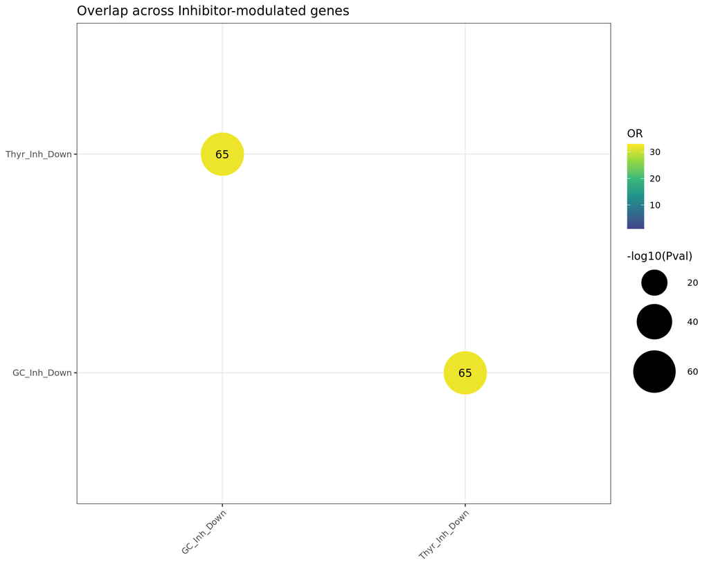

```r
Dot <- ggplot(ResSel, aes(DEGs, KBase, label=Numbers)) +
  geom_point(aes(size=-log10(Pval), col=OR)) +
  geom_text() +
  scale_size_continuous(range=c(2, 20), limits=c(2, round(-log10(min(ResSel$Pval)) + 0.5))) +
  scale_color_viridis_c(limits=c(1, round(max(ResSel$OR)+1)), begin=0.2) + xlab('') + ylab('') +
  theme_bw() +
  theme(axis.line = element_blank(), axis.title = element_blank(),
        axis.text.x = element_text(angle = 45, hjust = 1)) +
    ggtitle('Overlap across Inhibitor-modulated genes')

Dot
```

```r
ggsave(Dot, filename=paste0(OutputFolder, 'DotPlot_Inhibitor.pdf'), width=8, height=8)
```

## 4.3 Visualize overlap results selectively for retinoic, liverX, thyroid

### Selection

```r
Path <- c('Thyr_Inh_Up', 'Thyr_Inh_Down', 'Ret_Inh_Up', 'Ret_Inh_Down', 'LivX_Inh_Up', 'LivX_Inh_Down')
ResPath <- ResSel[ResSel$DEGs %in% Path & ResSel$KBase %in% Path, ]

ResPath
## [1] DEGs    KBase   OR      Pval    Numbers
## <0 rows> (or 0-length row.names)
```

No significant overlap found.

# 5. Comparison across pathways: up-regulated genes

## 5.1 Perform the overlap

```r
DEGs_UpReg <- list(

  Thyr_Ag= row.names(DEA$Thyr$Agonist$DEGs[DEA$Thyr$Agonist$DEGs$log2FoldChange > 0, ]),
  Thyr_Inh= row.names(DEA$Thyr$Inhibitor$DEGs[DEA$Thyr$Inhibitor$DEGs$log2FoldChange > 0, ]),

  Ret_Ag= row.names(DEA$Ret$Agonist$DEGs[DEA$Ret$Agonist$DEGs$log2FoldChange > 0, ]),
  Ret_Inh= row.names(DEA$Ret$Inhibitor$DEGs[DEA$Ret$Inhibitor$DEGs$log2FoldChange > 0, ]),

  Estr_Ag= row.names(DEA$Estr$Agonist$DEGs[DEA$Estr$Agonist$DEGs$log2FoldChange > 0, ]),

  Andr_Ag= row.names(DEA$Andr$Agonist$DEGs[DEA$Andr$Agonist$DEGs$log2FoldChange > 0, ]),
  Andr_Inh= row.names(DEA$Andr$Inhibitor$DEGs[DEA$Andr$Inhibitor$DEGs$log2FoldChange > 0, ]),

  GC_Ag= row.names(DEA$GC$Agonist$DEGs[DEA$GC$Agonist$DEGs$log2FoldChange > 0, ]),
  GC_Inh= row.names(DEA$GC$Inhibitor$DEGs[DEA$GC$Inhibitor$DEGs$log2FoldChange > 0, ]),

  LivX_Ag= row.names(DEA$LivX$Agonist$DEGs[DEA$LivX$Agonist$DEGs$log2FoldChange > 0, ]),
  LivX_Inh= row.names(DEA$LivX$Inhibitor$DEGs[DEA$LivX$Inhibitor$DEGs$log2FoldChange > 0, ]),

  AhHyd_Ag= row.names(DEA$AhHyd$Agonist$DEGs[DEA$AhHyd$Agonist$DEGs$log2FoldChange > 0, ]),
  AhHyd_Inh= row.names(DEA$AhHyd$Inhibitor$DEGs[DEA$AhHyd$Inhibitor$DEGs$log2FoldChange > 0, ])

            )
```

```r
Universe <- row.names(DEA$Ret$Inhibitor$Res) %>% unique()
length(Universe)
## [1] 14850
```

```r
OvObj <- newGOM(DEGs_UpReg, DEGs_UpReg, genome.size=length(Universe))
print(OvObj)
## A GeneOverlapMatrix object:
## ###### Intersection ######
##           Thyr_Ag Thyr_Inh Ret_Ag Ret_Inh Estr_Ag Andr_Ag Andr_Inh GC_Ag GC_Inh
## Thyr_Ag       142       14     81       0      84       5        0     0      0
## Thyr_Inh       14      270     80       0      39       2        0     0     19
## Ret_Ag         81       80   1677       0     462       4        0     1     13
## Ret_Inh         0        0      0       1       0       0        0     0      0
## Estr_Ag        84       39    462       0     905       4        0     1      2
## Andr_Ag         5        2      4       0       4       6        0     0      0
## Andr_Inh        0        0      0       0       0       0        1     0      0
## GC_Ag           0        0      1       0       1       0        0     6      0
## GC_Inh          0       19     13       0       2       0        0     0     48
## LivX_Ag        56       64    367       0     219       5        0     0      5
## LivX_Inh        0        0      0       0       0       0        0     0      0
## AhHyd_Ag        0        0      0       0       0       0        0     0      0
## AhHyd_Inh       4        5     10       1       8       2        0     0      1
##           LivX_Ag LivX_Inh AhHyd_Ag AhHyd_Inh
## Thyr_Ag        56        0        0         4
## Thyr_Inh       64        0        0         5
## Ret_Ag        367        0        0        10
## Ret_Inh         0        0        0         1
## Estr_Ag       219        0        0         8
## Andr_Ag         5        0        0         2
## Andr_Inh        0        0        0         0
## GC_Ag           0        0        0         0
## GC_Inh          5        0        0         1
## LivX_Ag       450        0        0        10
## LivX_Inh        0        4        0         0
## AhHyd_Ag        0        0        3         0
## AhHyd_Inh      10        0        0        13
## ###### P-value ######
##                Thyr_Ag     Thyr_Inh        Ret_Ag      Ret_Inh       Estr_Ag
## Thyr_Ag   0.000000e+00 3.098622e-07  3.063677e-40 1.000000e+00  2.641447e-65
## Thyr_Inh  3.098622e-07 0.000000e+00  1.283202e-16 1.000000e+00  4.298987e-07
## Ret_Ag    3.063677e-40 1.283202e-16  0.000000e+00 1.000000e+00 3.762356e-212
## Ret_Inh   1.000000e+00 1.000000e+00  1.000000e+00 6.734007e-05  1.000000e+00
## Estr_Ag   2.641447e-65 4.298987e-07 3.762356e-212 1.000000e+00  0.000000e+00
## Andr_Ag   4.435963e-10 4.707606e-03  2.013961e-03 1.000000e+00  1.861609e-04
## Andr_Inh  1.000000e+00 1.000000e+00  1.000000e+00 1.000000e+00  1.000000e+00
## GC_Ag     1.000000e+00 1.000000e+00  5.128154e-01 1.000000e+00  3.143162e-01
## GC_Inh    1.000000e+00 3.270578e-21  2.001744e-03 1.000000e+00  7.992924e-01
## LivX_Ag   4.556114e-48 2.868436e-39 1.730574e-276 1.000000e+00 1.688829e-149
## LivX_Inh  1.000000e+00 1.000000e+00  1.000000e+00 1.000000e+00  1.000000e+00
## AhHyd_Ag  1.000000e+00 1.000000e+00  1.000000e+00 1.000000e+00  1.000000e+00
## AhHyd_Inh 5.358972e-06 2.187153e-06  6.821193e-08 8.754209e-04  1.805333e-07
##                Andr_Ag     Andr_Inh        GC_Ag        GC_Inh       LivX_Ag
## Thyr_Ag   4.435963e-10 1.000000e+00 1.000000e+00  1.000000e+00  4.556114e-48
## Thyr_Inh  4.707606e-03 1.000000e+00 1.000000e+00  3.270578e-21  2.868436e-39
## Ret_Ag    2.013961e-03 1.000000e+00 5.128154e-01  2.001744e-03 1.730574e-276
## Ret_Inh   1.000000e+00 1.000000e+00 1.000000e+00  1.000000e+00  1.000000e+00
## Estr_Ag   1.861609e-04 1.000000e+00 3.143162e-01  7.992924e-01 1.688829e-149
## Andr_Ag   6.720669e-23 1.000000e+00 1.000000e+00  1.000000e+00  1.462864e-07
## Andr_Inh  1.000000e+00 6.734007e-05 1.000000e+00  1.000000e+00  1.000000e+00
## GC_Ag     1.000000e+00 1.000000e+00 6.720669e-23  1.000000e+00  1.000000e+00
## GC_Inh    1.000000e+00 1.000000e+00 1.000000e+00 7.657078e-140  1.467358e-02
## LivX_Ag   1.462864e-07 1.000000e+00 1.000000e+00  1.467358e-02  0.000000e+00
## LivX_Inh  1.000000e+00 1.000000e+00 1.000000e+00  1.000000e+00  1.000000e+00
## AhHyd_Ag  1.000000e+00 1.000000e+00 1.000000e+00  1.000000e+00  1.000000e+00
## AhHyd_Inh 1.059093e-05 1.000000e+00 1.000000e+00  4.123119e-02  1.560309e-13
##               LivX_Inh     AhHyd_Ag    AhHyd_Inh
## Thyr_Ag   1.000000e+00 1.000000e+00 5.358972e-06
## Thyr_Inh  1.000000e+00 1.000000e+00 2.187153e-06
## Ret_Ag    1.000000e+00 1.000000e+00 6.821193e-08
## Ret_Inh   1.000000e+00 1.000000e+00 8.754209e-04
## Estr_Ag   1.000000e+00 1.000000e+00 1.805333e-07
## Andr_Ag   1.000000e+00 1.000000e+00 1.059093e-05
## Andr_Inh  1.000000e+00 1.000000e+00 1.000000e+00
## GC_Ag     1.000000e+00 1.000000e+00 1.000000e+00
## GC_Inh    1.000000e+00 1.000000e+00 4.123119e-02
## LivX_Ag   1.000000e+00 1.000000e+00 1.560309e-13
## LivX_Inh  4.937202e-16 1.000000e+00 1.000000e+00
## AhHyd_Ag  1.000000e+00 1.832566e-12 1.000000e+00
## AhHyd_Inh 1.000000e+00 1.000000e+00 3.665373e-45
## ###### Odds Ratio ######
##             Thyr_Ag  Thyr_Inh    Ret_Ag Ret_Inh    Estr_Ag   Andr_Ag Andr_Inh
## Thyr_Ag         Inf  6.172620 10.905715       0 24.4691632 533.98796        0
## Thyr_Inh    6.17262       Inf  3.422680       0  2.6732328  27.14732        0
## Ret_Ag     10.90572  3.422680       Inf       0 10.9234073  15.73955        0
## Ret_Inh     0.00000  0.000000  0.000000     Inf  0.0000000   0.00000        0
## Estr_Ag    24.46916  2.673233 10.923407       0        Inf  30.94356        0
## Andr_Ag   533.98796 27.147324 15.739550       0 30.9435619       Inf        0
## Andr_Inh    0.00000  0.000000  0.000000       0  0.0000000   0.00000      Inf
## GC_Ag       0.00000  0.000000  1.571291       0  3.0836743   0.00000        0
## GC_Inh      0.00000 37.929142  2.932290       0  0.6692207   0.00000        0
## LivX_Ag    23.63592 11.422165 44.201409       0 18.9463251 161.91079        0
## LivX_Inh    0.00000  0.000000  0.000000       0  0.0000000   0.00000        0
## AhHyd_Ag    0.00000  0.000000  0.000000       0  0.0000000   0.00000        0
## AhHyd_Inh  47.22207 34.320883 26.322839     Inf 24.8479088 652.32891        0
##              GC_Ag     GC_Inh    LivX_Ag LivX_Inh AhHyd_Ag AhHyd_Inh
## Thyr_Ag   0.000000  0.0000000  23.635922        0        0  47.22207
## Thyr_Inh  0.000000 37.9291424  11.422165        0        0  34.32088
## Ret_Ag    1.571291  2.9322904  44.201409        0        0  26.32284
## Ret_Inh   0.000000  0.0000000   0.000000        0        0       Inf
## Estr_Ag   3.083674  0.6692207  18.946325        0        0  24.84791
## Andr_Ag   0.000000  0.0000000 161.910790        0        0 652.32891
## Andr_Inh  0.000000  0.0000000   0.000000        0        0   0.00000
## GC_Ag          Inf  0.0000000   0.000000        0        0   0.00000
## GC_Inh    0.000000        Inf   3.751219        0        0  26.19770
## LivX_Ag   0.000000  3.7512195        Inf        0        0 108.70227
## LivX_Inh  0.000000  0.0000000   0.000000      Inf        0   0.00000
## AhHyd_Ag  0.000000  0.0000000   0.000000        0      Inf   0.00000
## AhHyd_Inh 0.000000 26.1977029 108.702275        0        0       Inf
## ###### Jaccard Index ######
##              Thyr_Ag   Thyr_Inh       Ret_Ag    Ret_Inh     Estr_Ag     Andr_Ag
## Thyr_Ag   1.00000000 0.03517588 0.0466052934 0.00000000 0.087227414 0.034965035
## Thyr_Inh  0.03517588 1.00000000 0.0428494912 0.00000000 0.034330986 0.007299270
## Ret_Ag    0.04660529 0.04284949 1.0000000000 0.00000000 0.217924528 0.002382370
## Ret_Inh   0.00000000 0.00000000 0.0000000000 1.00000000 0.000000000 0.000000000
## Estr_Ag   0.08722741 0.03433099 0.2179245283 0.00000000 1.000000000 0.004410143
## Andr_Ag   0.03496503 0.00729927 0.0023823705 0.00000000 0.004410143 1.000000000
## Andr_Inh  0.00000000 0.00000000 0.0000000000 0.00000000 0.000000000 0.000000000
## GC_Ag     0.00000000 0.00000000 0.0005945303 0.00000000 0.001098901 0.000000000
## GC_Inh    0.00000000 0.06354515 0.0075934579 0.00000000 0.002103049 0.000000000
## LivX_Ag   0.10447761 0.09756098 0.2085227273 0.00000000 0.192781690 0.011086475
## LivX_Inh  0.00000000 0.00000000 0.0000000000 0.00000000 0.000000000 0.000000000
## AhHyd_Ag  0.00000000 0.00000000 0.0000000000 0.00000000 0.000000000 0.000000000
## AhHyd_Inh 0.02649007 0.01798561 0.0059523810 0.07692308 0.008791209 0.117647059
##           Andr_Inh        GC_Ag      GC_Inh    LivX_Ag LivX_Inh AhHyd_Ag
## Thyr_Ag          0 0.0000000000 0.000000000 0.10447761        0        0
## Thyr_Inh         0 0.0000000000 0.063545151 0.09756098        0        0
## Ret_Ag           0 0.0005945303 0.007593458 0.20852273        0        0
## Ret_Inh          0 0.0000000000 0.000000000 0.00000000        0        0
## Estr_Ag          0 0.0010989011 0.002103049 0.19278169        0        0
## Andr_Ag          0 0.0000000000 0.000000000 0.01108647        0        0
## Andr_Inh         1 0.0000000000 0.000000000 0.00000000        0        0
## GC_Ag            0 1.0000000000 0.000000000 0.00000000        0        0
## GC_Inh           0 0.0000000000 1.000000000 0.01014199        0        0
## LivX_Ag          0 0.0000000000 0.010141988 1.00000000        0        0
## LivX_Inh         0 0.0000000000 0.000000000 0.00000000        1        0
## AhHyd_Ag         0 0.0000000000 0.000000000 0.00000000        0        1
## AhHyd_Inh        0 0.0000000000 0.016666667 0.02207506        0        0
##             AhHyd_Inh
## Thyr_Ag   0.026490066
## Thyr_Inh  0.017985612
## Ret_Ag    0.005952381
## Ret_Inh   0.076923077
## Estr_Ag   0.008791209
## Andr_Ag   0.117647059
## Andr_Inh  0.000000000
## GC_Ag     0.000000000
## GC_Inh    0.016666667
## LivX_Ag   0.022075055
## LivX_Inh  0.000000000
## AhHyd_Ag  0.000000000
## AhHyd_Inh 1.000000000
```

```r
getMatrix(OvObj, name='intersection')
##           Thyr_Ag Thyr_Inh Ret_Ag Ret_Inh Estr_Ag Andr_Ag Andr_Inh GC_Ag GC_Inh
## Thyr_Ag       142       14     81       0      84       5        0     0      0
## Thyr_Inh       14      270     80       0      39       2        0     0     19
## Ret_Ag         81       80   1677       0     462       4        0     1     13
## Ret_Inh         0        0      0       1       0       0        0     0      0
## Estr_Ag        84       39    462       0     905       4        0     1      2
## Andr_Ag         5        2      4       0       4       6        0     0      0
## Andr_Inh        0        0      0       0       0       0        1     0      0
## GC_Ag           0        0      1       0       1       0        0     6      0
## GC_Inh          0       19     13       0       2       0        0     0     48
## LivX_Ag        56       64    367       0     219       5        0     0      5
## LivX_Inh        0        0      0       0       0       0        0     0      0
## AhHyd_Ag        0        0      0       0       0       0        0     0      0
## AhHyd_Inh       4        5     10       1       8       2        0     0      1
##           LivX_Ag LivX_Inh AhHyd_Ag AhHyd_Inh
## Thyr_Ag        56        0        0         4
## Thyr_Inh       64        0        0         5
## Ret_Ag        367        0        0        10
## Ret_Inh         0        0        0         1
## Estr_Ag       219        0        0         8
## Andr_Ag         5        0        0         2
## Andr_Inh        0        0        0         0
## GC_Ag           0        0        0         0
## GC_Inh          5        0        0         1
## LivX_Ag       450        0        0        10
## LivX_Inh        0        4        0         0
## AhHyd_Ag        0        0        3         0
## AhHyd_Inh      10        0        0        13
```

```r
getMatrix(OvObj, name='pval')
##                Thyr_Ag     Thyr_Inh        Ret_Ag      Ret_Inh       Estr_Ag
## Thyr_Ag   0.000000e+00 3.098622e-07  3.063677e-40 1.000000e+00  2.641447e-65
## Thyr_Inh  3.098622e-07 0.000000e+00  1.283202e-16 1.000000e+00  4.298987e-07
## Ret_Ag    3.063677e-40 1.283202e-16  0.000000e+00 1.000000e+00 3.762356e-212
## Ret_Inh   1.000000e+00 1.000000e+00  1.000000e+00 6.734007e-05  1.000000e+00
## Estr_Ag   2.641447e-65 4.298987e-07 3.762356e-212 1.000000e+00  0.000000e+00
## Andr_Ag   4.435963e-10 4.707606e-03  2.013961e-03 1.000000e+00  1.861609e-04
## Andr_Inh  1.000000e+00 1.000000e+00  1.000000e+00 1.000000e+00  1.000000e+00
## GC_Ag     1.000000e+00 1.000000e+00  5.128154e-01 1.000000e+00  3.143162e-01
## GC_Inh    1.000000e+00 3.270578e-21  2.001744e-03 1.000000e+00  7.992924e-01
## LivX_Ag   4.556114e-48 2.868436e-39 1.730574e-276 1.000000e+00 1.688829e-149
## LivX_Inh  1.000000e+00 1.000000e+00  1.000000e+00 1.000000e+00  1.000000e+00
## AhHyd_Ag  1.000000e+00 1.000000e+00  1.000000e+00 1.000000e+00  1.000000e+00
## AhHyd_Inh 5.358972e-06 2.187153e-06  6.821193e-08 8.754209e-04  1.805333e-07
##                Andr_Ag     Andr_Inh        GC_Ag        GC_Inh       LivX_Ag
## Thyr_Ag   4.435963e-10 1.000000e+00 1.000000e+00  1.000000e+00  4.556114e-48
## Thyr_Inh  4.707606e-03 1.000000e+00 1.000000e+00  3.270578e-21  2.868436e-39
## Ret_Ag    2.013961e-03 1.000000e+00 5.128154e-01  2.001744e-03 1.730574e-276
## Ret_Inh   1.000000e+00 1.000000e+00 1.000000e+00  1.000000e+00  1.000000e+00
## Estr_Ag   1.861609e-04 1.000000e+00 3.143162e-01  7.992924e-01 1.688829e-149
## Andr_Ag   6.720669e-23 1.000000e+00 1.000000e+00  1.000000e+00  1.462864e-07
## Andr_Inh  1.000000e+00 6.734007e-05 1.000000e+00  1.000000e+00  1.000000e+00
## GC_Ag     1.000000e+00 1.000000e+00 6.720669e-23  1.000000e+00  1.000000e+00
## GC_Inh    1.000000e+00 1.000000e+00 1.000000e+00 7.657078e-140  1.467358e-02
## LivX_Ag   1.462864e-07 1.000000e+00 1.000000e+00  1.467358e-02  0.000000e+00
## LivX_Inh  1.000000e+00 1.000000e+00 1.000000e+00  1.000000e+00  1.000000e+00
## AhHyd_Ag  1.000000e+00 1.000000e+00 1.000000e+00  1.000000e+00  1.000000e+00
## AhHyd_Inh 1.059093e-05 1.000000e+00 1.000000e+00  4.123119e-02  1.560309e-13
##               LivX_Inh     AhHyd_Ag    AhHyd_Inh
## Thyr_Ag   1.000000e+00 1.000000e+00 5.358972e-06
## Thyr_Inh  1.000000e+00 1.000000e+00 2.187153e-06
## Ret_Ag    1.000000e+00 1.000000e+00 6.821193e-08
## Ret_Inh   1.000000e+00 1.000000e+00 8.754209e-04
## Estr_Ag   1.000000e+00 1.000000e+00 1.805333e-07
## Andr_Ag   1.000000e+00 1.000000e+00 1.059093e-05
## Andr_Inh  1.000000e+00 1.000000e+00 1.000000e+00
## GC_Ag     1.000000e+00 1.000000e+00 1.000000e+00
## GC_Inh    1.000000e+00 1.000000e+00 4.123119e-02
## LivX_Ag   1.000000e+00 1.000000e+00 1.560309e-13
## LivX_Inh  4.937202e-16 1.000000e+00 1.000000e+00
## AhHyd_Ag  1.000000e+00 1.832566e-12 1.000000e+00
## AhHyd_Inh 1.000000e+00 1.000000e+00 3.665373e-45
```

```r
getMatrix(OvObj, name='odds.ratio')
##             Thyr_Ag  Thyr_Inh    Ret_Ag Ret_Inh    Estr_Ag   Andr_Ag Andr_Inh
## Thyr_Ag         Inf  6.172620 10.905715       0 24.4691632 533.98796        0
## Thyr_Inh    6.17262       Inf  3.422680       0  2.6732328  27.14732        0
## Ret_Ag     10.90572  3.422680       Inf       0 10.9234073  15.73955        0
## Ret_Inh     0.00000  0.000000  0.000000     Inf  0.0000000   0.00000        0
## Estr_Ag    24.46916  2.673233 10.923407       0        Inf  30.94356        0
## Andr_Ag   533.98796 27.147324 15.739550       0 30.9435619       Inf        0
## Andr_Inh    0.00000  0.000000  0.000000       0  0.0000000   0.00000      Inf
## GC_Ag       0.00000  0.000000  1.571291       0  3.0836743   0.00000        0
## GC_Inh      0.00000 37.929142  2.932290       0  0.6692207   0.00000        0
## LivX_Ag    23.63592 11.422165 44.201409       0 18.9463251 161.91079        0
## LivX_Inh    0.00000  0.000000  0.000000       0  0.0000000   0.00000        0
## AhHyd_Ag    0.00000  0.000000  0.000000       0  0.0000000   0.00000        0
## AhHyd_Inh  47.22207 34.320883 26.322839     Inf 24.8479088 652.32891        0
##              GC_Ag     GC_Inh    LivX_Ag LivX_Inh AhHyd_Ag AhHyd_Inh
## Thyr_Ag   0.000000  0.0000000  23.635922        0        0  47.22207
## Thyr_Inh  0.000000 37.9291424  11.422165        0        0  34.32088
## Ret_Ag    1.571291  2.9322904  44.201409        0        0  26.32284
## Ret_Inh   0.000000  0.0000000   0.000000        0        0       Inf
## Estr_Ag   3.083674  0.6692207  18.946325        0        0  24.84791
## Andr_Ag   0.000000  0.0000000 161.910790        0        0 652.32891
## Andr_Inh  0.000000  0.0000000   0.000000        0        0   0.00000
## GC_Ag          Inf  0.0000000   0.000000        0        0   0.00000
## GC_Inh    0.000000        Inf   3.751219        0        0  26.19770
## LivX_Ag   0.000000  3.7512195        Inf        0        0 108.70227
## LivX_Inh  0.000000  0.0000000   0.000000      Inf        0   0.00000
## AhHyd_Ag  0.000000  0.0000000   0.000000        0      Inf   0.00000
## AhHyd_Inh 0.000000 26.1977029 108.702275        0        0       Inf
```

## 5.2 Visualize overlap results

### DotPlot: data preparation

```r
OR <- data.frame(getMatrix(OvObj, name='odds.ratio'))
OR$DEGs <- row.names(OR)
OR <- gather(OR, 'KBase', 'OR', -DEGs)
PVAL <- data.frame(getMatrix(OvObj, name='pval'))
PVAL$DEGs <- row.names(PVAL)
PVAL <- gather(PVAL, 'KBase', 'PVal', -DEGs)
NUM <- data.frame(getMatrix(OvObj, name='intersection'))
NUM$DEGs <- row.names(NUM)
NUM <- gather(NUM, 'KBase', 'Numbers', -DEGs)
if(! identical(OR$DEGs, PVAL$DEGs)){
  stop('Inconsistecy')
}
if(! identical(OR$DEGs, NUM$DEGs)){
  stop('Inconsistecy')
}
if(! identical(OR$KBase, NUM$KBase)){
  stop('Inconsistecy')
}
if(! identical(OR$KBase, NUM$KBase)){
  stop('Inconsistecy')
}
Res <- mutate(OR, Pval=PVAL$PVal) %>% mutate(Numbers=NUM$Numbers)
Res
##          DEGs     KBase          OR          Pval Numbers
## 1     Thyr_Ag   Thyr_Ag         Inf  0.000000e+00     142
## 2    Thyr_Inh   Thyr_Ag   6.1726199  3.098622e-07      14
## 3      Ret_Ag   Thyr_Ag  10.9057151  3.063677e-40      81
## 4     Ret_Inh   Thyr_Ag   0.0000000  1.000000e+00       0
## 5     Estr_Ag   Thyr_Ag  24.4691632  2.641447e-65      84
## 6     Andr_Ag   Thyr_Ag 533.9879643  4.435963e-10       5
## 7    Andr_Inh   Thyr_Ag   0.0000000  1.000000e+00       0
## 8       GC_Ag   Thyr_Ag   0.0000000  1.000000e+00       0
## 9      GC_Inh   Thyr_Ag   0.0000000  1.000000e+00       0
## 10    LivX_Ag   Thyr_Ag  23.6359221  4.556114e-48      56
## 11   LivX_Inh   Thyr_Ag   0.0000000  1.000000e+00       0
## 12   AhHyd_Ag   Thyr_Ag   0.0000000  1.000000e+00       0
## 13  AhHyd_Inh   Thyr_Ag  47.2220668  5.358972e-06       4
## 14    Thyr_Ag  Thyr_Inh   6.1726199  3.098622e-07      14
## 15   Thyr_Inh  Thyr_Inh         Inf  0.000000e+00     270
## 16     Ret_Ag  Thyr_Inh   3.4226795  1.283202e-16      80
## 17    Ret_Inh  Thyr_Inh   0.0000000  1.000000e+00       0
## 18    Estr_Ag  Thyr_Inh   2.6732328  4.298987e-07      39
## 19    Andr_Ag  Thyr_Inh  27.1473236  4.707606e-03       2
## 20   Andr_Inh  Thyr_Inh   0.0000000  1.000000e+00       0
## 21      GC_Ag  Thyr_Inh   0.0000000  1.000000e+00       0
## 22     GC_Inh  Thyr_Inh  37.9291424  3.270578e-21      19
## 23    LivX_Ag  Thyr_Inh  11.4221654  2.868436e-39      64
## 24   LivX_Inh  Thyr_Inh   0.0000000  1.000000e+00       0
## 25   AhHyd_Ag  Thyr_Inh   0.0000000  1.000000e+00       0
## 26  AhHyd_Inh  Thyr_Inh  34.3208830  2.187153e-06       5
## 27    Thyr_Ag    Ret_Ag  10.9057151  3.063677e-40      81
## 28   Thyr_Inh    Ret_Ag   3.4226795  1.283202e-16      80
## 29     Ret_Ag    Ret_Ag         Inf  0.000000e+00    1677
## 30    Ret_Inh    Ret_Ag   0.0000000  1.000000e+00       0
## 31    Estr_Ag    Ret_Ag  10.9234073 3.762356e-212     462
## 32    Andr_Ag    Ret_Ag  15.7395497  2.013961e-03       4
## 33   Andr_Inh    Ret_Ag   0.0000000  1.000000e+00       0
## 34      GC_Ag    Ret_Ag   1.5712909  5.128154e-01       1
## 35     GC_Inh    Ret_Ag   2.9322904  2.001744e-03      13
## 36    LivX_Ag    Ret_Ag  44.2014086 1.730574e-276     367
## 37   LivX_Inh    Ret_Ag   0.0000000  1.000000e+00       0
## 38   AhHyd_Ag    Ret_Ag   0.0000000  1.000000e+00       0
## 39  AhHyd_Inh    Ret_Ag  26.3228390  6.821193e-08      10
## 40    Thyr_Ag   Ret_Inh   0.0000000  1.000000e+00       0
## 41   Thyr_Inh   Ret_Inh   0.0000000  1.000000e+00       0
## 42     Ret_Ag   Ret_Inh   0.0000000  1.000000e+00       0
## 43    Ret_Inh   Ret_Inh         Inf  6.734007e-05       1
## 44    Estr_Ag   Ret_Inh   0.0000000  1.000000e+00       0
## 45    Andr_Ag   Ret_Inh   0.0000000  1.000000e+00       0
## 46   Andr_Inh   Ret_Inh   0.0000000  1.000000e+00       0
## 47      GC_Ag   Ret_Inh   0.0000000  1.000000e+00       0
## 48     GC_Inh   Ret_Inh   0.0000000  1.000000e+00       0
## 49    LivX_Ag   Ret_Inh   0.0000000  1.000000e+00       0
## 50   LivX_Inh   Ret_Inh   0.0000000  1.000000e+00       0
## 51   AhHyd_Ag   Ret_Inh   0.0000000  1.000000e+00       0
## 52  AhHyd_Inh   Ret_Inh         Inf  8.754209e-04       1
## 53    Thyr_Ag   Estr_Ag  24.4691632  2.641447e-65      84
## 54   Thyr_Inh   Estr_Ag   2.6732328  4.298987e-07      39
## 55     Ret_Ag   Estr_Ag  10.9234073 3.762356e-212     462
## 56    Ret_Inh   Estr_Ag   0.0000000  1.000000e+00       0
## 57    Estr_Ag   Estr_Ag         Inf  0.000000e+00     905
## 58    Andr_Ag   Estr_Ag  30.9435619  1.861609e-04       4
## 59   Andr_Inh   Estr_Ag   0.0000000  1.000000e+00       0
## 60      GC_Ag   Estr_Ag   3.0836743  3.143162e-01       1
## 61     GC_Inh   Estr_Ag   0.6692207  7.992924e-01       2
## 62    LivX_Ag   Estr_Ag  18.9463251 1.688829e-149     219
## 63   LivX_Inh   Estr_Ag   0.0000000  1.000000e+00       0
## 64   AhHyd_Ag   Estr_Ag   0.0000000  1.000000e+00       0
## 65  AhHyd_Inh   Estr_Ag  24.8479088  1.805333e-07       8
## 66    Thyr_Ag   Andr_Ag 533.9879643  4.435963e-10       5
## 67   Thyr_Inh   Andr_Ag  27.1473236  4.707606e-03       2
## 68     Ret_Ag   Andr_Ag  15.7395497  2.013961e-03       4
## 69    Ret_Inh   Andr_Ag   0.0000000  1.000000e+00       0
## 70    Estr_Ag   Andr_Ag  30.9435619  1.861609e-04       4
## 71    Andr_Ag   Andr_Ag         Inf  6.720669e-23       6
## 72   Andr_Inh   Andr_Ag   0.0000000  1.000000e+00       0
## 73      GC_Ag   Andr_Ag   0.0000000  1.000000e+00       0
## 74     GC_Inh   Andr_Ag   0.0000000  1.000000e+00       0
## 75    LivX_Ag   Andr_Ag 161.9107898  1.462864e-07       5
## 76   LivX_Inh   Andr_Ag   0.0000000  1.000000e+00       0
## 77   AhHyd_Ag   Andr_Ag   0.0000000  1.000000e+00       0
## 78  AhHyd_Inh   Andr_Ag 652.3289113  1.059093e-05       2
## 79    Thyr_Ag  Andr_Inh   0.0000000  1.000000e+00       0
## 80   Thyr_Inh  Andr_Inh   0.0000000  1.000000e+00       0
## 81     Ret_Ag  Andr_Inh   0.0000000  1.000000e+00       0
## 82    Ret_Inh  Andr_Inh   0.0000000  1.000000e+00       0
## 83    Estr_Ag  Andr_Inh   0.0000000  1.000000e+00       0
## 84    Andr_Ag  Andr_Inh   0.0000000  1.000000e+00       0
## 85   Andr_Inh  Andr_Inh         Inf  6.734007e-05       1
## 86      GC_Ag  Andr_Inh   0.0000000  1.000000e+00       0
## 87     GC_Inh  Andr_Inh   0.0000000  1.000000e+00       0
## 88    LivX_Ag  Andr_Inh   0.0000000  1.000000e+00       0
## 89   LivX_Inh  Andr_Inh   0.0000000  1.000000e+00       0
## 90   AhHyd_Ag  Andr_Inh   0.0000000  1.000000e+00       0
## 91  AhHyd_Inh  Andr_Inh   0.0000000  1.000000e+00       0
## 92    Thyr_Ag     GC_Ag   0.0000000  1.000000e+00       0
## 93   Thyr_Inh     GC_Ag   0.0000000  1.000000e+00       0
## 94     Ret_Ag     GC_Ag   1.5712909  5.128154e-01       1
## 95    Ret_Inh     GC_Ag   0.0000000  1.000000e+00       0
## 96    Estr_Ag     GC_Ag   3.0836743  3.143162e-01       1
## 97    Andr_Ag     GC_Ag   0.0000000  1.000000e+00       0
## 98   Andr_Inh     GC_Ag   0.0000000  1.000000e+00       0
## 99      GC_Ag     GC_Ag         Inf  6.720669e-23       6
## 100    GC_Inh     GC_Ag   0.0000000  1.000000e+00       0
## 101   LivX_Ag     GC_Ag   0.0000000  1.000000e+00       0
## 102  LivX_Inh     GC_Ag   0.0000000  1.000000e+00       0
## 103  AhHyd_Ag     GC_Ag   0.0000000  1.000000e+00       0
## 104 AhHyd_Inh     GC_Ag   0.0000000  1.000000e+00       0
## 105   Thyr_Ag    GC_Inh   0.0000000  1.000000e+00       0
## 106  Thyr_Inh    GC_Inh  37.9291424  3.270578e-21      19
## 107    Ret_Ag    GC_Inh   2.9322904  2.001744e-03      13
## 108   Ret_Inh    GC_Inh   0.0000000  1.000000e+00       0
## 109   Estr_Ag    GC_Inh   0.6692207  7.992924e-01       2
## 110   Andr_Ag    GC_Inh   0.0000000  1.000000e+00       0
## 111  Andr_Inh    GC_Inh   0.0000000  1.000000e+00       0
## 112     GC_Ag    GC_Inh   0.0000000  1.000000e+00       0
## 113    GC_Inh    GC_Inh         Inf 7.657078e-140      48
## 114   LivX_Ag    GC_Inh   3.7512195  1.467358e-02       5
## 115  LivX_Inh    GC_Inh   0.0000000  1.000000e+00       0
## 116  AhHyd_Ag    GC_Inh   0.0000000  1.000000e+00       0
## 117 AhHyd_Inh    GC_Inh  26.1977029  4.123119e-02       1
## 118   Thyr_Ag   LivX_Ag  23.6359221  4.556114e-48      56
## 119  Thyr_Inh   LivX_Ag  11.4221654  2.868436e-39      64
## 120    Ret_Ag   LivX_Ag  44.2014086 1.730574e-276     367
## 121   Ret_Inh   LivX_Ag   0.0000000  1.000000e+00       0
## 122   Estr_Ag   LivX_Ag  18.9463251 1.688829e-149     219
## 123   Andr_Ag   LivX_Ag 161.9107898  1.462864e-07       5
## 124  Andr_Inh   LivX_Ag   0.0000000  1.000000e+00       0
## 125     GC_Ag   LivX_Ag   0.0000000  1.000000e+00       0
## 126    GC_Inh   LivX_Ag   3.7512195  1.467358e-02       5
## 127   LivX_Ag   LivX_Ag         Inf  0.000000e+00     450
## 128  LivX_Inh   LivX_Ag   0.0000000  1.000000e+00       0
## 129  AhHyd_Ag   LivX_Ag   0.0000000  1.000000e+00       0
## 130 AhHyd_Inh   LivX_Ag 108.7022748  1.560309e-13      10
## 131   Thyr_Ag  LivX_Inh   0.0000000  1.000000e+00       0
## 132  Thyr_Inh  LivX_Inh   0.0000000  1.000000e+00       0
## 133    Ret_Ag  LivX_Inh   0.0000000  1.000000e+00       0
## 134   Ret_Inh  LivX_Inh   0.0000000  1.000000e+00       0
## 135   Estr_Ag  LivX_Inh   0.0000000  1.000000e+00       0
## 136   Andr_Ag  LivX_Inh   0.0000000  1.000000e+00       0
## 137  Andr_Inh  LivX_Inh   0.0000000  1.000000e+00       0
## 138     GC_Ag  LivX_Inh   0.0000000  1.000000e+00       0
## 139    GC_Inh  LivX_Inh   0.0000000  1.000000e+00       0
## 140   LivX_Ag  LivX_Inh   0.0000000  1.000000e+00       0
## 141  LivX_Inh  LivX_Inh         Inf  4.937202e-16       4
## 142  AhHyd_Ag  LivX_Inh   0.0000000  1.000000e+00       0
## 143 AhHyd_Inh  LivX_Inh   0.0000000  1.000000e+00       0
## 144   Thyr_Ag  AhHyd_Ag   0.0000000  1.000000e+00       0
## 145  Thyr_Inh  AhHyd_Ag   0.0000000  1.000000e+00       0
## 146    Ret_Ag  AhHyd_Ag   0.0000000  1.000000e+00       0
## 147   Ret_Inh  AhHyd_Ag   0.0000000  1.000000e+00       0
## 148   Estr_Ag  AhHyd_Ag   0.0000000  1.000000e+00       0
## 149   Andr_Ag  AhHyd_Ag   0.0000000  1.000000e+00       0
## 150  Andr_Inh  AhHyd_Ag   0.0000000  1.000000e+00       0
## 151     GC_Ag  AhHyd_Ag   0.0000000  1.000000e+00       0
## 152    GC_Inh  AhHyd_Ag   0.0000000  1.000000e+00       0
## 153   LivX_Ag  AhHyd_Ag   0.0000000  1.000000e+00       0
## 154  LivX_Inh  AhHyd_Ag   0.0000000  1.000000e+00       0
## 155  AhHyd_Ag  AhHyd_Ag         Inf  1.832566e-12       3
## 156 AhHyd_Inh  AhHyd_Ag   0.0000000  1.000000e+00       0
## 157   Thyr_Ag AhHyd_Inh  47.2220668  5.358972e-06       4
## 158  Thyr_Inh AhHyd_Inh  34.3208830  2.187153e-06       5
## 159    Ret_Ag AhHyd_Inh  26.3228390  6.821193e-08      10
## 160   Ret_Inh AhHyd_Inh         Inf  8.754209e-04       1
## 161   Estr_Ag AhHyd_Inh  24.8479088  1.805333e-07       8
## 162   Andr_Ag AhHyd_Inh 652.3289113  1.059093e-05       2
## 163  Andr_Inh AhHyd_Inh   0.0000000  1.000000e+00       0
## 164     GC_Ag AhHyd_Inh   0.0000000  1.000000e+00       0
## 165    GC_Inh AhHyd_Inh  26.1977029  4.123119e-02       1
## 166   LivX_Ag AhHyd_Inh 108.7022748  1.560309e-13      10
## 167  LivX_Inh AhHyd_Inh   0.0000000  1.000000e+00       0
## 168  AhHyd_Ag AhHyd_Inh   0.0000000  1.000000e+00       0
## 169 AhHyd_Inh AhHyd_Inh         Inf  3.665373e-45      13
```

```r
ResMod <- Res

ResMod[ResMod$DEGs == ResMod$KBase, ]$OR <- 1
ResMod[ResMod$DEGs == ResMod$KBase, ]$Pval <- 1

ResMod
##          DEGs     KBase          OR          Pval Numbers
## 1     Thyr_Ag   Thyr_Ag   1.0000000  1.000000e+00     142
## 2    Thyr_Inh   Thyr_Ag   6.1726199  3.098622e-07      14
## 3      Ret_Ag   Thyr_Ag  10.9057151  3.063677e-40      81
## 4     Ret_Inh   Thyr_Ag   0.0000000  1.000000e+00       0
## 5     Estr_Ag   Thyr_Ag  24.4691632  2.641447e-65      84
## 6     Andr_Ag   Thyr_Ag 533.9879643  4.435963e-10       5
## 7    Andr_Inh   Thyr_Ag   0.0000000  1.000000e+00       0
## 8       GC_Ag   Thyr_Ag   0.0000000  1.000000e+00       0
## 9      GC_Inh   Thyr_Ag   0.0000000  1.000000e+00       0
## 10    LivX_Ag   Thyr_Ag  23.6359221  4.556114e-48      56
## 11   LivX_Inh   Thyr_Ag   0.0000000  1.000000e+00       0
## 12   AhHyd_Ag   Thyr_Ag   0.0000000  1.000000e+00       0
## 13  AhHyd_Inh   Thyr_Ag  47.2220668  5.358972e-06       4
## 14    Thyr_Ag  Thyr_Inh   6.1726199  3.098622e-07      14
## 15   Thyr_Inh  Thyr_Inh   1.0000000  1.000000e+00     270
## 16     Ret_Ag  Thyr_Inh   3.4226795  1.283202e-16      80
## 17    Ret_Inh  Thyr_Inh   0.0000000  1.000000e+00       0
## 18    Estr_Ag  Thyr_Inh   2.6732328  4.298987e-07      39
## 19    Andr_Ag  Thyr_Inh  27.1473236  4.707606e-03       2
## 20   Andr_Inh  Thyr_Inh   0.0000000  1.000000e+00       0
## 21      GC_Ag  Thyr_Inh   0.0000000  1.000000e+00       0
## 22     GC_Inh  Thyr_Inh  37.9291424  3.270578e-21      19
## 23    LivX_Ag  Thyr_Inh  11.4221654  2.868436e-39      64
## 24   LivX_Inh  Thyr_Inh   0.0000000  1.000000e+00       0
## 25   AhHyd_Ag  Thyr_Inh   0.0000000  1.000000e+00       0
## 26  AhHyd_Inh  Thyr_Inh  34.3208830  2.187153e-06       5
## 27    Thyr_Ag    Ret_Ag  10.9057151  3.063677e-40      81
## 28   Thyr_Inh    Ret_Ag   3.4226795  1.283202e-16      80
## 29     Ret_Ag    Ret_Ag   1.0000000  1.000000e+00    1677
## 30    Ret_Inh    Ret_Ag   0.0000000  1.000000e+00       0
## 31    Estr_Ag    Ret_Ag  10.9234073 3.762356e-212     462
## 32    Andr_Ag    Ret_Ag  15.7395497  2.013961e-03       4
## 33   Andr_Inh    Ret_Ag   0.0000000  1.000000e+00       0
## 34      GC_Ag    Ret_Ag   1.5712909  5.128154e-01       1
## 35     GC_Inh    Ret_Ag   2.9322904  2.001744e-03      13
## 36    LivX_Ag    Ret_Ag  44.2014086 1.730574e-276     367
## 37   LivX_Inh    Ret_Ag   0.0000000  1.000000e+00       0
## 38   AhHyd_Ag    Ret_Ag   0.0000000  1.000000e+00       0
## 39  AhHyd_Inh    Ret_Ag  26.3228390  6.821193e-08      10
## 40    Thyr_Ag   Ret_Inh   0.0000000  1.000000e+00       0
## 41   Thyr_Inh   Ret_Inh   0.0000000  1.000000e+00       0
## 42     Ret_Ag   Ret_Inh   0.0000000  1.000000e+00       0
## 43    Ret_Inh   Ret_Inh   1.0000000  1.000000e+00       1
## 44    Estr_Ag   Ret_Inh   0.0000000  1.000000e+00       0
## 45    Andr_Ag   Ret_Inh   0.0000000  1.000000e+00       0
## 46   Andr_Inh   Ret_Inh   0.0000000  1.000000e+00       0
## 47      GC_Ag   Ret_Inh   0.0000000  1.000000e+00       0
## 48     GC_Inh   Ret_Inh   0.0000000  1.000000e+00       0
## 49    LivX_Ag   Ret_Inh   0.0000000  1.000000e+00       0
## 50   LivX_Inh   Ret_Inh   0.0000000  1.000000e+00       0
## 51   AhHyd_Ag   Ret_Inh   0.0000000  1.000000e+00       0
## 52  AhHyd_Inh   Ret_Inh         Inf  8.754209e-04       1
## 53    Thyr_Ag   Estr_Ag  24.4691632  2.641447e-65      84
## 54   Thyr_Inh   Estr_Ag   2.6732328  4.298987e-07      39
## 55     Ret_Ag   Estr_Ag  10.9234073 3.762356e-212     462
## 56    Ret_Inh   Estr_Ag   0.0000000  1.000000e+00       0
## 57    Estr_Ag   Estr_Ag   1.0000000  1.000000e+00     905
## 58    Andr_Ag   Estr_Ag  30.9435619  1.861609e-04       4
## 59   Andr_Inh   Estr_Ag   0.0000000  1.000000e+00       0
## 60      GC_Ag   Estr_Ag   3.0836743  3.143162e-01       1
## 61     GC_Inh   Estr_Ag   0.6692207  7.992924e-01       2
## 62    LivX_Ag   Estr_Ag  18.9463251 1.688829e-149     219
## 63   LivX_Inh   Estr_Ag   0.0000000  1.000000e+00       0
## 64   AhHyd_Ag   Estr_Ag   0.0000000  1.000000e+00       0
## 65  AhHyd_Inh   Estr_Ag  24.8479088  1.805333e-07       8
## 66    Thyr_Ag   Andr_Ag 533.9879643  4.435963e-10       5
## 67   Thyr_Inh   Andr_Ag  27.1473236  4.707606e-03       2
## 68     Ret_Ag   Andr_Ag  15.7395497  2.013961e-03       4
## 69    Ret_Inh   Andr_Ag   0.0000000  1.000000e+00       0
## 70    Estr_Ag   Andr_Ag  30.9435619  1.861609e-04       4
## 71    Andr_Ag   Andr_Ag   1.0000000  1.000000e+00       6
## 72   Andr_Inh   Andr_Ag   0.0000000  1.000000e+00       0
## 73      GC_Ag   Andr_Ag   0.0000000  1.000000e+00       0
## 74     GC_Inh   Andr_Ag   0.0000000  1.000000e+00       0
## 75    LivX_Ag   Andr_Ag 161.9107898  1.462864e-07       5
## 76   LivX_Inh   Andr_Ag   0.0000000  1.000000e+00       0
## 77   AhHyd_Ag   Andr_Ag   0.0000000  1.000000e+00       0
## 78  AhHyd_Inh   Andr_Ag 652.3289113  1.059093e-05       2
## 79    Thyr_Ag  Andr_Inh   0.0000000  1.000000e+00       0
## 80   Thyr_Inh  Andr_Inh   0.0000000  1.000000e+00       0
## 81     Ret_Ag  Andr_Inh   0.0000000  1.000000e+00       0
## 82    Ret_Inh  Andr_Inh   0.0000000  1.000000e+00       0
## 83    Estr_Ag  Andr_Inh   0.0000000  1.000000e+00       0
## 84    Andr_Ag  Andr_Inh   0.0000000  1.000000e+00       0
## 85   Andr_Inh  Andr_Inh   1.0000000  1.000000e+00       1
## 86      GC_Ag  Andr_Inh   0.0000000  1.000000e+00       0
## 87     GC_Inh  Andr_Inh   0.0000000  1.000000e+00       0
## 88    LivX_Ag  Andr_Inh   0.0000000  1.000000e+00       0
## 89   LivX_Inh  Andr_Inh   0.0000000  1.000000e+00       0
## 90   AhHyd_Ag  Andr_Inh   0.0000000  1.000000e+00       0
## 91  AhHyd_Inh  Andr_Inh   0.0000000  1.000000e+00       0
## 92    Thyr_Ag     GC_Ag   0.0000000  1.000000e+00       0
## 93   Thyr_Inh     GC_Ag   0.0000000  1.000000e+00       0
## 94     Ret_Ag     GC_Ag   1.5712909  5.128154e-01       1
## 95    Ret_Inh     GC_Ag   0.0000000  1.000000e+00       0
## 96    Estr_Ag     GC_Ag   3.0836743  3.143162e-01       1
## 97    Andr_Ag     GC_Ag   0.0000000  1.000000e+00       0
## 98   Andr_Inh     GC_Ag   0.0000000  1.000000e+00       0
## 99      GC_Ag     GC_Ag   1.0000000  1.000000e+00       6
## 100    GC_Inh     GC_Ag   0.0000000  1.000000e+00       0
## 101   LivX_Ag     GC_Ag   0.0000000  1.000000e+00       0
## 102  LivX_Inh     GC_Ag   0.0000000  1.000000e+00       0
## 103  AhHyd_Ag     GC_Ag   0.0000000  1.000000e+00       0
## 104 AhHyd_Inh     GC_Ag   0.0000000  1.000000e+00       0
## 105   Thyr_Ag    GC_Inh   0.0000000  1.000000e+00       0
## 106  Thyr_Inh    GC_Inh  37.9291424  3.270578e-21      19
## 107    Ret_Ag    GC_Inh   2.9322904  2.001744e-03      13
## 108   Ret_Inh    GC_Inh   0.0000000  1.000000e+00       0
## 109   Estr_Ag    GC_Inh   0.6692207  7.992924e-01       2
## 110   Andr_Ag    GC_Inh   0.0000000  1.000000e+00       0
## 111  Andr_Inh    GC_Inh   0.0000000  1.000000e+00       0
## 112     GC_Ag    GC_Inh   0.0000000  1.000000e+00       0
## 113    GC_Inh    GC_Inh   1.0000000  1.000000e+00      48
## 114   LivX_Ag    GC_Inh   3.7512195  1.467358e-02       5
## 115  LivX_Inh    GC_Inh   0.0000000  1.000000e+00       0
## 116  AhHyd_Ag    GC_Inh   0.0000000  1.000000e+00       0
## 117 AhHyd_Inh    GC_Inh  26.1977029  4.123119e-02       1
## 118   Thyr_Ag   LivX_Ag  23.6359221  4.556114e-48      56
## 119  Thyr_Inh   LivX_Ag  11.4221654  2.868436e-39      64
## 120    Ret_Ag   LivX_Ag  44.2014086 1.730574e-276     367
## 121   Ret_Inh   LivX_Ag   0.0000000  1.000000e+00       0
## 122   Estr_Ag   LivX_Ag  18.9463251 1.688829e-149     219
## 123   Andr_Ag   LivX_Ag 161.9107898  1.462864e-07       5
## 124  Andr_Inh   LivX_Ag   0.0000000  1.000000e+00       0
## 125     GC_Ag   LivX_Ag   0.0000000  1.000000e+00       0
## 126    GC_Inh   LivX_Ag   3.7512195  1.467358e-02       5
## 127   LivX_Ag   LivX_Ag   1.0000000  1.000000e+00     450
## 128  LivX_Inh   LivX_Ag   0.0000000  1.000000e+00       0
## 129  AhHyd_Ag   LivX_Ag   0.0000000  1.000000e+00       0
## 130 AhHyd_Inh   LivX_Ag 108.7022748  1.560309e-13      10
## 131   Thyr_Ag  LivX_Inh   0.0000000  1.000000e+00       0
## 132  Thyr_Inh  LivX_Inh   0.0000000  1.000000e+00       0
## 133    Ret_Ag  LivX_Inh   0.0000000  1.000000e+00       0
## 134   Ret_Inh  LivX_Inh   0.0000000  1.000000e+00       0
## 135   Estr_Ag  LivX_Inh   0.0000000  1.000000e+00       0
## 136   Andr_Ag  LivX_Inh   0.0000000  1.000000e+00       0
## 137  Andr_Inh  LivX_Inh   0.0000000  1.000000e+00       0
## 138     GC_Ag  LivX_Inh   0.0000000  1.000000e+00       0
## 139    GC_Inh  LivX_Inh   0.0000000  1.000000e+00       0
## 140   LivX_Ag  LivX_Inh   0.0000000  1.000000e+00       0
## 141  LivX_Inh  LivX_Inh   1.0000000  1.000000e+00       4
## 142  AhHyd_Ag  LivX_Inh   0.0000000  1.000000e+00       0
## 143 AhHyd_Inh  LivX_Inh   0.0000000  1.000000e+00       0
## 144   Thyr_Ag  AhHyd_Ag   0.0000000  1.000000e+00       0
## 145  Thyr_Inh  AhHyd_Ag   0.0000000  1.000000e+00       0
## 146    Ret_Ag  AhHyd_Ag   0.0000000  1.000000e+00       0
## 147   Ret_Inh  AhHyd_Ag   0.0000000  1.000000e+00       0
## 148   Estr_Ag  AhHyd_Ag   0.0000000  1.000000e+00       0
## 149   Andr_Ag  AhHyd_Ag   0.0000000  1.000000e+00       0
## 150  Andr_Inh  AhHyd_Ag   0.0000000  1.000000e+00       0
## 151     GC_Ag  AhHyd_Ag   0.0000000  1.000000e+00       0
## 152    GC_Inh  AhHyd_Ag   0.0000000  1.000000e+00       0
## 153   LivX_Ag  AhHyd_Ag   0.0000000  1.000000e+00       0
## 154  LivX_Inh  AhHyd_Ag   0.0000000  1.000000e+00       0
## 155  AhHyd_Ag  AhHyd_Ag   1.0000000  1.000000e+00       3
## 156 AhHyd_Inh  AhHyd_Ag   0.0000000  1.000000e+00       0
## 157   Thyr_Ag AhHyd_Inh  47.2220668  5.358972e-06       4
## 158  Thyr_Inh AhHyd_Inh  34.3208830  2.187153e-06       5
## 159    Ret_Ag AhHyd_Inh  26.3228390  6.821193e-08      10
## 160   Ret_Inh AhHyd_Inh         Inf  8.754209e-04       1
## 161   Estr_Ag AhHyd_Inh  24.8479088  1.805333e-07       8
## 162   Andr_Ag AhHyd_Inh 652.3289113  1.059093e-05       2
## 163  Andr_Inh AhHyd_Inh   0.0000000  1.000000e+00       0
## 164     GC_Ag AhHyd_Inh   0.0000000  1.000000e+00       0
## 165    GC_Inh AhHyd_Inh  26.1977029  4.123119e-02       1
## 166   LivX_Ag AhHyd_Inh 108.7022748  1.560309e-13      10
## 167  LivX_Inh AhHyd_Inh   0.0000000  1.000000e+00       0
## 168  AhHyd_Ag AhHyd_Inh   0.0000000  1.000000e+00       0
## 169 AhHyd_Inh AhHyd_Inh   1.0000000  1.000000e+00      13
```

### DotPlot: visualization

I select as significant overlaps having an OR > 2 and at least 25 overlapping genes. Dots are shown for PVals < 0.01 (set in the plot). Max value in the plot must be set according to minimum PVal to avoid dots not to be shown.

```r
cols <- viridis::cividis(100)[1:80]
ResSel <- dplyr::filter(ResMod, OR > 2) %>% dplyr::filter(Numbers > 25)
min(ResSel$Pval)
```

```
## [1] 1.730574e-276
```

```r
max(ResSel$OR)
```

```
## [1] 44.20141
```

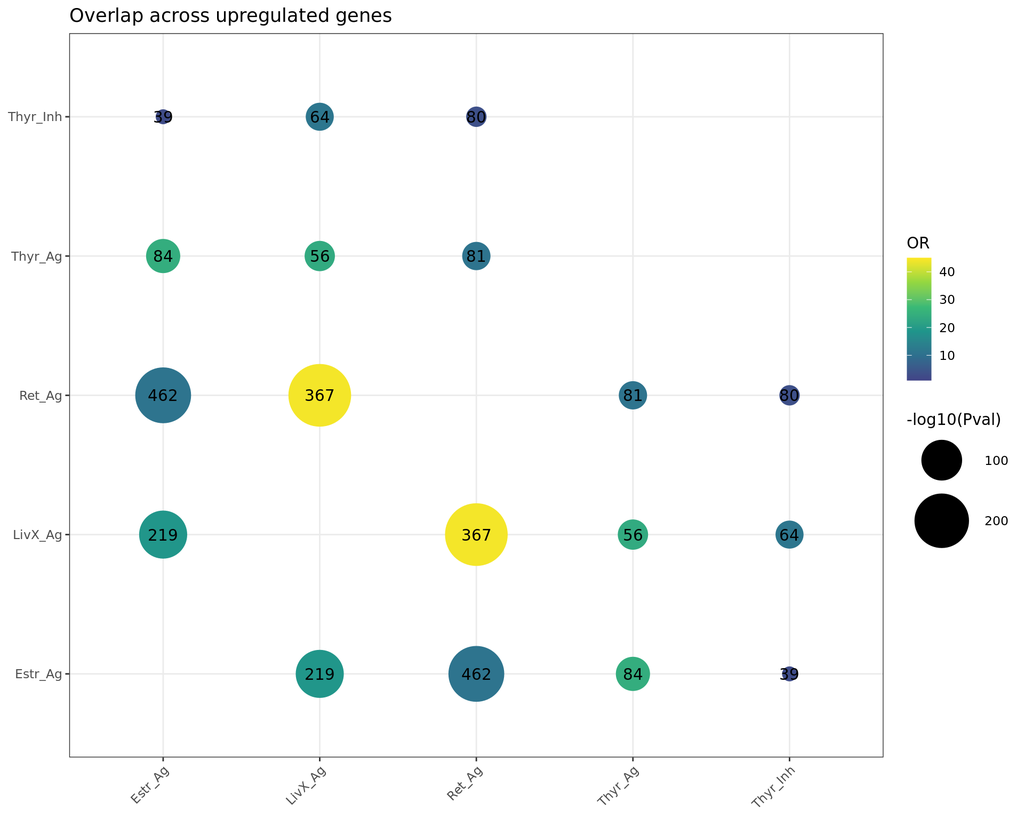

```r
Dot <- ggplot(ResSel, aes(DEGs, KBase, label=Numbers)) +
  geom_point(aes(size=-log10(Pval), col=OR)) +
  geom_text() +
  scale_size_continuous(range=c(2, 20), limits=c(2, round(-log10(min(ResSel$Pval)) + 0.5))) +
  scale_color_viridis_c(limits=c(1, round(max(ResSel$OR)+1)), begin=0.2) + xlab('') + ylab('') +
  theme_bw() +
  theme(axis.line = element_blank(), axis.title = element_blank(),
        axis.text.x = element_text(angle = 45, hjust = 1)) +
    ggtitle('Overlap across upregulated genes')

Dot
```

```r
ggsave(Dot, filename=paste0(OutputFolder, 'DotPlot_UpReg.pdf'), width=8, height=8)
```

## 5.3 Visualize overlap results selectively for retinoic, liverX, estrogen, thyroid

### Selection

Starting from already selected results, we identify only the ones related to the pathways of interest.

```r
Path <- c('Thyr_Ag', 'Thyr_Inh', 'Ret_Ag', 'Ret_Inh', 'Estr_Ag', 'LivX_Ag', 'LivX_Inh')
ResPath <- ResSel[ResSel$DEGs %in% Path & ResSel$KBase %in% Path, ]

ResPath
##        DEGs    KBase        OR          Pval Numbers
## 1    Ret_Ag  Thyr_Ag 10.905715  3.063677e-40      81
## 2   Estr_Ag  Thyr_Ag 24.469163  2.641447e-65      84
## 3   LivX_Ag  Thyr_Ag 23.635922  4.556114e-48      56
## 4    Ret_Ag Thyr_Inh  3.422680  1.283202e-16      80
## 5   Estr_Ag Thyr_Inh  2.673233  4.298987e-07      39
## 6   LivX_Ag Thyr_Inh 11.422165  2.868436e-39      64
## 7   Thyr_Ag   Ret_Ag 10.905715  3.063677e-40      81
## 8  Thyr_Inh   Ret_Ag  3.422680  1.283202e-16      80
## 9   Estr_Ag   Ret_Ag 10.923407 3.762356e-212     462
## 10  LivX_Ag   Ret_Ag 44.201409 1.730574e-276     367
## 11  Thyr_Ag  Estr_Ag 24.469163  2.641447e-65      84
## 12 Thyr_Inh  Estr_Ag  2.673233  4.298987e-07      39
## 13   Ret_Ag  Estr_Ag 10.923407 3.762356e-212     462
## 14  LivX_Ag  Estr_Ag 18.946325 1.688829e-149     219
## 15  Thyr_Ag  LivX_Ag 23.635922  4.556114e-48      56
## 16 Thyr_Inh  LivX_Ag 11.422165  2.868436e-39      64
## 17   Ret_Ag  LivX_Ag 44.201409 1.730574e-276     367
## 18  Estr_Ag  LivX_Ag 18.946325 1.688829e-149     219
```

### DotPlot: visualization

```r
min(ResPath$Pval)
```

```
## [1] 1.730574e-276
```

```r
max(ResPath$OR)
```

```
## [1] 44.20141
```

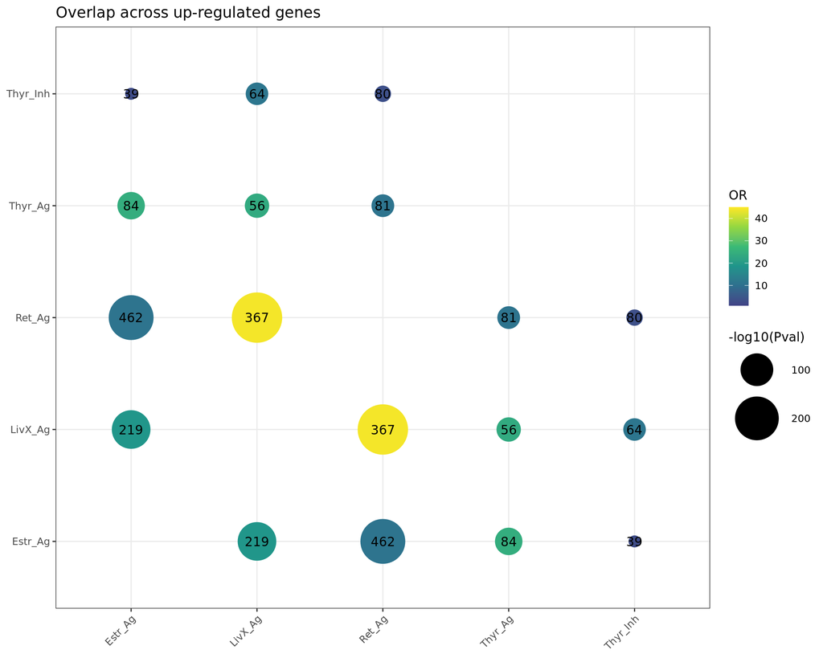

```r
Dot <- ggplot(ResPath, aes(DEGs, KBase, label=Numbers)) +
  geom_point(aes(size=-log10(Pval), col=OR)) +
  geom_text() +
  scale_size_continuous(range=c(2, 20), limits=c(2, round(-log10(min(ResSel$Pval)) + 0.5))) +
  scale_color_viridis_c(limits=c(1, round(max(ResSel$OR)+1)), begin=0.2) + xlab('') + ylab('') +
  theme_bw() +
  theme(axis.line = element_blank(), axis.title = element_blank(),
        axis.text.x = element_text(angle = 45, hjust = 1))+
  ggtitle('Overlap across up-regulated genes')


Dot
```

```r
ggsave(Dot, filename=paste0(OutputFolder, 'DotPlot_Upreg_Selected.pdf'), width=8, height=8)
```

# 6. Comparison across pathways: down-regulated genes

## 6.1 Perform the overlap

```r
DEGs_DownReg <- list(

  Thyr_Ag= row.names(DEA$Thyr$Agonist$DEGs[DEA$Thyr$Agonist$DEGs$log2FoldChange < 0, ]),
  Thyr_Inh= row.names(DEA$Thyr$Inhibitor$DEGs[DEA$Thyr$Inhibitor$DEGs$log2FoldChange < 0, ]),

  Ret_Ag= row.names(DEA$Ret$Agonist$DEGs[DEA$Ret$Agonist$DEGs$log2FoldChange < 0, ]),
  Ret_Inh= row.names(DEA$Ret$Inhibitor$DEGs[DEA$Ret$Inhibitor$DEGs$log2FoldChange < 0, ]),

  Estr_Ag= row.names(DEA$Estr$Agonist$DEGs[DEA$Estr$Agonist$DEGs$log2FoldChange < 0, ]),

  Andr_Ag= row.names(DEA$Andr$Agonist$DEGs[DEA$Andr$Agonist$DEGs$log2FoldChange < 0, ]),
  Andr_Inh= row.names(DEA$Andr$Inhibitor$DEGs[DEA$Andr$Inhibitor$DEGs$log2FoldChange < 0, ]),

  GC_Ag= row.names(DEA$GC$Agonist$DEGs[DEA$GC$Agonist$DEGs$log2FoldChange < 0, ]),
  GC_Inh= row.names(DEA$GC$Inhibitor$DEGs[DEA$GC$Inhibitor$DEGs$log2FoldChange < 0, ]),

  LivX_Ag= row.names(DEA$LivX$Agonist$DEGs[DEA$LivX$Agonist$DEGs$log2FoldChange < 0, ]),
  LivX_Inh= row.names(DEA$LivX$Inhibitor$DEGs[DEA$LivX$Inhibitor$DEGs$log2FoldChange < 0, ]),

  AhHyd_Ag= row.names(DEA$AhHyd$Agonist$DEGs[DEA$AhHyd$Agonist$DEGs$log2FoldChange < 0, ]),
  AhHyd_Inh= row.names(DEA$AhHyd$Inhibitor$DEGs[DEA$AhHyd$Inhibitor$DEGs$log2FoldChange < 0, ])

            )
```

```r
Universe <- row.names(DEA$Ret$Inhibitor$Res) %>% unique()
length(Universe)
## [1] 14850
```

```r
OvObj <- newGOM(DEGs_DownReg, DEGs_DownReg, genome.size=length(Universe))
print(OvObj)
## A GeneOverlapMatrix object:
## ###### Intersection ######
##           Thyr_Ag Thyr_Inh Ret_Ag Ret_Inh Estr_Ag Andr_Ag Andr_Inh GC_Ag GC_Inh
## Thyr_Ag        22        0      2       4       8       1        3     0      0
## Thyr_Inh        0      188     92       1      18       0        0     0     65
## Ret_Ag          2       92   1369       2     401       1        0     0     61
## Ret_Inh         4        1      2       7       3       2        1     0      1
## Estr_Ag         8       18    401       3     797       2        1     1     14
## Andr_Ag         1        0      1       2       2       4        0     0      0
## Andr_Inh        3        0      0       1       1       0        8     0      1
## GC_Ag           0        0      0       0       1       0        0     3      0
## GC_Inh          0       65     61       1      14       0        1     0    303
## LivX_Ag         0      123    210       1      72       1        1     1     68
## LivX_Inh        6        4      6       6       6       2        3     0     10
## AhHyd_Ag       12        0      2       2       9       1        3     0      1
## AhHyd_Inh       0        8     17       0      10       1        0     0      3
##           LivX_Ag LivX_Inh AhHyd_Ag AhHyd_Inh
## Thyr_Ag         0        6       12         0
## Thyr_Inh      123        4        0         8
## Ret_Ag        210        6        2        17
## Ret_Inh         1        6        2         0
## Estr_Ag        72        6        9        10
## Andr_Ag         1        2        1         1
## Andr_Inh        1        3        3         0
## GC_Ag           1        0        0         0
## GC_Inh         68       10        1         3
## LivX_Ag       383       15        1        17
## LivX_Inh       15       42        3         2
## AhHyd_Ag        1        3       58         1
## AhHyd_Inh      17        2        1        29
## ###### P-value ######
##                Thyr_Ag      Thyr_Inh        Ret_Ag      Ret_Inh       Estr_Ag
## Thyr_Ag   1.903459e-71  1.000000e+00  6.150185e-01 1.260372e-10  1.083997e-05
## Thyr_Inh  1.000000e+00  0.000000e+00  1.296458e-45 8.534049e-02  1.246963e-02
## Ret_Ag    6.150185e-01  1.296458e-45  0.000000e+00 1.306392e-01 1.370389e-215
## Ret_Inh   1.260372e-10  8.534049e-02  1.306392e-01 3.169273e-26  4.580383e-03
## Estr_Ag   1.083997e-05  1.246963e-02 1.370389e-215 4.580383e-03  0.000000e+00
## Andr_Ag   5.913366e-03  1.000000e+00  3.208514e-01 1.142304e-06  1.605467e-02
## Andr_Inh  1.572835e-07  1.000000e+00  1.000000e+00 3.765714e-03  3.568766e-01
## GC_Ag     1.000000e+00  1.000000e+00  1.000000e+00 1.000000e+00  1.525330e-01
## GC_Inh    1.000000e+00  3.521227e-63  3.519149e-09 1.344023e-01  7.558552e-01
## LivX_Ag   1.000000e+00 1.464476e-154 6.406226e-118 1.671862e-01  3.359345e-21
## LivX_Inh  2.544346e-11  1.912469e-03  1.863785e-01 2.462733e-15  2.361772e-02
## AhHyd_Ag  2.344408e-24  1.000000e+00  9.749612e-01 3.109100e-04  3.526989e-03
## AhHyd_Inh 1.000000e+00  1.943615e-09  4.044052e-11 1.000000e+00  1.477041e-06
##                Andr_Ag     Andr_Inh        GC_Ag       GC_Inh       LivX_Ag
## Thyr_Ag   5.913366e-03 1.572835e-07 1.000000e+00 1.000000e+00  1.000000e+00
## Thyr_Inh  1.000000e+00 1.000000e+00 1.000000e+00 3.521227e-63 1.464476e-154
## Ret_Ag    3.208514e-01 1.000000e+00 1.000000e+00 3.519149e-09 6.406226e-118
## Ret_Inh   1.142304e-06 3.765714e-03 1.000000e+00 1.344023e-01  1.671862e-01
## Estr_Ag   1.605467e-02 3.568766e-01 1.525330e-01 7.558552e-01  3.359345e-21
## Andr_Ag   4.937202e-16 1.000000e+00 1.000000e+00 1.000000e+00  9.925167e-02
## Andr_Inh  1.000000e+00 1.708157e-29 1.000000e+00 1.520723e-01  1.886756e-01
## GC_Ag     1.000000e+00 1.000000e+00 1.832566e-12 1.000000e+00  7.540027e-02
## GC_Inh    1.000000e+00 1.520723e-01 1.000000e+00 0.000000e+00  8.311940e-45
## LivX_Ag   9.925167e-02 1.886756e-01 7.540027e-02 8.311940e-45  0.000000e+00
## LivX_Inh  4.668738e-05 1.166562e-06 1.000000e+00 8.906368e-09  5.928677e-14
## AhHyd_Ag  1.553317e-02 3.122823e-06 1.000000e+00 6.982025e-01  7.809545e-01
## AhHyd_Inh 7.789380e-03 1.000000e+00 1.000000e+00 2.077014e-02  2.721352e-20
##                LivX_Inh      AhHyd_Ag    AhHyd_Inh
## Thyr_Ag    2.544346e-11  2.344408e-24 1.000000e+00
## Thyr_Inh   1.912469e-03  1.000000e+00 1.943615e-09
## Ret_Ag     1.863785e-01  9.749612e-01 4.044052e-11
## Ret_Inh    2.462733e-15  3.109100e-04 1.000000e+00
## Estr_Ag    2.361772e-02  3.526989e-03 1.477041e-06
## Andr_Ag    4.668738e-05  1.553317e-02 7.789380e-03
## Andr_Inh   1.166562e-06  3.122823e-06 1.000000e+00
## GC_Ag      1.000000e+00  1.000000e+00 1.000000e+00
## GC_Inh     8.906368e-09  6.982025e-01 2.077014e-02
## LivX_Ag    5.928677e-14  7.809545e-01 2.721352e-20
## LivX_Inh  9.127902e-125  5.825559e-04 3.020683e-03
## AhHyd_Ag   5.825559e-04 2.880331e-164 1.073807e-01
## AhHyd_Inh  3.020683e-03  1.073807e-01 9.513776e-91
## ###### Odds Ratio ######
##                Thyr_Ag   Thyr_Inh     Ret_Ag     Ret_Inh    Estr_Ag     Andr_Ag
## Thyr_Ag            Inf   0.000000  0.9847119 1072.559553 10.1637020  233.878672
## Thyr_Inh     0.0000000        Inf 10.0416079   13.053133  1.8869453    0.000000
## Ret_Ag       0.9847119  10.041608        Inf    3.942233 13.6832853    3.283691
## Ret_Inh   1072.5595526  13.053133  3.9422335         Inf 13.2688496 2628.731552
## Estr_Ag     10.1637020   1.886945 13.6832853   13.268850        Inf   17.661478
## Andr_Ag    233.8786721   0.000000  3.2836910 2628.731552 17.6614783         Inf
## Andr_Inh   457.8089118   0.000000  0.0000000  347.875457  2.5205522    0.000000
## GC_Ag        0.0000000   0.000000  0.0000000    0.000000  8.8236122    0.000000
## GC_Inh       0.0000000  31.989423  2.5510737    8.021994  0.8515592    0.000000
## LivX_Ag      0.0000000 104.389398 13.9349772    6.307319  4.3873765   12.611124
## LivX_Inh   153.6352357   8.362407  1.6439679 2421.329155  2.9530719  364.113328
## AhHyd_Ag   380.7075634   0.000000  0.3507583  104.966944  3.2637058   86.109402
## AhHyd_Inh    0.0000000  30.931807 14.1076574    0.000000  9.3823040  174.829143
##             Andr_Inh     GC_Ag     GC_Inh     LivX_Ag    LivX_Inh    AhHyd_Ag
## Thyr_Ag   457.808912  0.000000  0.0000000   0.0000000  153.635236 380.7075634
## Thyr_Inh    0.000000  0.000000 31.9894230 104.3893984    8.362407   0.0000000
## Ret_Ag      0.000000  0.000000  2.5510737  13.9349772    1.643968   0.3507583
## Ret_Inh   347.875457  0.000000  8.0219944   6.3073195 2421.329155 104.9669442
## Estr_Ag     2.520552  8.823612  0.8515592   4.3873765    2.953072   3.2637058
## Andr_Ag     0.000000  0.000000  0.0000000  12.6111237  364.113328  86.1094022
## Andr_Inh         Inf  0.000000  6.8754749   5.4058483  224.966301 160.2681655
## GC_Ag       0.000000       Inf  0.0000000  18.9188897    0.000000   0.0000000
## GC_Inh      6.875475  0.000000        Inf  13.0654542   15.473027   0.8417655
## LivX_Ag     5.405848 18.918890 13.0654542         Inf   21.780016   0.6618125
## LivX_Inh  224.966301  0.000000 15.4730269  21.7800158         Inf  20.6081686
## AhHyd_Ag  160.268166  0.000000  0.8417655   0.6618125   20.608169         Inf
## AhHyd_Inh   0.000000  0.000000  5.5834179  55.8396611   27.338048   9.2478668
##            AhHyd_Inh
## Thyr_Ag     0.000000
## Thyr_Inh   30.931807
## Ret_Ag     14.107657
## Ret_Inh     0.000000
## Estr_Ag     9.382304
## Andr_Ag   174.829143
## Andr_Inh    0.000000
## GC_Ag       0.000000
## GC_Inh      5.583418
## LivX_Ag    55.839661
## LivX_Inh   27.338048
## AhHyd_Ag    9.247867
## AhHyd_Inh        Inf
## ###### Jaccard Index ######
##               Thyr_Ag    Thyr_Inh      Ret_Ag     Ret_Inh     Estr_Ag
## Thyr_Ag   1.000000000 0.000000000 0.001439885 0.160000000 0.009864365
## Thyr_Inh  0.000000000 1.000000000 0.062798635 0.005154639 0.018614271
## Ret_Ag    0.001439885 0.062798635 1.000000000 0.001455604 0.227195467
## Ret_Inh   0.160000000 0.005154639 0.001455604 1.000000000 0.003745318
## Estr_Ag   0.009864365 0.018614271 0.227195467 0.003745318 1.000000000
## Andr_Ag   0.040000000 0.000000000 0.000728863 0.222222222 0.002503129
## Andr_Inh  0.111111111 0.000000000 0.000000000 0.071428571 0.001243781
## GC_Ag     0.000000000 0.000000000 0.000000000 0.000000000 0.001251564
## GC_Inh    0.000000000 0.152582160 0.037864680 0.003236246 0.012891344
## LivX_Ag   0.000000000 0.274553571 0.136186770 0.002570694 0.064981949
## LivX_Inh  0.103448276 0.017699115 0.004270463 0.139534884 0.007202881
## AhHyd_Ag  0.176470588 0.000000000 0.001403509 0.031746032 0.010638298
## AhHyd_Inh 0.000000000 0.038277512 0.012309920 0.000000000 0.012254902
##               Andr_Ag    Andr_Inh       GC_Ag      GC_Inh     LivX_Ag
## Thyr_Ag   0.040000000 0.111111111 0.000000000 0.000000000 0.000000000
## Thyr_Inh  0.000000000 0.000000000 0.000000000 0.152582160 0.274553571
## Ret_Ag    0.000728863 0.000000000 0.000000000 0.037864680 0.136186770
## Ret_Inh   0.222222222 0.071428571 0.000000000 0.003236246 0.002570694
## Estr_Ag   0.002503129 0.001243781 0.001251564 0.012891344 0.064981949
## Andr_Ag   1.000000000 0.000000000 0.000000000 0.000000000 0.002590674
## Andr_Inh  0.000000000 1.000000000 0.000000000 0.003225806 0.002564103
## GC_Ag     0.000000000 0.000000000 1.000000000 0.000000000 0.002597403
## GC_Inh    0.000000000 0.003225806 0.000000000 1.000000000 0.110032362
## LivX_Ag   0.002590674 0.002564103 0.002597403 0.110032362 1.000000000
## LivX_Inh  0.045454545 0.063829787 0.000000000 0.029850746 0.036585366
## AhHyd_Ag  0.016393443 0.047619048 0.000000000 0.002777778 0.002272727
## AhHyd_Inh 0.031250000 0.000000000 0.000000000 0.009118541 0.043037975
##              LivX_Inh    AhHyd_Ag   AhHyd_Inh
## Thyr_Ag   0.103448276 0.176470588 0.000000000
## Thyr_Inh  0.017699115 0.000000000 0.038277512
## Ret_Ag    0.004270463 0.001403509 0.012309920
## Ret_Inh   0.139534884 0.031746032 0.000000000
## Estr_Ag   0.007202881 0.010638298 0.012254902
## Andr_Ag   0.045454545 0.016393443 0.031250000
## Andr_Inh  0.063829787 0.047619048 0.000000000
## GC_Ag     0.000000000 0.000000000 0.000000000
## GC_Inh    0.029850746 0.002777778 0.009118541
## LivX_Ag   0.036585366 0.002272727 0.043037975
## LivX_Inh  1.000000000 0.030927835 0.028985507
## AhHyd_Ag  0.030927835 1.000000000 0.011627907
## AhHyd_Inh 0.028985507 0.011627907 1.000000000
```

```r
getMatrix(OvObj, name='intersection')
##           Thyr_Ag Thyr_Inh Ret_Ag Ret_Inh Estr_Ag Andr_Ag Andr_Inh GC_Ag GC_Inh
## Thyr_Ag        22        0      2       4       8       1        3     0      0
## Thyr_Inh        0      188     92       1      18       0        0     0     65
## Ret_Ag          2       92   1369       2     401       1        0     0     61
## Ret_Inh         4        1      2       7       3       2        1     0      1
## Estr_Ag         8       18    401       3     797       2        1     1     14
## Andr_Ag         1        0      1       2       2       4        0     0      0
## Andr_Inh        3        0      0       1       1       0        8     0      1
## GC_Ag           0        0      0       0       1       0        0     3      0
## GC_Inh          0       65     61       1      14       0        1     0    303
## LivX_Ag         0      123    210       1      72       1        1     1     68
## LivX_Inh        6        4      6       6       6       2        3     0     10
## AhHyd_Ag       12        0      2       2       9       1        3     0      1
## AhHyd_Inh       0        8     17       0      10       1        0     0      3
##           LivX_Ag LivX_Inh AhHyd_Ag AhHyd_Inh
## Thyr_Ag         0        6       12         0
## Thyr_Inh      123        4        0         8
## Ret_Ag        210        6        2        17
## Ret_Inh         1        6        2         0
## Estr_Ag        72        6        9        10
## Andr_Ag         1        2        1         1
## Andr_Inh        1        3        3         0
## GC_Ag           1        0        0         0
## GC_Inh         68       10        1         3
## LivX_Ag       383       15        1        17
## LivX_Inh       15       42        3         2
## AhHyd_Ag        1        3       58         1
## AhHyd_Inh      17        2        1        29
```

```r
getMatrix(OvObj, name='pval')
##                Thyr_Ag      Thyr_Inh        Ret_Ag      Ret_Inh       Estr_Ag
## Thyr_Ag   1.903459e-71  1.000000e+00  6.150185e-01 1.260372e-10  1.083997e-05
## Thyr_Inh  1.000000e+00  0.000000e+00  1.296458e-45 8.534049e-02  1.246963e-02
## Ret_Ag    6.150185e-01  1.296458e-45  0.000000e+00 1.306392e-01 1.370389e-215
## Ret_Inh   1.260372e-10  8.534049e-02  1.306392e-01 3.169273e-26  4.580383e-03
## Estr_Ag   1.083997e-05  1.246963e-02 1.370389e-215 4.580383e-03  0.000000e+00
## Andr_Ag   5.913366e-03  1.000000e+00  3.208514e-01 1.142304e-06  1.605467e-02
## Andr_Inh  1.572835e-07  1.000000e+00  1.000000e+00 3.765714e-03  3.568766e-01
## GC_Ag     1.000000e+00  1.000000e+00  1.000000e+00 1.000000e+00  1.525330e-01
## GC_Inh    1.000000e+00  3.521227e-63  3.519149e-09 1.344023e-01  7.558552e-01
## LivX_Ag   1.000000e+00 1.464476e-154 6.406226e-118 1.671862e-01  3.359345e-21
## LivX_Inh  2.544346e-11  1.912469e-03  1.863785e-01 2.462733e-15  2.361772e-02
## AhHyd_Ag  2.344408e-24  1.000000e+00  9.749612e-01 3.109100e-04  3.526989e-03
## AhHyd_Inh 1.000000e+00  1.943615e-09  4.044052e-11 1.000000e+00  1.477041e-06
##                Andr_Ag     Andr_Inh        GC_Ag       GC_Inh       LivX_Ag
## Thyr_Ag   5.913366e-03 1.572835e-07 1.000000e+00 1.000000e+00  1.000000e+00
## Thyr_Inh  1.000000e+00 1.000000e+00 1.000000e+00 3.521227e-63 1.464476e-154
## Ret_Ag    3.208514e-01 1.000000e+00 1.000000e+00 3.519149e-09 6.406226e-118
## Ret_Inh   1.142304e-06 3.765714e-03 1.000000e+00 1.344023e-01  1.671862e-01
## Estr_Ag   1.605467e-02 3.568766e-01 1.525330e-01 7.558552e-01  3.359345e-21
## Andr_Ag   4.937202e-16 1.000000e+00 1.000000e+00 1.000000e+00  9.925167e-02
## Andr_Inh  1.000000e+00 1.708157e-29 1.000000e+00 1.520723e-01  1.886756e-01
## GC_Ag     1.000000e+00 1.000000e+00 1.832566e-12 1.000000e+00  7.540027e-02
## GC_Inh    1.000000e+00 1.520723e-01 1.000000e+00 0.000000e+00  8.311940e-45
## LivX_Ag   9.925167e-02 1.886756e-01 7.540027e-02 8.311940e-45  0.000000e+00
## LivX_Inh  4.668738e-05 1.166562e-06 1.000000e+00 8.906368e-09  5.928677e-14
## AhHyd_Ag  1.553317e-02 3.122823e-06 1.000000e+00 6.982025e-01  7.809545e-01
## AhHyd_Inh 7.789380e-03 1.000000e+00 1.000000e+00 2.077014e-02  2.721352e-20
##                LivX_Inh      AhHyd_Ag    AhHyd_Inh
## Thyr_Ag    2.544346e-11  2.344408e-24 1.000000e+00
## Thyr_Inh   1.912469e-03  1.000000e+00 1.943615e-09
## Ret_Ag     1.863785e-01  9.749612e-01 4.044052e-11
## Ret_Inh    2.462733e-15  3.109100e-04 1.000000e+00
## Estr_Ag    2.361772e-02  3.526989e-03 1.477041e-06
## Andr_Ag    4.668738e-05  1.553317e-02 7.789380e-03
## Andr_Inh   1.166562e-06  3.122823e-06 1.000000e+00
## GC_Ag      1.000000e+00  1.000000e+00 1.000000e+00
## GC_Inh     8.906368e-09  6.982025e-01 2.077014e-02
## LivX_Ag    5.928677e-14  7.809545e-01 2.721352e-20
## LivX_Inh  9.127902e-125  5.825559e-04 3.020683e-03
## AhHyd_Ag   5.825559e-04 2.880331e-164 1.073807e-01
## AhHyd_Inh  3.020683e-03  1.073807e-01 9.513776e-91
```

```r
getMatrix(OvObj, name='odds.ratio')
##                Thyr_Ag   Thyr_Inh     Ret_Ag     Ret_Inh    Estr_Ag     Andr_Ag
## Thyr_Ag            Inf   0.000000  0.9847119 1072.559553 10.1637020  233.878672
## Thyr_Inh     0.0000000        Inf 10.0416079   13.053133  1.8869453    0.000000
## Ret_Ag       0.9847119  10.041608        Inf    3.942233 13.6832853    3.283691
## Ret_Inh   1072.5595526  13.053133  3.9422335         Inf 13.2688496 2628.731552
## Estr_Ag     10.1637020   1.886945 13.6832853   13.268850        Inf   17.661478
## Andr_Ag    233.8786721   0.000000  3.2836910 2628.731552 17.6614783         Inf
## Andr_Inh   457.8089118   0.000000  0.0000000  347.875457  2.5205522    0.000000
## GC_Ag        0.0000000   0.000000  0.0000000    0.000000  8.8236122    0.000000
## GC_Inh       0.0000000  31.989423  2.5510737    8.021994  0.8515592    0.000000
## LivX_Ag      0.0000000 104.389398 13.9349772    6.307319  4.3873765   12.611124
## LivX_Inh   153.6352357   8.362407  1.6439679 2421.329155  2.9530719  364.113328
## AhHyd_Ag   380.7075634   0.000000  0.3507583  104.966944  3.2637058   86.109402
## AhHyd_Inh    0.0000000  30.931807 14.1076574    0.000000  9.3823040  174.829143
##             Andr_Inh     GC_Ag     GC_Inh     LivX_Ag    LivX_Inh    AhHyd_Ag
## Thyr_Ag   457.808912  0.000000  0.0000000   0.0000000  153.635236 380.7075634
## Thyr_Inh    0.000000  0.000000 31.9894230 104.3893984    8.362407   0.0000000
## Ret_Ag      0.000000  0.000000  2.5510737  13.9349772    1.643968   0.3507583
## Ret_Inh   347.875457  0.000000  8.0219944   6.3073195 2421.329155 104.9669442
## Estr_Ag     2.520552  8.823612  0.8515592   4.3873765    2.953072   3.2637058
## Andr_Ag     0.000000  0.000000  0.0000000  12.6111237  364.113328  86.1094022
## Andr_Inh         Inf  0.000000  6.8754749   5.4058483  224.966301 160.2681655
## GC_Ag       0.000000       Inf  0.0000000  18.9188897    0.000000   0.0000000
## GC_Inh      6.875475  0.000000        Inf  13.0654542   15.473027   0.8417655
## LivX_Ag     5.405848 18.918890 13.0654542         Inf   21.780016   0.6618125
## LivX_Inh  224.966301  0.000000 15.4730269  21.7800158         Inf  20.6081686
## AhHyd_Ag  160.268166  0.000000  0.8417655   0.6618125   20.608169         Inf
## AhHyd_Inh   0.000000  0.000000  5.5834179  55.8396611   27.338048   9.2478668
##            AhHyd_Inh
## Thyr_Ag     0.000000
## Thyr_Inh   30.931807
## Ret_Ag     14.107657
## Ret_Inh     0.000000
## Estr_Ag     9.382304
## Andr_Ag   174.829143
## Andr_Inh    0.000000
## GC_Ag       0.000000
## GC_Inh      5.583418
## LivX_Ag    55.839661
## LivX_Inh   27.338048
## AhHyd_Ag    9.247867
## AhHyd_Inh        Inf
```

## 6.2 Visualize overlap results

**DotPlot: data preparation**

```r
OR <- data.frame(getMatrix(OvObj, name='odds.ratio'))
OR$DEGs <- row.names(OR)
OR <- gather(OR, 'KBase', 'OR', -DEGs)
PVAL <- data.frame(getMatrix(OvObj, name='pval'))
PVAL$DEGs <- row.names(PVAL)
PVAL <- gather(PVAL, 'KBase', 'PVal', -DEGs)
NUM <- data.frame(getMatrix(OvObj, name='intersection'))
NUM$DEGs <- row.names(NUM)
NUM <- gather(NUM, 'KBase', 'Numbers', -DEGs)
if(! identical(OR$DEGs, PVAL$DEGs)){
  stop('Inconsistecy')
}
if(! identical(OR$DEGs, NUM$DEGs)){
  stop('Inconsistecy')
}
if(! identical(OR$KBase, NUM$KBase)){
  stop('Inconsistecy')
}
if(! identical(OR$KBase, NUM$KBase)){
  stop('Inconsistecy')
}
Res <- mutate(OR, Pval=PVAL$PVal) %>% mutate(Numbers=NUM$Numbers)
Res
##          DEGs     KBase           OR          Pval Numbers
## 1     Thyr_Ag   Thyr_Ag          Inf  1.903459e-71      22
## 2    Thyr_Inh   Thyr_Ag    0.0000000  1.000000e+00       0
## 3      Ret_Ag   Thyr_Ag    0.9847119  6.150185e-01       2
## 4     Ret_Inh   Thyr_Ag 1072.5595526  1.260372e-10       4
## 5     Estr_Ag   Thyr_Ag   10.1637020  1.083997e-05       8
## 6     Andr_Ag   Thyr_Ag  233.8786721  5.913366e-03       1
## 7    Andr_Inh   Thyr_Ag  457.8089118  1.572835e-07       3
## 8       GC_Ag   Thyr_Ag    0.0000000  1.000000e+00       0
## 9      GC_Inh   Thyr_Ag    0.0000000  1.000000e+00       0
## 10    LivX_Ag   Thyr_Ag    0.0000000  1.000000e+00       0
## 11   LivX_Inh   Thyr_Ag  153.6352357  2.544346e-11       6
## 12   AhHyd_Ag   Thyr_Ag  380.7075634  2.344408e-24      12
## 13  AhHyd_Inh   Thyr_Ag    0.0000000  1.000000e+00       0
## 14    Thyr_Ag  Thyr_Inh    0.0000000  1.000000e+00       0
## 15   Thyr_Inh  Thyr_Inh          Inf  0.000000e+00     188
## 16     Ret_Ag  Thyr_Inh   10.0416079  1.296458e-45      92
## 17    Ret_Inh  Thyr_Inh   13.0531334  8.534049e-02       1
## 18    Estr_Ag  Thyr_Inh    1.8869453  1.246963e-02      18
## 19    Andr_Ag  Thyr_Inh    0.0000000  1.000000e+00       0
## 20   Andr_Inh  Thyr_Inh    0.0000000  1.000000e+00       0
## 21      GC_Ag  Thyr_Inh    0.0000000  1.000000e+00       0
## 22     GC_Inh  Thyr_Inh   31.9894230  3.521227e-63      65
## 23    LivX_Ag  Thyr_Inh  104.3893984 1.464476e-154     123
## 24   LivX_Inh  Thyr_Inh    8.3624069  1.912469e-03       4
## 25   AhHyd_Ag  Thyr_Inh    0.0000000  1.000000e+00       0
## 26  AhHyd_Inh  Thyr_Inh   30.9318073  1.943615e-09       8
## 27    Thyr_Ag    Ret_Ag    0.9847119  6.150185e-01       2
## 28   Thyr_Inh    Ret_Ag   10.0416079  1.296458e-45      92
## 29     Ret_Ag    Ret_Ag          Inf  0.000000e+00    1369
## 30    Ret_Inh    Ret_Ag    3.9422335  1.306392e-01       2
## 31    Estr_Ag    Ret_Ag   13.6832853 1.370389e-215     401
## 32    Andr_Ag    Ret_Ag    3.2836910  3.208514e-01       1
## 33   Andr_Inh    Ret_Ag    0.0000000  1.000000e+00       0
## 34      GC_Ag    Ret_Ag    0.0000000  1.000000e+00       0
## 35     GC_Inh    Ret_Ag    2.5510737  3.519149e-09      61
## 36    LivX_Ag    Ret_Ag   13.9349772 6.406226e-118     210
## 37   LivX_Inh    Ret_Ag    1.6439679  1.863785e-01       6
## 38   AhHyd_Ag    Ret_Ag    0.3507583  9.749612e-01       2
## 39  AhHyd_Inh    Ret_Ag   14.1076574  4.044052e-11      17
## 40    Thyr_Ag   Ret_Inh 1072.5595526  1.260372e-10       4
## 41   Thyr_Inh   Ret_Inh   13.0531334  8.534049e-02       1
## 42     Ret_Ag   Ret_Inh    3.9422335  1.306392e-01       2
## 43    Ret_Inh   Ret_Inh          Inf  3.169273e-26       7
## 44    Estr_Ag   Ret_Inh   13.2688496  4.580383e-03       3
## 45    Andr_Ag   Ret_Inh 2628.7315517  1.142304e-06       2
## 46   Andr_Inh   Ret_Inh  347.8754566  3.765714e-03       1
## 47      GC_Ag   Ret_Inh    0.0000000  1.000000e+00       0
## 48     GC_Inh   Ret_Inh    8.0219944  1.344023e-01       1
## 49    LivX_Ag   Ret_Inh    6.3073195  1.671862e-01       1
## 50   LivX_Inh   Ret_Inh 2421.3291551  2.462733e-15       6
## 51   AhHyd_Ag   Ret_Inh  104.9669442  3.109100e-04       2
## 52  AhHyd_Inh   Ret_Inh    0.0000000  1.000000e+00       0
## 53    Thyr_Ag   Estr_Ag   10.1637020  1.083997e-05       8
## 54   Thyr_Inh   Estr_Ag    1.8869453  1.246963e-02      18
## 55     Ret_Ag   Estr_Ag   13.6832853 1.370389e-215     401
## 56    Ret_Inh   Estr_Ag   13.2688496  4.580383e-03       3
## 57    Estr_Ag   Estr_Ag          Inf  0.000000e+00     797
## 58    Andr_Ag   Estr_Ag   17.6614783  1.605467e-02       2
## 59   Andr_Inh   Estr_Ag    2.5205522  3.568766e-01       1
## 60      GC_Ag   Estr_Ag    8.8236122  1.525330e-01       1
## 61     GC_Inh   Estr_Ag    0.8515592  7.558552e-01      14
## 62    LivX_Ag   Estr_Ag    4.3873765  3.359345e-21      72
## 63   LivX_Inh   Estr_Ag    2.9530719  2.361772e-02       6
## 64   AhHyd_Ag   Estr_Ag    3.2637058  3.526989e-03       9
## 65  AhHyd_Inh   Estr_Ag    9.3823040  1.477041e-06      10
## 66    Thyr_Ag   Andr_Ag  233.8786721  5.913366e-03       1
## 67   Thyr_Inh   Andr_Ag    0.0000000  1.000000e+00       0
## 68     Ret_Ag   Andr_Ag    3.2836910  3.208514e-01       1
## 69    Ret_Inh   Andr_Ag 2628.7315517  1.142304e-06       2
## 70    Estr_Ag   Andr_Ag   17.6614783  1.605467e-02       2
## 71    Andr_Ag   Andr_Ag          Inf  4.937202e-16       4
## 72   Andr_Inh   Andr_Ag    0.0000000  1.000000e+00       0
## 73      GC_Ag   Andr_Ag    0.0000000  1.000000e+00       0
## 74     GC_Inh   Andr_Ag    0.0000000  1.000000e+00       0
## 75    LivX_Ag   Andr_Ag   12.6111237  9.925167e-02       1
## 76   LivX_Inh   Andr_Ag  364.1133279  4.668738e-05       2
## 77   AhHyd_Ag   Andr_Ag   86.1094022  1.553317e-02       1
## 78  AhHyd_Inh   Andr_Ag  174.8291431  7.789380e-03       1
## 79    Thyr_Ag  Andr_Inh  457.8089118  1.572835e-07       3
## 80   Thyr_Inh  Andr_Inh    0.0000000  1.000000e+00       0
## 81     Ret_Ag  Andr_Inh    0.0000000  1.000000e+00       0
## 82    Ret_Inh  Andr_Inh  347.8754566  3.765714e-03       1
## 83    Estr_Ag  Andr_Inh    2.5205522  3.568766e-01       1
## 84    Andr_Ag  Andr_Inh    0.0000000  1.000000e+00       0
## 85   Andr_Inh  Andr_Inh          Inf  1.708157e-29       8
## 86      GC_Ag  Andr_Inh    0.0000000  1.000000e+00       0
## 87     GC_Inh  Andr_Inh    6.8754749  1.520723e-01       1
## 88    LivX_Ag  Andr_Inh    5.4058483  1.886756e-01       1
## 89   LivX_Inh  Andr_Inh  224.9663006  1.166562e-06       3
## 90   AhHyd_Ag  Andr_Inh  160.2681655  3.122823e-06       3
## 91  AhHyd_Inh  Andr_Inh    0.0000000  1.000000e+00       0
## 92    Thyr_Ag     GC_Ag    0.0000000  1.000000e+00       0
## 93   Thyr_Inh     GC_Ag    0.0000000  1.000000e+00       0
## 94     Ret_Ag     GC_Ag    0.0000000  1.000000e+00       0
## 95    Ret_Inh     GC_Ag    0.0000000  1.000000e+00       0
## 96    Estr_Ag     GC_Ag    8.8236122  1.525330e-01       1
## 97    Andr_Ag     GC_Ag    0.0000000  1.000000e+00       0
## 98   Andr_Inh     GC_Ag    0.0000000  1.000000e+00       0
## 99      GC_Ag     GC_Ag          Inf  1.832566e-12       3
## 100    GC_Inh     GC_Ag    0.0000000  1.000000e+00       0
## 101   LivX_Ag     GC_Ag   18.9188897  7.540027e-02       1
## 102  LivX_Inh     GC_Ag    0.0000000  1.000000e+00       0
## 103  AhHyd_Ag     GC_Ag    0.0000000  1.000000e+00       0
## 104 AhHyd_Inh     GC_Ag    0.0000000  1.000000e+00       0
## 105   Thyr_Ag    GC_Inh    0.0000000  1.000000e+00       0
## 106  Thyr_Inh    GC_Inh   31.9894230  3.521227e-63      65
## 107    Ret_Ag    GC_Inh    2.5510737  3.519149e-09      61
## 108   Ret_Inh    GC_Inh    8.0219944  1.344023e-01       1
## 109   Estr_Ag    GC_Inh    0.8515592  7.558552e-01      14
## 110   Andr_Ag    GC_Inh    0.0000000  1.000000e+00       0
## 111  Andr_Inh    GC_Inh    6.8754749  1.520723e-01       1
## 112     GC_Ag    GC_Inh    0.0000000  1.000000e+00       0
## 113    GC_Inh    GC_Inh          Inf  0.000000e+00     303
## 114   LivX_Ag    GC_Inh   13.0654542  8.311940e-45      68
## 115  LivX_Inh    GC_Inh   15.4730269  8.906368e-09      10
## 116  AhHyd_Ag    GC_Inh    0.8417655  6.982025e-01       1
## 117 AhHyd_Inh    GC_Inh    5.5834179  2.077014e-02       3
## 118   Thyr_Ag   LivX_Ag    0.0000000  1.000000e+00       0
## 119  Thyr_Inh   LivX_Ag  104.3893984 1.464476e-154     123
## 120    Ret_Ag   LivX_Ag   13.9349772 6.406226e-118     210
## 121   Ret_Inh   LivX_Ag    6.3073195  1.671862e-01       1
## 122   Estr_Ag   LivX_Ag    4.3873765  3.359345e-21      72
## 123   Andr_Ag   LivX_Ag   12.6111237  9.925167e-02       1
## 124  Andr_Inh   LivX_Ag    5.4058483  1.886756e-01       1
## 125     GC_Ag   LivX_Ag   18.9188897  7.540027e-02       1
## 126    GC_Inh   LivX_Ag   13.0654542  8.311940e-45      68
## 127   LivX_Ag   LivX_Ag          Inf  0.000000e+00     383
## 128  LivX_Inh   LivX_Ag   21.7800158  5.928677e-14      15
## 129  AhHyd_Ag   LivX_Ag    0.6618125  7.809545e-01       1
## 130 AhHyd_Inh   LivX_Ag   55.8396611  2.721352e-20      17
## 131   Thyr_Ag  LivX_Inh  153.6352357  2.544346e-11       6
## 132  Thyr_Inh  LivX_Inh    8.3624069  1.912469e-03       4
## 133    Ret_Ag  LivX_Inh    1.6439679  1.863785e-01       6
## 134   Ret_Inh  LivX_Inh 2421.3291551  2.462733e-15       6
## 135   Estr_Ag  LivX_Inh    2.9530719  2.361772e-02       6
## 136   Andr_Ag  LivX_Inh  364.1133279  4.668738e-05       2
## 137  Andr_Inh  LivX_Inh  224.9663006  1.166562e-06       3
## 138     GC_Ag  LivX_Inh    0.0000000  1.000000e+00       0
## 139    GC_Inh  LivX_Inh   15.4730269  8.906368e-09      10
## 140   LivX_Ag  LivX_Inh   21.7800158  5.928677e-14      15
## 141  LivX_Inh  LivX_Inh          Inf 9.127902e-125      42
## 142  AhHyd_Ag  LivX_Inh   20.6081686  5.825559e-04       3
## 143 AhHyd_Inh  LivX_Inh   27.3380477  3.020683e-03       2
## 144   Thyr_Ag  AhHyd_Ag  380.7075634  2.344408e-24      12
## 145  Thyr_Inh  AhHyd_Ag    0.0000000  1.000000e+00       0
## 146    Ret_Ag  AhHyd_Ag    0.3507583  9.749612e-01       2
## 147   Ret_Inh  AhHyd_Ag  104.9669442  3.109100e-04       2
## 148   Estr_Ag  AhHyd_Ag    3.2637058  3.526989e-03       9
## 149   Andr_Ag  AhHyd_Ag   86.1094022  1.553317e-02       1
## 150  Andr_Inh  AhHyd_Ag  160.2681655  3.122823e-06       3
## 151     GC_Ag  AhHyd_Ag    0.0000000  1.000000e+00       0
## 152    GC_Inh  AhHyd_Ag    0.8417655  6.982025e-01       1
## 153   LivX_Ag  AhHyd_Ag    0.6618125  7.809545e-01       1
## 154  LivX_Inh  AhHyd_Ag   20.6081686  5.825559e-04       3
## 155  AhHyd_Ag  AhHyd_Ag          Inf 2.880331e-164      58
## 156 AhHyd_Inh  AhHyd_Ag    9.2478668  1.073807e-01       1
## 157   Thyr_Ag AhHyd_Inh    0.0000000  1.000000e+00       0
## 158  Thyr_Inh AhHyd_Inh   30.9318073  1.943615e-09       8
## 159    Ret_Ag AhHyd_Inh   14.1076574  4.044052e-11      17
## 160   Ret_Inh AhHyd_Inh    0.0000000  1.000000e+00       0
## 161   Estr_Ag AhHyd_Inh    9.3823040  1.477041e-06      10
## 162   Andr_Ag AhHyd_Inh  174.8291431  7.789380e-03       1
## 163  Andr_Inh AhHyd_Inh    0.0000000  1.000000e+00       0
## 164     GC_Ag AhHyd_Inh    0.0000000  1.000000e+00       0
## 165    GC_Inh AhHyd_Inh    5.5834179  2.077014e-02       3
## 166   LivX_Ag AhHyd_Inh   55.8396611  2.721352e-20      17
## 167  LivX_Inh AhHyd_Inh   27.3380477  3.020683e-03       2
## 168  AhHyd_Ag AhHyd_Inh    9.2478668  1.073807e-01       1
## 169 AhHyd_Inh AhHyd_Inh          Inf  9.513776e-91      29
```

```r
ResMod <- Res

ResMod[ResMod$DEGs == ResMod$KBase, ]$OR <- 1
ResMod[ResMod$DEGs == ResMod$KBase, ]$Pval <- 1

ResMod
##          DEGs     KBase           OR          Pval Numbers
## 1     Thyr_Ag   Thyr_Ag    1.0000000  1.000000e+00      22
## 2    Thyr_Inh   Thyr_Ag    0.0000000  1.000000e+00       0
## 3      Ret_Ag   Thyr_Ag    0.9847119  6.150185e-01       2
## 4     Ret_Inh   Thyr_Ag 1072.5595526  1.260372e-10       4
## 5     Estr_Ag   Thyr_Ag   10.1637020  1.083997e-05       8
## 6     Andr_Ag   Thyr_Ag  233.8786721  5.913366e-03       1
## 7    Andr_Inh   Thyr_Ag  457.8089118  1.572835e-07       3
## 8       GC_Ag   Thyr_Ag    0.0000000  1.000000e+00       0
## 9      GC_Inh   Thyr_Ag    0.0000000  1.000000e+00       0
## 10    LivX_Ag   Thyr_Ag    0.0000000  1.000000e+00       0
## 11   LivX_Inh   Thyr_Ag  153.6352357  2.544346e-11       6
## 12   AhHyd_Ag   Thyr_Ag  380.7075634  2.344408e-24      12
## 13  AhHyd_Inh   Thyr_Ag    0.0000000  1.000000e+00       0
## 14    Thyr_Ag  Thyr_Inh    0.0000000  1.000000e+00       0
## 15   Thyr_Inh  Thyr_Inh    1.0000000  1.000000e+00     188
## 16     Ret_Ag  Thyr_Inh   10.0416079  1.296458e-45      92
## 17    Ret_Inh  Thyr_Inh   13.0531334  8.534049e-02       1
## 18    Estr_Ag  Thyr_Inh    1.8869453  1.246963e-02      18
## 19    Andr_Ag  Thyr_Inh    0.0000000  1.000000e+00       0
## 20   Andr_Inh  Thyr_Inh    0.0000000  1.000000e+00       0
## 21      GC_Ag  Thyr_Inh    0.0000000  1.000000e+00       0
## 22     GC_Inh  Thyr_Inh   31.9894230  3.521227e-63      65
## 23    LivX_Ag  Thyr_Inh  104.3893984 1.464476e-154     123
## 24   LivX_Inh  Thyr_Inh    8.3624069  1.912469e-03       4
## 25   AhHyd_Ag  Thyr_Inh    0.0000000  1.000000e+00       0
## 26  AhHyd_Inh  Thyr_Inh   30.9318073  1.943615e-09       8
## 27    Thyr_Ag    Ret_Ag    0.9847119  6.150185e-01       2
## 28   Thyr_Inh    Ret_Ag   10.0416079  1.296458e-45      92
## 29     Ret_Ag    Ret_Ag    1.0000000  1.000000e+00    1369
## 30    Ret_Inh    Ret_Ag    3.9422335  1.306392e-01       2
## 31    Estr_Ag    Ret_Ag   13.6832853 1.370389e-215     401
## 32    Andr_Ag    Ret_Ag    3.2836910  3.208514e-01       1
## 33   Andr_Inh    Ret_Ag    0.0000000  1.000000e+00       0
## 34      GC_Ag    Ret_Ag    0.0000000  1.000000e+00       0
## 35     GC_Inh    Ret_Ag    2.5510737  3.519149e-09      61
## 36    LivX_Ag    Ret_Ag   13.9349772 6.406226e-118     210
## 37   LivX_Inh    Ret_Ag    1.6439679  1.863785e-01       6
## 38   AhHyd_Ag    Ret_Ag    0.3507583  9.749612e-01       2
## 39  AhHyd_Inh    Ret_Ag   14.1076574  4.044052e-11      17
## 40    Thyr_Ag   Ret_Inh 1072.5595526  1.260372e-10       4
## 41   Thyr_Inh   Ret_Inh   13.0531334  8.534049e-02       1
## 42     Ret_Ag   Ret_Inh    3.9422335  1.306392e-01       2
## 43    Ret_Inh   Ret_Inh    1.0000000  1.000000e+00       7
## 44    Estr_Ag   Ret_Inh   13.2688496  4.580383e-03       3
## 45    Andr_Ag   Ret_Inh 2628.7315517  1.142304e-06       2
## 46   Andr_Inh   Ret_Inh  347.8754566  3.765714e-03       1
## 47      GC_Ag   Ret_Inh    0.0000000  1.000000e+00       0
## 48     GC_Inh   Ret_Inh    8.0219944  1.344023e-01       1
## 49    LivX_Ag   Ret_Inh    6.3073195  1.671862e-01       1
## 50   LivX_Inh   Ret_Inh 2421.3291551  2.462733e-15       6
## 51   AhHyd_Ag   Ret_Inh  104.9669442  3.109100e-04       2
## 52  AhHyd_Inh   Ret_Inh    0.0000000  1.000000e+00       0
## 53    Thyr_Ag   Estr_Ag   10.1637020  1.083997e-05       8
## 54   Thyr_Inh   Estr_Ag    1.8869453  1.246963e-02      18
## 55     Ret_Ag   Estr_Ag   13.6832853 1.370389e-215     401
## 56    Ret_Inh   Estr_Ag   13.2688496  4.580383e-03       3
## 57    Estr_Ag   Estr_Ag    1.0000000  1.000000e+00     797
## 58    Andr_Ag   Estr_Ag   17.6614783  1.605467e-02       2
## 59   Andr_Inh   Estr_Ag    2.5205522  3.568766e-01       1
## 60      GC_Ag   Estr_Ag    8.8236122  1.525330e-01       1
## 61     GC_Inh   Estr_Ag    0.8515592  7.558552e-01      14
## 62    LivX_Ag   Estr_Ag    4.3873765  3.359345e-21      72
## 63   LivX_Inh   Estr_Ag    2.9530719  2.361772e-02       6
## 64   AhHyd_Ag   Estr_Ag    3.2637058  3.526989e-03       9
## 65  AhHyd_Inh   Estr_Ag    9.3823040  1.477041e-06      10
## 66    Thyr_Ag   Andr_Ag  233.8786721  5.913366e-03       1
## 67   Thyr_Inh   Andr_Ag    0.0000000  1.000000e+00       0
## 68     Ret_Ag   Andr_Ag    3.2836910  3.208514e-01       1
## 69    Ret_Inh   Andr_Ag 2628.7315517  1.142304e-06       2
## 70    Estr_Ag   Andr_Ag   17.6614783  1.605467e-02       2
## 71    Andr_Ag   Andr_Ag    1.0000000  1.000000e+00       4
## 72   Andr_Inh   Andr_Ag    0.0000000  1.000000e+00       0
## 73      GC_Ag   Andr_Ag    0.0000000  1.000000e+00       0
## 74     GC_Inh   Andr_Ag    0.0000000  1.000000e+00       0
## 75    LivX_Ag   Andr_Ag   12.6111237  9.925167e-02       1
## 76   LivX_Inh   Andr_Ag  364.1133279  4.668738e-05       2
## 77   AhHyd_Ag   Andr_Ag   86.1094022  1.553317e-02       1
## 78  AhHyd_Inh   Andr_Ag  174.8291431  7.789380e-03       1
## 79    Thyr_Ag  Andr_Inh  457.8089118  1.572835e-07       3
## 80   Thyr_Inh  Andr_Inh    0.0000000  1.000000e+00       0
## 81     Ret_Ag  Andr_Inh    0.0000000  1.000000e+00       0
## 82    Ret_Inh  Andr_Inh  347.8754566  3.765714e-03       1
## 83    Estr_Ag  Andr_Inh    2.5205522  3.568766e-01       1
## 84    Andr_Ag  Andr_Inh    0.0000000  1.000000e+00       0
## 85   Andr_Inh  Andr_Inh    1.0000000  1.000000e+00       8
## 86      GC_Ag  Andr_Inh    0.0000000  1.000000e+00       0
## 87     GC_Inh  Andr_Inh    6.8754749  1.520723e-01       1
## 88    LivX_Ag  Andr_Inh    5.4058483  1.886756e-01       1
## 89   LivX_Inh  Andr_Inh  224.9663006  1.166562e-06       3
## 90   AhHyd_Ag  Andr_Inh  160.2681655  3.122823e-06       3
## 91  AhHyd_Inh  Andr_Inh    0.0000000  1.000000e+00       0
## 92    Thyr_Ag     GC_Ag    0.0000000  1.000000e+00       0
## 93   Thyr_Inh     GC_Ag    0.0000000  1.000000e+00       0
## 94     Ret_Ag     GC_Ag    0.0000000  1.000000e+00       0
## 95    Ret_Inh     GC_Ag    0.0000000  1.000000e+00       0
## 96    Estr_Ag     GC_Ag    8.8236122  1.525330e-01       1
## 97    Andr_Ag     GC_Ag    0.0000000  1.000000e+00       0
## 98   Andr_Inh     GC_Ag    0.0000000  1.000000e+00       0
## 99      GC_Ag     GC_Ag    1.0000000  1.000000e+00       3
## 100    GC_Inh     GC_Ag    0.0000000  1.000000e+00       0
## 101   LivX_Ag     GC_Ag   18.9188897  7.540027e-02       1
## 102  LivX_Inh     GC_Ag    0.0000000  1.000000e+00       0
## 103  AhHyd_Ag     GC_Ag    0.0000000  1.000000e+00       0
## 104 AhHyd_Inh     GC_Ag    0.0000000  1.000000e+00       0
## 105   Thyr_Ag    GC_Inh    0.0000000  1.000000e+00       0
## 106  Thyr_Inh    GC_Inh   31.9894230  3.521227e-63      65
## 107    Ret_Ag    GC_Inh    2.5510737  3.519149e-09      61
## 108   Ret_Inh    GC_Inh    8.0219944  1.344023e-01       1
## 109   Estr_Ag    GC_Inh    0.8515592  7.558552e-01      14
## 110   Andr_Ag    GC_Inh    0.0000000  1.000000e+00       0
## 111  Andr_Inh    GC_Inh    6.8754749  1.520723e-01       1
## 112     GC_Ag    GC_Inh    0.0000000  1.000000e+00       0
## 113    GC_Inh    GC_Inh    1.0000000  1.000000e+00     303
## 114   LivX_Ag    GC_Inh   13.0654542  8.311940e-45      68
## 115  LivX_Inh    GC_Inh   15.4730269  8.906368e-09      10
## 116  AhHyd_Ag    GC_Inh    0.8417655  6.982025e-01       1
## 117 AhHyd_Inh    GC_Inh    5.5834179  2.077014e-02       3
## 118   Thyr_Ag   LivX_Ag    0.0000000  1.000000e+00       0
## 119  Thyr_Inh   LivX_Ag  104.3893984 1.464476e-154     123
## 120    Ret_Ag   LivX_Ag   13.9349772 6.406226e-118     210
## 121   Ret_Inh   LivX_Ag    6.3073195  1.671862e-01       1
## 122   Estr_Ag   LivX_Ag    4.3873765  3.359345e-21      72
## 123   Andr_Ag   LivX_Ag   12.6111237  9.925167e-02       1
## 124  Andr_Inh   LivX_Ag    5.4058483  1.886756e-01       1
## 125     GC_Ag   LivX_Ag   18.9188897  7.540027e-02       1
## 126    GC_Inh   LivX_Ag   13.0654542  8.311940e-45      68
## 127   LivX_Ag   LivX_Ag    1.0000000  1.000000e+00     383
## 128  LivX_Inh   LivX_Ag   21.7800158  5.928677e-14      15
## 129  AhHyd_Ag   LivX_Ag    0.6618125  7.809545e-01       1
## 130 AhHyd_Inh   LivX_Ag   55.8396611  2.721352e-20      17
## 131   Thyr_Ag  LivX_Inh  153.6352357  2.544346e-11       6
## 132  Thyr_Inh  LivX_Inh    8.3624069  1.912469e-03       4
## 133    Ret_Ag  LivX_Inh    1.6439679  1.863785e-01       6
## 134   Ret_Inh  LivX_Inh 2421.3291551  2.462733e-15       6
## 135   Estr_Ag  LivX_Inh    2.9530719  2.361772e-02       6
## 136   Andr_Ag  LivX_Inh  364.1133279  4.668738e-05       2
## 137  Andr_Inh  LivX_Inh  224.9663006  1.166562e-06       3
## 138     GC_Ag  LivX_Inh    0.0000000  1.000000e+00       0
## 139    GC_Inh  LivX_Inh   15.4730269  8.906368e-09      10
## 140   LivX_Ag  LivX_Inh   21.7800158  5.928677e-14      15
## 141  LivX_Inh  LivX_Inh    1.0000000  1.000000e+00      42
## 142  AhHyd_Ag  LivX_Inh   20.6081686  5.825559e-04       3
## 143 AhHyd_Inh  LivX_Inh   27.3380477  3.020683e-03       2
## 144   Thyr_Ag  AhHyd_Ag  380.7075634  2.344408e-24      12
## 145  Thyr_Inh  AhHyd_Ag    0.0000000  1.000000e+00       0
## 146    Ret_Ag  AhHyd_Ag    0.3507583  9.749612e-01       2
## 147   Ret_Inh  AhHyd_Ag  104.9669442  3.109100e-04       2
## 148   Estr_Ag  AhHyd_Ag    3.2637058  3.526989e-03       9
## 149   Andr_Ag  AhHyd_Ag   86.1094022  1.553317e-02       1
## 150  Andr_Inh  AhHyd_Ag  160.2681655  3.122823e-06       3
## 151     GC_Ag  AhHyd_Ag    0.0000000  1.000000e+00       0
## 152    GC_Inh  AhHyd_Ag    0.8417655  6.982025e-01       1
## 153   LivX_Ag  AhHyd_Ag    0.6618125  7.809545e-01       1
## 154  LivX_Inh  AhHyd_Ag   20.6081686  5.825559e-04       3
## 155  AhHyd_Ag  AhHyd_Ag    1.0000000  1.000000e+00      58
## 156 AhHyd_Inh  AhHyd_Ag    9.2478668  1.073807e-01       1
## 157   Thyr_Ag AhHyd_Inh    0.0000000  1.000000e+00       0
## 158  Thyr_Inh AhHyd_Inh   30.9318073  1.943615e-09       8
## 159    Ret_Ag AhHyd_Inh   14.1076574  4.044052e-11      17
## 160   Ret_Inh AhHyd_Inh    0.0000000  1.000000e+00       0
## 161   Estr_Ag AhHyd_Inh    9.3823040  1.477041e-06      10
## 162   Andr_Ag AhHyd_Inh  174.8291431  7.789380e-03       1
## 163  Andr_Inh AhHyd_Inh    0.0000000  1.000000e+00       0
## 164     GC_Ag AhHyd_Inh    0.0000000  1.000000e+00       0
## 165    GC_Inh AhHyd_Inh    5.5834179  2.077014e-02       3
## 166   LivX_Ag AhHyd_Inh   55.8396611  2.721352e-20      17
## 167  LivX_Inh AhHyd_Inh   27.3380477  3.020683e-03       2
## 168  AhHyd_Ag AhHyd_Inh    9.2478668  1.073807e-01       1
## 169 AhHyd_Inh AhHyd_Inh    1.0000000  1.000000e+00      29
```

### DotPlot: visualization

I select as significant overlaps having an OR > 2 and at least 25 overlapping genes. Dots are shown for PVals < 0.01 (set in the plot). Max value in the plot must be set according to minimum PVal to avoid dots not to be shown.

```r
cols <- viridis::cividis(100)[1:80]
ResSel <- dplyr::filter(ResMod, OR > 2) %>% dplyr::filter(Numbers > 25)
min(ResSel$Pval)
```

```
## [1] 1.370389e-215
```

```r
max(ResSel$OR)
```

```
## [1] 104.3894
```

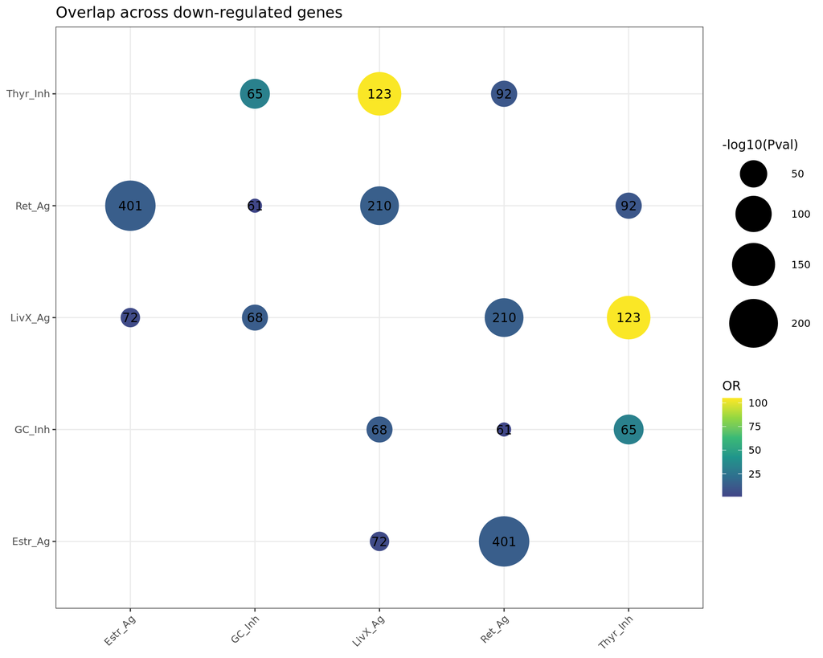

```r
Dot <- ggplot(ResSel, aes(DEGs, KBase, label=Numbers)) +
  geom_point(aes(size=-log10(Pval), col=OR)) +
  geom_text() +
  scale_size_continuous(range=c(2, 20), limits=c(2, round(-log10(min(ResSel$Pval)) + 0.5))) +
  scale_color_viridis_c(limits=c(1, round(max(ResSel$OR)+1)), begin=0.2) + xlab('') + ylab('') +
  theme_bw() +
  theme(axis.line = element_blank(), axis.title = element_blank(),
        axis.text.x = element_text(angle = 45, hjust = 1)) +
    ggtitle('Overlap across down-regulated genes')

Dot
```

```r
ggsave(Dot, filename=paste0(OutputFolder, 'DotPlot_DownReg.pdf'), width=8, height=8)
```

## 6.3 Visualize overlap results selectively for retinoic, liverX, estrogen, thyroid

### Selection

```r
Path <- c('Thyr_Ag', 'Thyr_Inh', 'Ret_Ag', 'Ret_Inh', 'Estr_Ag', 'LivX_Ag', 'LivX_Inh')
ResPath <- ResSel[ResSel$DEGs %in% Path & ResSel$KBase %in% Path, ]

ResPath
##        DEGs    KBase         OR          Pval Numbers
## 1    Ret_Ag Thyr_Inh  10.041608  1.296458e-45      92
## 3   LivX_Ag Thyr_Inh 104.389398 1.464476e-154     123
## 4  Thyr_Inh   Ret_Ag  10.041608  1.296458e-45      92
## 5   Estr_Ag   Ret_Ag  13.683285 1.370389e-215     401
## 7   LivX_Ag   Ret_Ag  13.934977 6.406226e-118     210
## 8    Ret_Ag  Estr_Ag  13.683285 1.370389e-215     401
## 9   LivX_Ag  Estr_Ag   4.387377  3.359345e-21      72
## 13 Thyr_Inh  LivX_Ag 104.389398 1.464476e-154     123
## 14   Ret_Ag  LivX_Ag  13.934977 6.406226e-118     210
## 15  Estr_Ag  LivX_Ag   4.387377  3.359345e-21      72
```

### DotPlot: visualization

```r
cols <- viridis::cividis(100)[1:80]
ResPath <- dplyr::filter(ResPath, OR > 2) %>% dplyr::filter(Numbers > 25)
min(ResPath$Pval)
```

```
## [1] 1.370389e-215
```

```r
max(ResPath$OR)
```

```
## [1] 104.3894
```

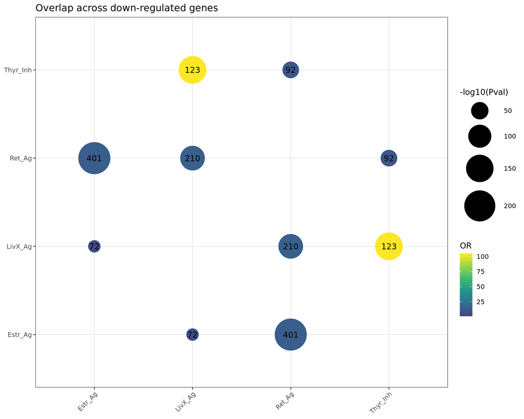

```r
Dot <- ggplot(ResPath, aes(DEGs, KBase, label=Numbers)) +
  geom_point(aes(size=-log10(Pval), col=OR)) +
  geom_text() +
  scale_size_continuous(range=c(2, 20), limits=c(2, round(-log10(min(ResSel$Pval)) + 0.5))) +
  scale_color_viridis_c(limits=c(1, round(max(ResSel$OR)+1)), begin=0.2) + xlab('') + ylab('') +
  theme_bw() +
  theme(axis.line = element_blank(), axis.title = element_blank(),
        axis.text.x = element_text(angle = 45, hjust = 1))+
  ggtitle('Overlap across down-regulated genes')


Dot
```

```r
ggsave(Dot, filename=paste0(OutputFolder, 'DotPlot_DownReg_Selected.pdf'), width=8, height=8)
```

# 7. Comparison across pathways: Agonist versus Inhibitor analysis

## 7.1 Perform Overlap

```r
DEGs_AgvsInh <- list(

  Thyr_AgvsInh_Up= row.names(DEA$Thyr$AgvsInh$DEGs[DEA$Thyr$AgvsInh$DEGs$log2FoldChange > 0, ]),
  Thyr_AgvsInh_Down= row.names(DEA$Thyr$AgvsInh$DEGs[DEA$Thyr$AgvsInh$DEGs$log2FoldChange < 0, ]),

  Ret_AgvsInh_Up= row.names(DEA$Ret$AgvsInh$DEGs[DEA$Ret$AgvsInh$DEGs$log2FoldChange > 0, ]),
  Ret_AgvsInh_Down= row.names(DEA$Ret$AgvsInh$DEGs[DEA$Ret$AgvsInh$DEGs$log2FoldChange < 0, ]),

  Estr_AgvsInh_Up= row.names(DEA$Estr$AgvsInh$DEGs[DEA$Estr$AgvsInh$DEGs$log2FoldChange > 0, ]),
  Estr_AgvsInh_Down= row.names(DEA$Estr$AgvsInh$DEGs[DEA$Estr$AgvsInh$DEGs$log2FoldChange < 0, ]),

  Andr_AgvsInh_Up= row.names(DEA$Andr$AgvsInh$DEGs[DEA$Andr$AgvsInh$DEGs$log2FoldChange > 0, ]),
  Andr_AgvsInh_Down= row.names(DEA$Andr$AgvsInh$DEGs[DEA$Andr$AgvsInh$DEGs$log2FoldChange < 0, ]),

  GC_AgvsInh_Up= row.names(DEA$GC$AgvsInh$DEGs[DEA$GC$AgvsInh$DEGs$log2FoldChange > 0, ]),
  GC_AgvsInh_Down= row.names(DEA$GC$AgvsInh$DEGs[DEA$GC$AgvsInh$DEGs$log2FoldChange < 0, ]),

  LivX_AgvsInh_Up= row.names(DEA$LivX$AgvsInh$DEGs[DEA$LivX$AgvsInh$DEGs$log2FoldChange > 0, ]),
  LivX_AgvsInh_Down= row.names(DEA$LivX$AgvsInh$DEGs[DEA$LivX$AgvsInh$DEGs$log2FoldChange < 0, ]),

  AhHyd_AgvsInh_Up= row.names(DEA$AhHyd$AgvsInh$DEGs[DEA$AhHyd$AgvsInh$DEGs$log2FoldChange > 0, ]),
  AhHyd_AgvsInh_Down= row.names(DEA$AhHyd$AgvsInh$DEGs[DEA$AhHyd$AgvsInh$DEGs$log2FoldChange < 0, ])

            )
```

```r
Universe <- row.names(DEA$Ret$Agonist$Res) %>% unique()
length(Universe)
## [1] 14850
```

```r
OvObj <- newGOM(DEGs_AgvsInh, DEGs_AgvsInh, genome.size=length(Universe))
#print(OvObj)
```

```r
getMatrix(OvObj, name='intersection')
##                    Thyr_AgvsInh_Up Thyr_AgvsInh_Down Ret_AgvsInh_Up
## Thyr_AgvsInh_Up                155                 0             10
## Thyr_AgvsInh_Down                0               239             40
## Ret_AgvsInh_Up                  10                40           1463
## Ret_AgvsInh_Down                38                 3              0
## Estr_AgvsInh_Up                  0                 0              0
## Estr_AgvsInh_Down                0                 0              0
## Andr_AgvsInh_Up                  0                 1              8
## Andr_AgvsInh_Down                1                 0              1
## GC_AgvsInh_Up                   70                 0             44
## GC_AgvsInh_Down                  0                36             18
## LivX_AgvsInh_Up                  0                38            346
## LivX_AgvsInh_Down               35                 0              0
## AhHyd_AgvsInh_Up                16                 0              0
## AhHyd_AgvsInh_Down               0                14            147
##                    Ret_AgvsInh_Down Estr_AgvsInh_Up Estr_AgvsInh_Down
## Thyr_AgvsInh_Up                  38               0                 0
## Thyr_AgvsInh_Down                 3               0                 0
## Ret_AgvsInh_Up                    0               0                 0
## Ret_AgvsInh_Down                962               0                 0
## Estr_AgvsInh_Up                   0               0                 0
## Estr_AgvsInh_Down                 0               0                 0
## Andr_AgvsInh_Up                   0               0                 0
## Andr_AgvsInh_Down                 6               0                 0
## GC_AgvsInh_Up                    36               0                 0
## GC_AgvsInh_Down                   0               0                 0
## LivX_AgvsInh_Up                   1               0                 0
## LivX_AgvsInh_Down               115               0                 0
## AhHyd_AgvsInh_Up                 16               0                 0
## AhHyd_AgvsInh_Down                1               0                 0
##                    Andr_AgvsInh_Up Andr_AgvsInh_Down GC_AgvsInh_Up
## Thyr_AgvsInh_Up                  0                 1            70
## Thyr_AgvsInh_Down                1                 0             0
## Ret_AgvsInh_Up                   8                 1            44
## Ret_AgvsInh_Down                 0                 6            36
## Estr_AgvsInh_Up                  0                 0             0
## Estr_AgvsInh_Down                0                 0             0
## Andr_AgvsInh_Up                 12                 0             0
## Andr_AgvsInh_Down                0                11             1
## GC_AgvsInh_Up                    0                 1           244
## GC_AgvsInh_Down                  0                 0             0
## LivX_AgvsInh_Up                  5                 1            14
## LivX_AgvsInh_Down                0                 2            28
## AhHyd_AgvsInh_Up                 0                 1            15
## AhHyd_AgvsInh_Down               3                 0             1
##                    GC_AgvsInh_Down LivX_AgvsInh_Up LivX_AgvsInh_Down
## Thyr_AgvsInh_Up                  0               0                35
## Thyr_AgvsInh_Down               36              38                 0
## Ret_AgvsInh_Up                  18             346                 0
## Ret_AgvsInh_Down                 0               1               115
## Estr_AgvsInh_Up                  0               0                 0
## Estr_AgvsInh_Down                0               0                 0
## Andr_AgvsInh_Up                  0               5                 0
## Andr_AgvsInh_Down                0               1                 2
## GC_AgvsInh_Up                    0              14                28
## GC_AgvsInh_Down                 56              14                 1
## LivX_AgvsInh_Up                 14             440                 0
## LivX_AgvsInh_Down                1               0               174
## AhHyd_AgvsInh_Up                 0               1                14
## AhHyd_AgvsInh_Down              11             101                 0
##                    AhHyd_AgvsInh_Up AhHyd_AgvsInh_Down
## Thyr_AgvsInh_Up                  16                  0
## Thyr_AgvsInh_Down                 0                 14
## Ret_AgvsInh_Up                    0                147
## Ret_AgvsInh_Down                 16                  1
## Estr_AgvsInh_Up                   0                  0
## Estr_AgvsInh_Down                 0                  0
## Andr_AgvsInh_Up                   0                  3
## Andr_AgvsInh_Down                 1                  0
## GC_AgvsInh_Up                    15                  1
## GC_AgvsInh_Down                   0                 11
## LivX_AgvsInh_Up                   1                101
## LivX_AgvsInh_Down                14                  0
## AhHyd_AgvsInh_Up                 43                  0
## AhHyd_AgvsInh_Down                0                243
```

```r
getMatrix(OvObj, name='pval')
##                    Thyr_AgvsInh_Up Thyr_AgvsInh_Down Ret_AgvsInh_Up
## Thyr_AgvsInh_Up       0.000000e+00      1.000000e+00   9.483314e-01
## Thyr_AgvsInh_Down     1.000000e+00      0.000000e+00   5.862014e-04
## Ret_AgvsInh_Up        9.483314e-01      5.862014e-04   0.000000e+00
## Ret_AgvsInh_Down      5.098246e-13      9.999845e-01   1.000000e+00
## Estr_AgvsInh_Up       1.000000e+00      1.000000e+00   1.000000e+00
## Estr_AgvsInh_Down     1.000000e+00      1.000000e+00   1.000000e+00
## Andr_AgvsInh_Up       1.000000e+00      1.769803e-01   3.000147e-06
## Andr_AgvsInh_Down     1.090414e-01      1.000000e+00   6.805896e-01
## GC_AgvsInh_Up         1.288494e-85      1.000000e+00   5.570130e-05
## GC_AgvsInh_Down       1.000000e+00      1.074168e-51   3.792900e-06
## LivX_AgvsInh_Up       1.000000e+00      1.555239e-17  5.369891e-272
## LivX_AgvsInh_Down     1.560632e-35      1.000000e+00   1.000000e+00
## AhHyd_AgvsInh_Up      1.874095e-21      1.000000e+00   1.000000e+00
## AhHyd_AgvsInh_Down    1.000000e+00      4.016461e-05   4.985116e-86
##                    Ret_AgvsInh_Down Estr_AgvsInh_Up Estr_AgvsInh_Down
## Thyr_AgvsInh_Up        5.098246e-13               1                 1
## Thyr_AgvsInh_Down      9.999845e-01               1                 1
## Ret_AgvsInh_Up         1.000000e+00               1                 1
## Ret_AgvsInh_Down       0.000000e+00               1                 1
## Estr_AgvsInh_Up        1.000000e+00               1                 1
## Estr_AgvsInh_Down      1.000000e+00               1                 1
## Andr_AgvsInh_Up        1.000000e+00               1                 1
## Andr_AgvsInh_Down      2.535003e-05               1                 1
## GC_AgvsInh_Up          2.937147e-06               1                 1
## GC_AgvsInh_Down        1.000000e+00               1                 1
## LivX_AgvsInh_Up        1.000000e+00               1                 1
## LivX_AgvsInh_Down      1.312420e-94               1                 1
## AhHyd_AgvsInh_Up       4.281741e-09               1                 1
## AhHyd_AgvsInh_Down     9.999999e-01               1                 1
##                    Andr_AgvsInh_Up Andr_AgvsInh_Down GC_AgvsInh_Up
## Thyr_AgvsInh_Up       1.000000e+00      1.090414e-01  1.288494e-85
## Thyr_AgvsInh_Down     1.769803e-01      1.000000e+00  1.000000e+00
## Ret_AgvsInh_Up        3.000147e-06      6.805896e-01  5.570130e-05
## Ret_AgvsInh_Down      1.000000e+00      2.535003e-05  2.937147e-06
## Estr_AgvsInh_Up       1.000000e+00      1.000000e+00  1.000000e+00
## Estr_AgvsInh_Down     1.000000e+00      1.000000e+00  1.000000e+00
## Andr_AgvsInh_Up       4.183601e-42      1.000000e+00  1.000000e+00
## Andr_AgvsInh_Down     1.000000e+00      5.173371e-39  1.666520e-01
## GC_AgvsInh_Up         1.000000e+00      1.666520e-01  0.000000e+00
## GC_AgvsInh_Down       1.000000e+00      1.000000e+00  1.000000e+00
## LivX_AgvsInh_Up       1.488468e-05      2.817698e-01  1.419070e-02
## LivX_AgvsInh_Down     1.000000e+00      7.003976e-03  5.036623e-20
## AhHyd_AgvsInh_Up      1.000000e+00      3.140510e-02  1.123432e-16
## AhHyd_AgvsInh_Down    8.535732e-04      1.000000e+00  9.827396e-01
##                    GC_AgvsInh_Down LivX_AgvsInh_Up LivX_AgvsInh_Down
## Thyr_AgvsInh_Up       1.000000e+00    1.000000e+00      1.560632e-35
## Thyr_AgvsInh_Down     1.074168e-51    1.555239e-17      1.000000e+00
## Ret_AgvsInh_Up        3.792900e-06   5.369891e-272      1.000000e+00
## Ret_AgvsInh_Down      1.000000e+00    1.000000e+00      1.312420e-94
## Estr_AgvsInh_Up       1.000000e+00    1.000000e+00      1.000000e+00
## Estr_AgvsInh_Down     1.000000e+00    1.000000e+00      1.000000e+00
## Andr_AgvsInh_Up       1.000000e+00    1.488468e-05      1.000000e+00
## Andr_AgvsInh_Down     1.000000e+00    2.817698e-01      7.003976e-03
## GC_AgvsInh_Up         1.000000e+00    1.419070e-02      5.036623e-20
## GC_AgvsInh_Down      1.906696e-159    6.095751e-10      4.838040e-01
## LivX_AgvsInh_Up       6.095751e-10    0.000000e+00      1.000000e+00
## LivX_AgvsInh_Down     4.838040e-01    1.000000e+00      0.000000e+00
## AhHyd_AgvsInh_Up      1.000000e+00    7.261544e-01      3.160036e-17
## AhHyd_AgvsInh_Down    1.398295e-09    2.029891e-91      1.000000e+00
##                    AhHyd_AgvsInh_Up AhHyd_AgvsInh_Down
## Thyr_AgvsInh_Up        1.874095e-21       1.000000e+00
## Thyr_AgvsInh_Down      1.000000e+00       4.016461e-05
## Ret_AgvsInh_Up         1.000000e+00       4.985116e-86
## Ret_AgvsInh_Down       4.281741e-09       9.999999e-01
## Estr_AgvsInh_Up        1.000000e+00       1.000000e+00
## Estr_AgvsInh_Down      1.000000e+00       1.000000e+00
## Andr_AgvsInh_Up        1.000000e+00       8.535732e-04
## Andr_AgvsInh_Down      3.140510e-02       1.000000e+00
## GC_AgvsInh_Up          1.123432e-16       9.827396e-01
## GC_AgvsInh_Down        1.000000e+00       1.398295e-09
## LivX_AgvsInh_Up        7.261544e-01       2.029891e-91
## LivX_AgvsInh_Down      3.160036e-17       1.000000e+00
## AhHyd_AgvsInh_Up      2.650593e-127       1.000000e+00
## AhHyd_AgvsInh_Down     1.000000e+00       0.000000e+00
```

```r
getMatrix(OvObj, name='odds.ratio')
##                    Thyr_AgvsInh_Up Thyr_AgvsInh_Down Ret_AgvsInh_Up
## Thyr_AgvsInh_Up                Inf         0.0000000      0.6285378
## Thyr_AgvsInh_Down        0.0000000               Inf      1.8626848
## Ret_AgvsInh_Up           0.6285378         1.8626848            Inf
## Ret_AgvsInh_Down         4.8395743         0.1809725      0.0000000
## Estr_AgvsInh_Up          0.0000000         0.0000000      0.0000000
## Estr_AgvsInh_Down        0.0000000         0.0000000      0.0000000
## Andr_AgvsInh_Up          0.0000000         5.5758129     18.3879551
## Andr_AgvsInh_Down        9.5312421         0.0000000      0.9149788
## GC_AgvsInh_Up           68.5649151         0.0000000      2.0443793
## GC_AgvsInh_Down          0.0000000       128.8985340      4.3754294
## LivX_AgvsInh_Up          0.0000000         6.6801855     43.7703727
## LivX_AgvsInh_Down       30.5073190         0.0000000      0.0000000
## AhHyd_AgvsInh_Up        62.2864885         0.0000000      0.0000000
## AhHyd_AgvsInh_Down       0.0000000         3.9071002     15.4574042
##                    Ret_AgvsInh_Down Estr_AgvsInh_Up Estr_AgvsInh_Down
## Thyr_AgvsInh_Up          4.83957434               0                 0
## Thyr_AgvsInh_Down        0.18097249               0                 0
## Ret_AgvsInh_Up           0.00000000               0                 0
## Ret_AgvsInh_Down                Inf               0                 0
## Estr_AgvsInh_Up          0.00000000               0                 0
## Estr_AgvsInh_Down        0.00000000               0                 0
## Andr_AgvsInh_Up          0.00000000               0                 0
## Andr_AgvsInh_Down       17.41680530               0                 0
## GC_AgvsInh_Up            2.55664703               0                 0
## GC_AgvsInh_Down          0.00000000               0                 0
## LivX_AgvsInh_Up          0.03189191               0                 0
## LivX_AgvsInh_Down       31.80114235               0                 0
## AhHyd_AgvsInh_Up         8.68074512               0                 0
## AhHyd_AgvsInh_Down       0.05870611               0                 0
##                    Andr_AgvsInh_Up Andr_AgvsInh_Down GC_AgvsInh_Up
## Thyr_AgvsInh_Up           0.000000         9.5312421    68.5649151
## Thyr_AgvsInh_Down         5.575813         0.0000000     0.0000000
## Ret_AgvsInh_Up           18.387955         0.9149788     2.0443793
## Ret_AgvsInh_Down          0.000000        17.4168053     2.5566470
## Estr_AgvsInh_Up           0.000000         0.0000000     0.0000000
## Estr_AgvsInh_Down         0.000000         0.0000000     0.0000000
## Andr_AgvsInh_Up                Inf         0.0000000     0.0000000
## Andr_AgvsInh_Down         0.000000               Inf     6.0046602
## GC_AgvsInh_Up             0.000000         6.0046602           Inf
## GC_AgvsInh_Down           0.000000         0.0000000     0.0000000
## LivX_AgvsInh_Up          23.628858         3.2796749     2.0259939
## LivX_AgvsInh_Down         0.000000        18.9258042    12.8353684
## AhHyd_AgvsInh_Up          0.000000        35.2077501    34.0487003
## AhHyd_AgvsInh_Down       20.267527         0.0000000     0.2442634
##                    GC_AgvsInh_Down LivX_AgvsInh_Up LivX_AgvsInh_Down
## Thyr_AgvsInh_Up           0.000000      0.00000000         30.507319
## Thyr_AgvsInh_Down       128.898534      6.68018550          0.000000
## Ret_AgvsInh_Up            4.375429     43.77037269          0.000000
## Ret_AgvsInh_Down          0.000000      0.03189191         31.801142
## Estr_AgvsInh_Up           0.000000      0.00000000          0.000000
## Estr_AgvsInh_Down         0.000000      0.00000000          0.000000
## Andr_AgvsInh_Up           0.000000     23.62885762          0.000000
## Andr_AgvsInh_Down         0.000000      3.27967491         18.925804
## GC_AgvsInh_Up             0.000000      2.02599393         12.835368
## GC_AgvsInh_Down                Inf     11.23510761          1.536539
## LivX_AgvsInh_Up          11.235108             Inf          0.000000
## LivX_AgvsInh_Down         1.536539      0.00000000               Inf
## AhHyd_AgvsInh_Up          0.000000      0.77927094         44.052621
## AhHyd_AgvsInh_Down       15.334561     29.90344064          0.000000
##                    AhHyd_AgvsInh_Up AhHyd_AgvsInh_Down
## Thyr_AgvsInh_Up          62.2864885         0.00000000
## Thyr_AgvsInh_Down         0.0000000         3.90710024
## Ret_AgvsInh_Up            0.0000000        15.45740424
## Ret_AgvsInh_Down          8.6807451         0.05870611
## Estr_AgvsInh_Up           0.0000000         0.00000000
## Estr_AgvsInh_Down         0.0000000         0.00000000
## Andr_AgvsInh_Up           0.0000000        20.26752689
## Andr_AgvsInh_Down        35.2077501         0.00000000
## GC_AgvsInh_Up            34.0487003         0.24426338
## GC_AgvsInh_Down           0.0000000        15.33456104
## LivX_AgvsInh_Up           0.7792709        29.90344064
## LivX_AgvsInh_Down        44.0526213         0.00000000
## AhHyd_AgvsInh_Up                Inf         0.00000000
## AhHyd_AgvsInh_Down        0.0000000                Inf
```

## 7.2 Visualize overlap results

**DotPlot: data preparation**

```r
OR <- data.frame(getMatrix(OvObj, name='odds.ratio'))
OR$DEGs <- row.names(OR)
OR <- gather(OR, 'KBase', 'OR', -DEGs)
PVAL <- data.frame(getMatrix(OvObj, name='pval'))
PVAL$DEGs <- row.names(PVAL)
PVAL <- gather(PVAL, 'KBase', 'PVal', -DEGs)
NUM <- data.frame(getMatrix(OvObj, name='intersection'))
NUM$DEGs <- row.names(NUM)
NUM <- gather(NUM, 'KBase', 'Numbers', -DEGs)
if(! identical(OR$DEGs, PVAL$DEGs)){
  stop('Inconsistecy')
}
if(! identical(OR$DEGs, NUM$DEGs)){
  stop('Inconsistecy')
}
if(! identical(OR$KBase, NUM$KBase)){
  stop('Inconsistecy')
}
if(! identical(OR$KBase, NUM$KBase)){
  stop('Inconsistecy')
}
Res <- mutate(OR, Pval=PVAL$PVal) %>% mutate(Numbers=NUM$Numbers)
Res
##                   DEGs              KBase           OR          Pval Numbers
## 1      Thyr_AgvsInh_Up    Thyr_AgvsInh_Up          Inf  0.000000e+00     155
## 2    Thyr_AgvsInh_Down    Thyr_AgvsInh_Up   0.00000000  1.000000e+00       0
## 3       Ret_AgvsInh_Up    Thyr_AgvsInh_Up   0.62853784  9.483314e-01      10
## 4     Ret_AgvsInh_Down    Thyr_AgvsInh_Up   4.83957434  5.098246e-13      38
## 5      Estr_AgvsInh_Up    Thyr_AgvsInh_Up   0.00000000  1.000000e+00       0
## 6    Estr_AgvsInh_Down    Thyr_AgvsInh_Up   0.00000000  1.000000e+00       0
## 7      Andr_AgvsInh_Up    Thyr_AgvsInh_Up   0.00000000  1.000000e+00       0
## 8    Andr_AgvsInh_Down    Thyr_AgvsInh_Up   9.53124213  1.090414e-01       1
## 9        GC_AgvsInh_Up    Thyr_AgvsInh_Up  68.56491514  1.288494e-85      70
## 10     GC_AgvsInh_Down    Thyr_AgvsInh_Up   0.00000000  1.000000e+00       0
## 11     LivX_AgvsInh_Up    Thyr_AgvsInh_Up   0.00000000  1.000000e+00       0
## 12   LivX_AgvsInh_Down    Thyr_AgvsInh_Up  30.50731902  1.560632e-35      35
## 13    AhHyd_AgvsInh_Up    Thyr_AgvsInh_Up  62.28648850  1.874095e-21      16
## 14  AhHyd_AgvsInh_Down    Thyr_AgvsInh_Up   0.00000000  1.000000e+00       0
## 15     Thyr_AgvsInh_Up  Thyr_AgvsInh_Down   0.00000000  1.000000e+00       0
## 16   Thyr_AgvsInh_Down  Thyr_AgvsInh_Down          Inf  0.000000e+00     239
## 17      Ret_AgvsInh_Up  Thyr_AgvsInh_Down   1.86268484  5.862014e-04      40
## 18    Ret_AgvsInh_Down  Thyr_AgvsInh_Down   0.18097249  9.999845e-01       3
## 19     Estr_AgvsInh_Up  Thyr_AgvsInh_Down   0.00000000  1.000000e+00       0
## 20   Estr_AgvsInh_Down  Thyr_AgvsInh_Down   0.00000000  1.000000e+00       0
## 21     Andr_AgvsInh_Up  Thyr_AgvsInh_Down   5.57581291  1.769803e-01       1
## 22   Andr_AgvsInh_Down  Thyr_AgvsInh_Down   0.00000000  1.000000e+00       0
## 23       GC_AgvsInh_Up  Thyr_AgvsInh_Down   0.00000000  1.000000e+00       0
## 24     GC_AgvsInh_Down  Thyr_AgvsInh_Down 128.89853403  1.074168e-51      36
## 25     LivX_AgvsInh_Up  Thyr_AgvsInh_Down   6.68018550  1.555239e-17      38
## 26   LivX_AgvsInh_Down  Thyr_AgvsInh_Down   0.00000000  1.000000e+00       0
## 27    AhHyd_AgvsInh_Up  Thyr_AgvsInh_Down   0.00000000  1.000000e+00       0
## 28  AhHyd_AgvsInh_Down  Thyr_AgvsInh_Down   3.90710024  4.016461e-05      14
## 29     Thyr_AgvsInh_Up     Ret_AgvsInh_Up   0.62853784  9.483314e-01      10
## 30   Thyr_AgvsInh_Down     Ret_AgvsInh_Up   1.86268484  5.862014e-04      40
## 31      Ret_AgvsInh_Up     Ret_AgvsInh_Up          Inf  0.000000e+00    1463
## 32    Ret_AgvsInh_Down     Ret_AgvsInh_Up   0.00000000  1.000000e+00       0
## 33     Estr_AgvsInh_Up     Ret_AgvsInh_Up   0.00000000  1.000000e+00       0
## 34   Estr_AgvsInh_Down     Ret_AgvsInh_Up   0.00000000  1.000000e+00       0
## 35     Andr_AgvsInh_Up     Ret_AgvsInh_Up  18.38795511  3.000147e-06       8
## 36   Andr_AgvsInh_Down     Ret_AgvsInh_Up   0.91497876  6.805896e-01       1
## 37       GC_AgvsInh_Up     Ret_AgvsInh_Up   2.04437933  5.570130e-05      44
## 38     GC_AgvsInh_Down     Ret_AgvsInh_Up   4.37542936  3.792900e-06      18
## 39     LivX_AgvsInh_Up     Ret_AgvsInh_Up  43.77037269 5.369891e-272     346
## 40   LivX_AgvsInh_Down     Ret_AgvsInh_Up   0.00000000  1.000000e+00       0
## 41    AhHyd_AgvsInh_Up     Ret_AgvsInh_Up   0.00000000  1.000000e+00       0
## 42  AhHyd_AgvsInh_Down     Ret_AgvsInh_Up  15.45740424  4.985116e-86     147
## 43     Thyr_AgvsInh_Up   Ret_AgvsInh_Down   4.83957434  5.098246e-13      38
## 44   Thyr_AgvsInh_Down   Ret_AgvsInh_Down   0.18097249  9.999845e-01       3
## 45      Ret_AgvsInh_Up   Ret_AgvsInh_Down   0.00000000  1.000000e+00       0
## 46    Ret_AgvsInh_Down   Ret_AgvsInh_Down          Inf  0.000000e+00     962
## 47     Estr_AgvsInh_Up   Ret_AgvsInh_Down   0.00000000  1.000000e+00       0
## 48   Estr_AgvsInh_Down   Ret_AgvsInh_Down   0.00000000  1.000000e+00       0
## 49     Andr_AgvsInh_Up   Ret_AgvsInh_Down   0.00000000  1.000000e+00       0
## 50   Andr_AgvsInh_Down   Ret_AgvsInh_Down  17.41680530  2.535003e-05       6
## 51       GC_AgvsInh_Up   Ret_AgvsInh_Down   2.55664703  2.937147e-06      36
## 52     GC_AgvsInh_Down   Ret_AgvsInh_Down   0.00000000  1.000000e+00       0
## 53     LivX_AgvsInh_Up   Ret_AgvsInh_Down   0.03189191  1.000000e+00       1
## 54   LivX_AgvsInh_Down   Ret_AgvsInh_Down  31.80114235  1.312420e-94     115
## 55    AhHyd_AgvsInh_Up   Ret_AgvsInh_Down   8.68074512  4.281741e-09      16
## 56  AhHyd_AgvsInh_Down   Ret_AgvsInh_Down   0.05870611  9.999999e-01       1
## 57     Thyr_AgvsInh_Up    Estr_AgvsInh_Up   0.00000000  1.000000e+00       0
## 58   Thyr_AgvsInh_Down    Estr_AgvsInh_Up   0.00000000  1.000000e+00       0
## 59      Ret_AgvsInh_Up    Estr_AgvsInh_Up   0.00000000  1.000000e+00       0
## 60    Ret_AgvsInh_Down    Estr_AgvsInh_Up   0.00000000  1.000000e+00       0
## 61     Estr_AgvsInh_Up    Estr_AgvsInh_Up   0.00000000  1.000000e+00       0
## 62   Estr_AgvsInh_Down    Estr_AgvsInh_Up   0.00000000  1.000000e+00       0
## 63     Andr_AgvsInh_Up    Estr_AgvsInh_Up   0.00000000  1.000000e+00       0
## 64   Andr_AgvsInh_Down    Estr_AgvsInh_Up   0.00000000  1.000000e+00       0
## 65       GC_AgvsInh_Up    Estr_AgvsInh_Up   0.00000000  1.000000e+00       0
## 66     GC_AgvsInh_Down    Estr_AgvsInh_Up   0.00000000  1.000000e+00       0
## 67     LivX_AgvsInh_Up    Estr_AgvsInh_Up   0.00000000  1.000000e+00       0
## 68   LivX_AgvsInh_Down    Estr_AgvsInh_Up   0.00000000  1.000000e+00       0
## 69    AhHyd_AgvsInh_Up    Estr_AgvsInh_Up   0.00000000  1.000000e+00       0
## 70  AhHyd_AgvsInh_Down    Estr_AgvsInh_Up   0.00000000  1.000000e+00       0
## 71     Thyr_AgvsInh_Up  Estr_AgvsInh_Down   0.00000000  1.000000e+00       0
## 72   Thyr_AgvsInh_Down  Estr_AgvsInh_Down   0.00000000  1.000000e+00       0
## 73      Ret_AgvsInh_Up  Estr_AgvsInh_Down   0.00000000  1.000000e+00       0
## 74    Ret_AgvsInh_Down  Estr_AgvsInh_Down   0.00000000  1.000000e+00       0
## 75     Estr_AgvsInh_Up  Estr_AgvsInh_Down   0.00000000  1.000000e+00       0
## 76   Estr_AgvsInh_Down  Estr_AgvsInh_Down   0.00000000  1.000000e+00       0
## 77     Andr_AgvsInh_Up  Estr_AgvsInh_Down   0.00000000  1.000000e+00       0
## 78   Andr_AgvsInh_Down  Estr_AgvsInh_Down   0.00000000  1.000000e+00       0
## 79       GC_AgvsInh_Up  Estr_AgvsInh_Down   0.00000000  1.000000e+00       0
## 80     GC_AgvsInh_Down  Estr_AgvsInh_Down   0.00000000  1.000000e+00       0
## 81     LivX_AgvsInh_Up  Estr_AgvsInh_Down   0.00000000  1.000000e+00       0
## 82   LivX_AgvsInh_Down  Estr_AgvsInh_Down   0.00000000  1.000000e+00       0
## 83    AhHyd_AgvsInh_Up  Estr_AgvsInh_Down   0.00000000  1.000000e+00       0
## 84  AhHyd_AgvsInh_Down  Estr_AgvsInh_Down   0.00000000  1.000000e+00       0
## 85     Thyr_AgvsInh_Up    Andr_AgvsInh_Up   0.00000000  1.000000e+00       0
## 86   Thyr_AgvsInh_Down    Andr_AgvsInh_Up   5.57581291  1.769803e-01       1
## 87      Ret_AgvsInh_Up    Andr_AgvsInh_Up  18.38795511  3.000147e-06       8
## 88    Ret_AgvsInh_Down    Andr_AgvsInh_Up   0.00000000  1.000000e+00       0
## 89     Estr_AgvsInh_Up    Andr_AgvsInh_Up   0.00000000  1.000000e+00       0
## 90   Estr_AgvsInh_Down    Andr_AgvsInh_Up   0.00000000  1.000000e+00       0
## 91     Andr_AgvsInh_Up    Andr_AgvsInh_Up          Inf  4.183601e-42      12
## 92   Andr_AgvsInh_Down    Andr_AgvsInh_Up   0.00000000  1.000000e+00       0
## 93       GC_AgvsInh_Up    Andr_AgvsInh_Up   0.00000000  1.000000e+00       0
## 94     GC_AgvsInh_Down    Andr_AgvsInh_Up   0.00000000  1.000000e+00       0
## 95     LivX_AgvsInh_Up    Andr_AgvsInh_Up  23.62885762  1.488468e-05       5
## 96   LivX_AgvsInh_Down    Andr_AgvsInh_Up   0.00000000  1.000000e+00       0
## 97    AhHyd_AgvsInh_Up    Andr_AgvsInh_Up   0.00000000  1.000000e+00       0
## 98  AhHyd_AgvsInh_Down    Andr_AgvsInh_Up  20.26752689  8.535732e-04       3
## 99     Thyr_AgvsInh_Up  Andr_AgvsInh_Down   9.53124213  1.090414e-01       1
## 100  Thyr_AgvsInh_Down  Andr_AgvsInh_Down   0.00000000  1.000000e+00       0
## 101     Ret_AgvsInh_Up  Andr_AgvsInh_Down   0.91497876  6.805896e-01       1
## 102   Ret_AgvsInh_Down  Andr_AgvsInh_Down  17.41680530  2.535003e-05       6
## 103    Estr_AgvsInh_Up  Andr_AgvsInh_Down   0.00000000  1.000000e+00       0
## 104  Estr_AgvsInh_Down  Andr_AgvsInh_Down   0.00000000  1.000000e+00       0
## 105    Andr_AgvsInh_Up  Andr_AgvsInh_Down   0.00000000  1.000000e+00       0
## 106  Andr_AgvsInh_Down  Andr_AgvsInh_Down          Inf  5.173371e-39      11
## 107      GC_AgvsInh_Up  Andr_AgvsInh_Down   6.00466024  1.666520e-01       1
## 108    GC_AgvsInh_Down  Andr_AgvsInh_Down   0.00000000  1.000000e+00       0
## 109    LivX_AgvsInh_Up  Andr_AgvsInh_Down   3.27967491  2.817698e-01       1
## 110  LivX_AgvsInh_Down  Andr_AgvsInh_Down  18.92580425  7.003976e-03       2
## 111   AhHyd_AgvsInh_Up  Andr_AgvsInh_Down  35.20775010  3.140510e-02       1
## 112 AhHyd_AgvsInh_Down  Andr_AgvsInh_Down   0.00000000  1.000000e+00       0
## 113    Thyr_AgvsInh_Up      GC_AgvsInh_Up  68.56491514  1.288494e-85      70
## 114  Thyr_AgvsInh_Down      GC_AgvsInh_Up   0.00000000  1.000000e+00       0
## 115     Ret_AgvsInh_Up      GC_AgvsInh_Up   2.04437933  5.570130e-05      44
## 116   Ret_AgvsInh_Down      GC_AgvsInh_Up   2.55664703  2.937147e-06      36
## 117    Estr_AgvsInh_Up      GC_AgvsInh_Up   0.00000000  1.000000e+00       0
## 118  Estr_AgvsInh_Down      GC_AgvsInh_Up   0.00000000  1.000000e+00       0
## 119    Andr_AgvsInh_Up      GC_AgvsInh_Up   0.00000000  1.000000e+00       0
## 120  Andr_AgvsInh_Down      GC_AgvsInh_Up   6.00466024  1.666520e-01       1
## 121      GC_AgvsInh_Up      GC_AgvsInh_Up          Inf  0.000000e+00     244
## 122    GC_AgvsInh_Down      GC_AgvsInh_Up   0.00000000  1.000000e+00       0
## 123    LivX_AgvsInh_Up      GC_AgvsInh_Up   2.02599393  1.419070e-02      14
## 124  LivX_AgvsInh_Down      GC_AgvsInh_Up  12.83536838  5.036623e-20      28
## 125   AhHyd_AgvsInh_Up      GC_AgvsInh_Up  34.04870032  1.123432e-16      15
## 126 AhHyd_AgvsInh_Down      GC_AgvsInh_Up   0.24426338  9.827396e-01       1
## 127    Thyr_AgvsInh_Up    GC_AgvsInh_Down   0.00000000  1.000000e+00       0
## 128  Thyr_AgvsInh_Down    GC_AgvsInh_Down 128.89853403  1.074168e-51      36
## 129     Ret_AgvsInh_Up    GC_AgvsInh_Down   4.37542936  3.792900e-06      18
## 130   Ret_AgvsInh_Down    GC_AgvsInh_Down   0.00000000  1.000000e+00       0
## 131    Estr_AgvsInh_Up    GC_AgvsInh_Down   0.00000000  1.000000e+00       0
## 132  Estr_AgvsInh_Down    GC_AgvsInh_Down   0.00000000  1.000000e+00       0
## 133    Andr_AgvsInh_Up    GC_AgvsInh_Down   0.00000000  1.000000e+00       0
## 134  Andr_AgvsInh_Down    GC_AgvsInh_Down   0.00000000  1.000000e+00       0
## 135      GC_AgvsInh_Up    GC_AgvsInh_Down   0.00000000  1.000000e+00       0
## 136    GC_AgvsInh_Down    GC_AgvsInh_Down          Inf 1.906696e-159      56
## 137    LivX_AgvsInh_Up    GC_AgvsInh_Down  11.23510761  6.095751e-10      14
## 138  LivX_AgvsInh_Down    GC_AgvsInh_Down   1.53653872  4.838040e-01       1
## 139   AhHyd_AgvsInh_Up    GC_AgvsInh_Down   0.00000000  1.000000e+00       0
## 140 AhHyd_AgvsInh_Down    GC_AgvsInh_Down  15.33456104  1.398295e-09      11
## 141    Thyr_AgvsInh_Up    LivX_AgvsInh_Up   0.00000000  1.000000e+00       0
```

```r
## 142  Thyr_AgvsInh_Down    LivX_AgvsInh_Up   6.68018550  1.555239e-17      38
## 143     Ret_AgvsInh_Up    LivX_AgvsInh_Up  43.77037269 5.369891e-272     346
## 144   Ret_AgvsInh_Down    LivX_AgvsInh_Up   0.03189191  1.000000e+00       1
## 145    Estr_AgvsInh_Up    LivX_AgvsInh_Up   0.00000000  1.000000e+00       0
## 146  Estr_AgvsInh_Down    LivX_AgvsInh_Up   0.00000000  1.000000e+00       0
## 147    Andr_AgvsInh_Up    LivX_AgvsInh_Up  23.62885762  1.488468e-05       5
## 148  Andr_AgvsInh_Down    LivX_AgvsInh_Up   3.27967491  2.817698e-01       1
## 149      GC_AgvsInh_Up    LivX_AgvsInh_Up   2.02599393  1.419070e-02      14
## 150    GC_AgvsInh_Down    LivX_AgvsInh_Up  11.23510761  6.095751e-10      14
## 151    LivX_AgvsInh_Up    LivX_AgvsInh_Up          Inf  0.000000e+00     440
## 152  LivX_AgvsInh_Down    LivX_AgvsInh_Up   0.00000000  1.000000e+00       0
## 153   AhHyd_AgvsInh_Up    LivX_AgvsInh_Up   0.77927094  7.261544e-01       1
## 154 AhHyd_AgvsInh_Down    LivX_AgvsInh_Up  29.90344064  2.029891e-91     101
## 155    Thyr_AgvsInh_Up  LivX_AgvsInh_Down  30.50731902  1.560632e-35      35
## 156  Thyr_AgvsInh_Down  LivX_AgvsInh_Down   0.00000000  1.000000e+00       0
## 157     Ret_AgvsInh_Up  LivX_AgvsInh_Down   0.00000000  1.000000e+00       0
## 158   Ret_AgvsInh_Down  LivX_AgvsInh_Down  31.80114235  1.312420e-94     115
## 159    Estr_AgvsInh_Up  LivX_AgvsInh_Down   0.00000000  1.000000e+00       0
## 160  Estr_AgvsInh_Down  LivX_AgvsInh_Down   0.00000000  1.000000e+00       0
## 161    Andr_AgvsInh_Up  LivX_AgvsInh_Down   0.00000000  1.000000e+00       0
## 162  Andr_AgvsInh_Down  LivX_AgvsInh_Down  18.92580425  7.003976e-03       2
## 163      GC_AgvsInh_Up  LivX_AgvsInh_Down  12.83536838  5.036623e-20      28
## 164    GC_AgvsInh_Down  LivX_AgvsInh_Down   1.53653872  4.838040e-01       1
## 165    LivX_AgvsInh_Up  LivX_AgvsInh_Down   0.00000000  1.000000e+00       0
## 166  LivX_AgvsInh_Down  LivX_AgvsInh_Down          Inf  0.000000e+00     174
## 167   AhHyd_AgvsInh_Up  LivX_AgvsInh_Down  44.05262135  3.160036e-17      14
## 168 AhHyd_AgvsInh_Down  LivX_AgvsInh_Down   0.00000000  1.000000e+00       0
## 169    Thyr_AgvsInh_Up   AhHyd_AgvsInh_Up  62.28648850  1.874095e-21      16
## 170  Thyr_AgvsInh_Down   AhHyd_AgvsInh_Up   0.00000000  1.000000e+00       0
## 171     Ret_AgvsInh_Up   AhHyd_AgvsInh_Up   0.00000000  1.000000e+00       0
## 172   Ret_AgvsInh_Down   AhHyd_AgvsInh_Up   8.68074512  4.281741e-09      16
## 173    Estr_AgvsInh_Up   AhHyd_AgvsInh_Up   0.00000000  1.000000e+00       0
## 174  Estr_AgvsInh_Down   AhHyd_AgvsInh_Up   0.00000000  1.000000e+00       0
## 175    Andr_AgvsInh_Up   AhHyd_AgvsInh_Up   0.00000000  1.000000e+00       0
## 176  Andr_AgvsInh_Down   AhHyd_AgvsInh_Up  35.20775010  3.140510e-02       1
## 177      GC_AgvsInh_Up   AhHyd_AgvsInh_Up  34.04870032  1.123432e-16      15
## 178    GC_AgvsInh_Down   AhHyd_AgvsInh_Up   0.00000000  1.000000e+00       0
## 179    LivX_AgvsInh_Up   AhHyd_AgvsInh_Up   0.77927094  7.261544e-01       1
## 180  LivX_AgvsInh_Down   AhHyd_AgvsInh_Up  44.05262135  3.160036e-17      14
## 181   AhHyd_AgvsInh_Up   AhHyd_AgvsInh_Up          Inf 2.650593e-127      43
## 182 AhHyd_AgvsInh_Down   AhHyd_AgvsInh_Up   0.00000000  1.000000e+00       0
## 183    Thyr_AgvsInh_Up AhHyd_AgvsInh_Down   0.00000000  1.000000e+00       0
## 184  Thyr_AgvsInh_Down AhHyd_AgvsInh_Down   3.90710024  4.016461e-05      14
## 185     Ret_AgvsInh_Up AhHyd_AgvsInh_Down  15.45740424  4.985116e-86     147
## 186   Ret_AgvsInh_Down AhHyd_AgvsInh_Down   0.05870611  9.999999e-01       1
## 187    Estr_AgvsInh_Up AhHyd_AgvsInh_Down   0.00000000  1.000000e+00       0
## 188  Estr_AgvsInh_Down AhHyd_AgvsInh_Down   0.00000000  1.000000e+00       0
## 189    Andr_AgvsInh_Up AhHyd_AgvsInh_Down  20.26752689  8.535732e-04       3
## 190  Andr_AgvsInh_Down AhHyd_AgvsInh_Down   0.00000000  1.000000e+00       0
## 191      GC_AgvsInh_Up AhHyd_AgvsInh_Down   0.24426338  9.827396e-01       1
## 192    GC_AgvsInh_Down AhHyd_AgvsInh_Down  15.33456104  1.398295e-09      11
## 193    LivX_AgvsInh_Up AhHyd_AgvsInh_Down  29.90344064  2.029891e-91     101
## 194  LivX_AgvsInh_Down AhHyd_AgvsInh_Down   0.00000000  1.000000e+00       0
## 195   AhHyd_AgvsInh_Up AhHyd_AgvsInh_Down   0.00000000  1.000000e+00       0
## 196 AhHyd_AgvsInh_Down AhHyd_AgvsInh_Down          Inf  0.000000e+00     243
```

```r
ResMod <- Res

ResMod[ResMod$DEGs == ResMod$KBase, ]$OR <- 1
ResMod[ResMod$DEGs == ResMod$KBase, ]$Pval <- 1

ResMod
##                   DEGs              KBase           OR          Pval Numbers
## 1      Thyr_AgvsInh_Up    Thyr_AgvsInh_Up   1.00000000  1.000000e+00     155
## 2    Thyr_AgvsInh_Down    Thyr_AgvsInh_Up   0.00000000  1.000000e+00       0
## 3       Ret_AgvsInh_Up    Thyr_AgvsInh_Up   0.62853784  9.483314e-01      10
## 4     Ret_AgvsInh_Down    Thyr_AgvsInh_Up   4.83957434  5.098246e-13      38
## 5      Estr_AgvsInh_Up    Thyr_AgvsInh_Up   0.00000000  1.000000e+00       0
## 6    Estr_AgvsInh_Down    Thyr_AgvsInh_Up   0.00000000  1.000000e+00       0
## 7      Andr_AgvsInh_Up    Thyr_AgvsInh_Up   0.00000000  1.000000e+00       0
## 8    Andr_AgvsInh_Down    Thyr_AgvsInh_Up   9.53124213  1.090414e-01       1
## 9        GC_AgvsInh_Up    Thyr_AgvsInh_Up  68.56491514  1.288494e-85      70
## 10     GC_AgvsInh_Down    Thyr_AgvsInh_Up   0.00000000  1.000000e+00       0
## 11     LivX_AgvsInh_Up    Thyr_AgvsInh_Up   0.00000000  1.000000e+00       0
## 12   LivX_AgvsInh_Down    Thyr_AgvsInh_Up  30.50731902  1.560632e-35      35
## 13    AhHyd_AgvsInh_Up    Thyr_AgvsInh_Up  62.28648850  1.874095e-21      16
## 14  AhHyd_AgvsInh_Down    Thyr_AgvsInh_Up   0.00000000  1.000000e+00       0
## 15     Thyr_AgvsInh_Up  Thyr_AgvsInh_Down   0.00000000  1.000000e+00       0
## 16   Thyr_AgvsInh_Down  Thyr_AgvsInh_Down   1.00000000  1.000000e+00     239
## 17      Ret_AgvsInh_Up  Thyr_AgvsInh_Down   1.86268484  5.862014e-04      40
## 18    Ret_AgvsInh_Down  Thyr_AgvsInh_Down   0.18097249  9.999845e-01       3
## 19     Estr_AgvsInh_Up  Thyr_AgvsInh_Down   0.00000000  1.000000e+00       0
## 20   Estr_AgvsInh_Down  Thyr_AgvsInh_Down   0.00000000  1.000000e+00       0
## 21     Andr_AgvsInh_Up  Thyr_AgvsInh_Down   5.57581291  1.769803e-01       1
## 22   Andr_AgvsInh_Down  Thyr_AgvsInh_Down   0.00000000  1.000000e+00       0
## 23       GC_AgvsInh_Up  Thyr_AgvsInh_Down   0.00000000  1.000000e+00       0
## 24     GC_AgvsInh_Down  Thyr_AgvsInh_Down 128.89853403  1.074168e-51      36
## 25     LivX_AgvsInh_Up  Thyr_AgvsInh_Down   6.68018550  1.555239e-17      38
## 26   LivX_AgvsInh_Down  Thyr_AgvsInh_Down   0.00000000  1.000000e+00       0
## 27    AhHyd_AgvsInh_Up  Thyr_AgvsInh_Down   0.00000000  1.000000e+00       0
## 28  AhHyd_AgvsInh_Down  Thyr_AgvsInh_Down   3.90710024  4.016461e-05      14
## 29     Thyr_AgvsInh_Up     Ret_AgvsInh_Up   0.62853784  9.483314e-01      10
## 30   Thyr_AgvsInh_Down     Ret_AgvsInh_Up   1.86268484  5.862014e-04      40
## 31      Ret_AgvsInh_Up     Ret_AgvsInh_Up   1.00000000  1.000000e+00    1463
## 32    Ret_AgvsInh_Down     Ret_AgvsInh_Up   0.00000000  1.000000e+00       0
## 33     Estr_AgvsInh_Up     Ret_AgvsInh_Up   0.00000000  1.000000e+00       0
## 34   Estr_AgvsInh_Down     Ret_AgvsInh_Up   0.00000000  1.000000e+00       0
## 35     Andr_AgvsInh_Up     Ret_AgvsInh_Up  18.38795511  3.000147e-06       8
## 36   Andr_AgvsInh_Down     Ret_AgvsInh_Up   0.91497876  6.805896e-01       1
## 37       GC_AgvsInh_Up     Ret_AgvsInh_Up   2.04437933  5.570130e-05      44
## 38     GC_AgvsInh_Down     Ret_AgvsInh_Up   4.37542936  3.792900e-06      18
## 39     LivX_AgvsInh_Up     Ret_AgvsInh_Up  43.77037269 5.369891e-272     346
## 40   LivX_AgvsInh_Down     Ret_AgvsInh_Up   0.00000000  1.000000e+00       0
## 41    AhHyd_AgvsInh_Up     Ret_AgvsInh_Up   0.00000000  1.000000e+00       0
## 42  AhHyd_AgvsInh_Down     Ret_AgvsInh_Up  15.45740424  4.985116e-86     147
## 43     Thyr_AgvsInh_Up   Ret_AgvsInh_Down   4.83957434  5.098246e-13      38
## 44   Thyr_AgvsInh_Down   Ret_AgvsInh_Down   0.18097249  9.999845e-01       3
## 45      Ret_AgvsInh_Up   Ret_AgvsInh_Down   0.00000000  1.000000e+00       0
## 46    Ret_AgvsInh_Down   Ret_AgvsInh_Down   1.00000000  1.000000e+00     962
## 47     Estr_AgvsInh_Up   Ret_AgvsInh_Down   0.00000000  1.000000e+00       0
## 48   Estr_AgvsInh_Down   Ret_AgvsInh_Down   0.00000000  1.000000e+00       0
## 49     Andr_AgvsInh_Up   Ret_AgvsInh_Down   0.00000000  1.000000e+00       0
## 50   Andr_AgvsInh_Down   Ret_AgvsInh_Down  17.41680530  2.535003e-05       6
## 51       GC_AgvsInh_Up   Ret_AgvsInh_Down   2.55664703  2.937147e-06      36
## 52     GC_AgvsInh_Down   Ret_AgvsInh_Down   0.00000000  1.000000e+00       0
## 53     LivX_AgvsInh_Up   Ret_AgvsInh_Down   0.03189191  1.000000e+00       1
## 54   LivX_AgvsInh_Down   Ret_AgvsInh_Down  31.80114235  1.312420e-94     115
## 55    AhHyd_AgvsInh_Up   Ret_AgvsInh_Down   8.68074512  4.281741e-09      16
## 56  AhHyd_AgvsInh_Down   Ret_AgvsInh_Down   0.05870611  9.999999e-01       1
## 57     Thyr_AgvsInh_Up    Estr_AgvsInh_Up   0.00000000  1.000000e+00       0
## 58   Thyr_AgvsInh_Down    Estr_AgvsInh_Up   0.00000000  1.000000e+00       0
## 59      Ret_AgvsInh_Up    Estr_AgvsInh_Up   0.00000000  1.000000e+00       0
## 60    Ret_AgvsInh_Down    Estr_AgvsInh_Up   0.00000000  1.000000e+00       0
## 61     Estr_AgvsInh_Up    Estr_AgvsInh_Up   1.00000000  1.000000e+00       0
## 62   Estr_AgvsInh_Down    Estr_AgvsInh_Up   0.00000000  1.000000e+00       0
## 63     Andr_AgvsInh_Up    Estr_AgvsInh_Up   0.00000000  1.000000e+00       0
## 64   Andr_AgvsInh_Down    Estr_AgvsInh_Up   0.00000000  1.000000e+00       0
## 65       GC_AgvsInh_Up    Estr_AgvsInh_Up   0.00000000  1.000000e+00       0
## 66     GC_AgvsInh_Down    Estr_AgvsInh_Up   0.00000000  1.000000e+00       0
## 67     LivX_AgvsInh_Up    Estr_AgvsInh_Up   0.00000000  1.000000e+00       0
## 68   LivX_AgvsInh_Down    Estr_AgvsInh_Up   0.00000000  1.000000e+00       0
## 69    AhHyd_AgvsInh_Up    Estr_AgvsInh_Up   0.00000000  1.000000e+00       0
## 70  AhHyd_AgvsInh_Down    Estr_AgvsInh_Up   0.00000000  1.000000e+00       0
## 71     Thyr_AgvsInh_Up  Estr_AgvsInh_Down   0.00000000  1.000000e+00       0
## 72   Thyr_AgvsInh_Down  Estr_AgvsInh_Down   0.00000000  1.000000e+00       0
## 73      Ret_AgvsInh_Up  Estr_AgvsInh_Down   0.00000000  1.000000e+00       0
## 74    Ret_AgvsInh_Down  Estr_AgvsInh_Down   0.00000000  1.000000e+00       0
## 75     Estr_AgvsInh_Up  Estr_AgvsInh_Down   0.00000000  1.000000e+00       0
## 76   Estr_AgvsInh_Down  Estr_AgvsInh_Down   1.00000000  1.000000e+00       0
## 77     Andr_AgvsInh_Up  Estr_AgvsInh_Down   0.00000000  1.000000e+00       0
## 78   Andr_AgvsInh_Down  Estr_AgvsInh_Down   0.00000000  1.000000e+00       0
## 79       GC_AgvsInh_Up  Estr_AgvsInh_Down   0.00000000  1.000000e+00       0
## 80     GC_AgvsInh_Down  Estr_AgvsInh_Down   0.00000000  1.000000e+00       0
## 81     LivX_AgvsInh_Up  Estr_AgvsInh_Down   0.00000000  1.000000e+00       0
## 82   LivX_AgvsInh_Down  Estr_AgvsInh_Down   0.00000000  1.000000e+00       0
## 83    AhHyd_AgvsInh_Up  Estr_AgvsInh_Down   0.00000000  1.000000e+00       0
## 84  AhHyd_AgvsInh_Down  Estr_AgvsInh_Down   0.00000000  1.000000e+00       0
## 85     Thyr_AgvsInh_Up    Andr_AgvsInh_Up   0.00000000  1.000000e+00       0
## 86   Thyr_AgvsInh_Down    Andr_AgvsInh_Up   5.57581291  1.769803e-01       1
## 87      Ret_AgvsInh_Up    Andr_AgvsInh_Up  18.38795511  3.000147e-06       8
## 88    Ret_AgvsInh_Down    Andr_AgvsInh_Up   0.00000000  1.000000e+00       0
## 89     Estr_AgvsInh_Up    Andr_AgvsInh_Up   0.00000000  1.000000e+00       0
## 90   Estr_AgvsInh_Down    Andr_AgvsInh_Up   0.00000000  1.000000e+00       0
## 91     Andr_AgvsInh_Up    Andr_AgvsInh_Up   1.00000000  1.000000e+00      12
## 92   Andr_AgvsInh_Down    Andr_AgvsInh_Up   0.00000000  1.000000e+00       0
## 93       GC_AgvsInh_Up    Andr_AgvsInh_Up   0.00000000  1.000000e+00       0
## 94     GC_AgvsInh_Down    Andr_AgvsInh_Up   0.00000000  1.000000e+00       0
## 95     LivX_AgvsInh_Up    Andr_AgvsInh_Up  23.62885762  1.488468e-05       5
## 96   LivX_AgvsInh_Down    Andr_AgvsInh_Up   0.00000000  1.000000e+00       0
## 97    AhHyd_AgvsInh_Up    Andr_AgvsInh_Up   0.00000000  1.000000e+00       0
## 98  AhHyd_AgvsInh_Down    Andr_AgvsInh_Up  20.26752689  8.535732e-04       3
## 99     Thyr_AgvsInh_Up  Andr_AgvsInh_Down   9.53124213  1.090414e-01       1
## 100  Thyr_AgvsInh_Down  Andr_AgvsInh_Down   0.00000000  1.000000e+00       0
## 101     Ret_AgvsInh_Up  Andr_AgvsInh_Down   0.91497876  6.805896e-01       1
## 102   Ret_AgvsInh_Down  Andr_AgvsInh_Down  17.41680530  2.535003e-05       6
## 103    Estr_AgvsInh_Up  Andr_AgvsInh_Down   0.00000000  1.000000e+00       0
## 104  Estr_AgvsInh_Down  Andr_AgvsInh_Down   0.00000000  1.000000e+00       0
## 105    Andr_AgvsInh_Up  Andr_AgvsInh_Down   0.00000000  1.000000e+00       0
## 106  Andr_AgvsInh_Down  Andr_AgvsInh_Down   1.00000000  1.000000e+00      11
## 107      GC_AgvsInh_Up  Andr_AgvsInh_Down   6.00466024  1.666520e-01       1
## 108    GC_AgvsInh_Down  Andr_AgvsInh_Down   0.00000000  1.000000e+00       0
## 109    LivX_AgvsInh_Up  Andr_AgvsInh_Down   3.27967491  2.817698e-01       1
## 110  LivX_AgvsInh_Down  Andr_AgvsInh_Down  18.92580425  7.003976e-03       2
## 111   AhHyd_AgvsInh_Up  Andr_AgvsInh_Down  35.20775010  3.140510e-02       1
## 112 AhHyd_AgvsInh_Down  Andr_AgvsInh_Down   0.00000000  1.000000e+00       0
## 113    Thyr_AgvsInh_Up      GC_AgvsInh_Up  68.56491514  1.288494e-85      70
## 114  Thyr_AgvsInh_Down      GC_AgvsInh_Up   0.00000000  1.000000e+00       0
## 115     Ret_AgvsInh_Up      GC_AgvsInh_Up   2.04437933  5.570130e-05      44
## 116   Ret_AgvsInh_Down      GC_AgvsInh_Up   2.55664703  2.937147e-06      36
## 117    Estr_AgvsInh_Up      GC_AgvsInh_Up   0.00000000  1.000000e+00       0
## 118  Estr_AgvsInh_Down      GC_AgvsInh_Up   0.00000000  1.000000e+00       0
## 119    Andr_AgvsInh_Up      GC_AgvsInh_Up   0.00000000  1.000000e+00       0
## 120  Andr_AgvsInh_Down      GC_AgvsInh_Up   6.00466024  1.666520e-01       1
## 121      GC_AgvsInh_Up      GC_AgvsInh_Up   1.00000000  1.000000e+00     244
## 122    GC_AgvsInh_Down      GC_AgvsInh_Up   0.00000000  1.000000e+00       0
## 123    LivX_AgvsInh_Up      GC_AgvsInh_Up   2.02599393  1.419070e-02      14
## 124  LivX_AgvsInh_Down      GC_AgvsInh_Up  12.83536838  5.036623e-20      28
## 125   AhHyd_AgvsInh_Up      GC_AgvsInh_Up  34.04870032  1.123432e-16      15
## 126 AhHyd_AgvsInh_Down      GC_AgvsInh_Up   0.24426338  9.827396e-01       1
## 127    Thyr_AgvsInh_Up    GC_AgvsInh_Down   0.00000000  1.000000e+00       0
## 128  Thyr_AgvsInh_Down    GC_AgvsInh_Down 128.89853403  1.074168e-51      36
## 129     Ret_AgvsInh_Up    GC_AgvsInh_Down   4.37542936  3.792900e-06      18
## 130   Ret_AgvsInh_Down    GC_AgvsInh_Down   0.00000000  1.000000e+00       0
## 131    Estr_AgvsInh_Up    GC_AgvsInh_Down   0.00000000  1.000000e+00       0
## 132  Estr_AgvsInh_Down    GC_AgvsInh_Down   0.00000000  1.000000e+00       0
## 133    Andr_AgvsInh_Up    GC_AgvsInh_Down   0.00000000  1.000000e+00       0
## 134  Andr_AgvsInh_Down    GC_AgvsInh_Down   0.00000000  1.000000e+00       0
## 135      GC_AgvsInh_Up    GC_AgvsInh_Down   0.00000000  1.000000e+00       0
## 136    GC_AgvsInh_Down    GC_AgvsInh_Down   1.00000000  1.000000e+00      56
## 137    LivX_AgvsInh_Up    GC_AgvsInh_Down  11.23510761  6.095751e-10      14
## 138  LivX_AgvsInh_Down    GC_AgvsInh_Down   1.53653872  4.838040e-01       1
## 139   AhHyd_AgvsInh_Up    GC_AgvsInh_Down   0.00000000  1.000000e+00       0
## 140 AhHyd_AgvsInh_Down    GC_AgvsInh_Down  15.33456104  1.398295e-09      11
## 141    Thyr_AgvsInh_Up    LivX_AgvsInh_Up   0.00000000  1.000000e+00       0
## 142  Thyr_AgvsInh_Down    LivX_AgvsInh_Up   6.68018550  1.555239e-17      38
## 143     Ret_AgvsInh_Up    LivX_AgvsInh_Up  43.77037269 5.369891e-272     346
## 144   Ret_AgvsInh_Down    LivX_AgvsInh_Up   0.03189191  1.000000e+00       1
## 145    Estr_AgvsInh_Up    LivX_AgvsInh_Up   0.00000000  1.000000e+00       0
## 146  Estr_AgvsInh_Down    LivX_AgvsInh_Up   0.00000000  1.000000e+00       0
## 147    Andr_AgvsInh_Up    LivX_AgvsInh_Up  23.62885762  1.488468e-05       5
## 148  Andr_AgvsInh_Down    LivX_AgvsInh_Up   3.27967491  2.817698e-01       1
```

```r
## 149      GC_AgvsInh_Up    LivX_AgvsInh_Up   2.02599393  1.419070e-02      14
## 150    GC_AgvsInh_Down    LivX_AgvsInh_Up  11.23510761  6.095751e-10      14
## 151    LivX_AgvsInh_Up    LivX_AgvsInh_Up   1.00000000  1.000000e+00     440
## 152  LivX_AgvsInh_Down    LivX_AgvsInh_Up   0.00000000  1.000000e+00       0
## 153   AhHyd_AgvsInh_Up    LivX_AgvsInh_Up   0.77927094  7.261544e-01       1
## 154 AhHyd_AgvsInh_Down    LivX_AgvsInh_Up  29.90344064  2.029891e-91     101
## 155    Thyr_AgvsInh_Up  LivX_AgvsInh_Down  30.50731902  1.560632e-35      35
## 156  Thyr_AgvsInh_Down  LivX_AgvsInh_Down   0.00000000  1.000000e+00       0
## 157     Ret_AgvsInh_Up  LivX_AgvsInh_Down   0.00000000  1.000000e+00       0
## 158   Ret_AgvsInh_Down  LivX_AgvsInh_Down  31.80114235  1.312420e-94     115
## 159    Estr_AgvsInh_Up  LivX_AgvsInh_Down   0.00000000  1.000000e+00       0
## 160  Estr_AgvsInh_Down  LivX_AgvsInh_Down   0.00000000  1.000000e+00       0
## 161    Andr_AgvsInh_Up  LivX_AgvsInh_Down   0.00000000  1.000000e+00       0
## 162  Andr_AgvsInh_Down  LivX_AgvsInh_Down  18.92580425  7.003976e-03       2
## 163      GC_AgvsInh_Up  LivX_AgvsInh_Down  12.83536838  5.036623e-20      28
## 164    GC_AgvsInh_Down  LivX_AgvsInh_Down   1.53653872  4.838040e-01       1
## 165    LivX_AgvsInh_Up  LivX_AgvsInh_Down   0.00000000  1.000000e+00       0
## 166  LivX_AgvsInh_Down  LivX_AgvsInh_Down   1.00000000  1.000000e+00     174
## 167   AhHyd_AgvsInh_Up  LivX_AgvsInh_Down  44.05262135  3.160036e-17      14
## 168 AhHyd_AgvsInh_Down  LivX_AgvsInh_Down   0.00000000  1.000000e+00       0
## 169    Thyr_AgvsInh_Up   AhHyd_AgvsInh_Up  62.28648850  1.874095e-21      16
## 170  Thyr_AgvsInh_Down   AhHyd_AgvsInh_Up   0.00000000  1.000000e+00       0
## 171     Ret_AgvsInh_Up   AhHyd_AgvsInh_Up   0.00000000  1.000000e+00       0
## 172   Ret_AgvsInh_Down   AhHyd_AgvsInh_Up   8.68074512  4.281741e-09      16
## 173    Estr_AgvsInh_Up   AhHyd_AgvsInh_Up   0.00000000  1.000000e+00       0
## 174  Estr_AgvsInh_Down   AhHyd_AgvsInh_Up   0.00000000  1.000000e+00       0
## 175    Andr_AgvsInh_Up   AhHyd_AgvsInh_Up   0.00000000  1.000000e+00       0
## 176  Andr_AgvsInh_Down   AhHyd_AgvsInh_Up  35.20775010  3.140510e-02       1
## 177      GC_AgvsInh_Up   AhHyd_AgvsInh_Up  34.04870032  1.123432e-16      15
## 178    GC_AgvsInh_Down   AhHyd_AgvsInh_Up   0.00000000  1.000000e+00       0
## 179    LivX_AgvsInh_Up   AhHyd_AgvsInh_Up   0.77927094  7.261544e-01       1
## 180  LivX_AgvsInh_Down   AhHyd_AgvsInh_Up  44.05262135  3.160036e-17      14
## 181   AhHyd_AgvsInh_Up   AhHyd_AgvsInh_Up   1.00000000  1.000000e+00      43
## 182 AhHyd_AgvsInh_Down   AhHyd_AgvsInh_Up   0.00000000  1.000000e+00       0
## 183    Thyr_AgvsInh_Up AhHyd_AgvsInh_Down   0.00000000  1.000000e+00       0
## 184  Thyr_AgvsInh_Down AhHyd_AgvsInh_Down   3.90710024  4.016461e-05      14
## 185     Ret_AgvsInh_Up AhHyd_AgvsInh_Down  15.45740424  4.985116e-86     147
## 186   Ret_AgvsInh_Down AhHyd_AgvsInh_Down   0.05870611  9.999999e-01       1
## 187    Estr_AgvsInh_Up AhHyd_AgvsInh_Down   0.00000000  1.000000e+00       0
## 188  Estr_AgvsInh_Down AhHyd_AgvsInh_Down   0.00000000  1.000000e+00       0
## 189    Andr_AgvsInh_Up AhHyd_AgvsInh_Down  20.26752689  8.535732e-04       3
## 190  Andr_AgvsInh_Down AhHyd_AgvsInh_Down   0.00000000  1.000000e+00       0
## 191      GC_AgvsInh_Up AhHyd_AgvsInh_Down   0.24426338  9.827396e-01       1
## 192    GC_AgvsInh_Down AhHyd_AgvsInh_Down  15.33456104  1.398295e-09      11
## 193    LivX_AgvsInh_Up AhHyd_AgvsInh_Down  29.90344064  2.029891e-91     101
## 194  LivX_AgvsInh_Down AhHyd_AgvsInh_Down   0.00000000  1.000000e+00       0
## 195   AhHyd_AgvsInh_Up AhHyd_AgvsInh_Down   0.00000000  1.000000e+00       0
## 196 AhHyd_AgvsInh_Down AhHyd_AgvsInh_Down   1.00000000  1.000000e+00     243
```

**DotPlot: visualization** I select as significant overlaps having an OR > 2 and at least 25 overlapping genes. Dots are shown for PVals < 0.01 (set in the plot). Max value in the plot must be set according to minimum PVal to avoid dots not to be shown.

```r
ResSel <- dplyr::filter(ResMod, OR > 2) %>% dplyr::filter(Numbers > 25)
min(ResSel$Pval)
```

```
## [1] 5.369891e-272
```

```r
max(ResSel$OR)
```

```
## [1] 128.8985
```

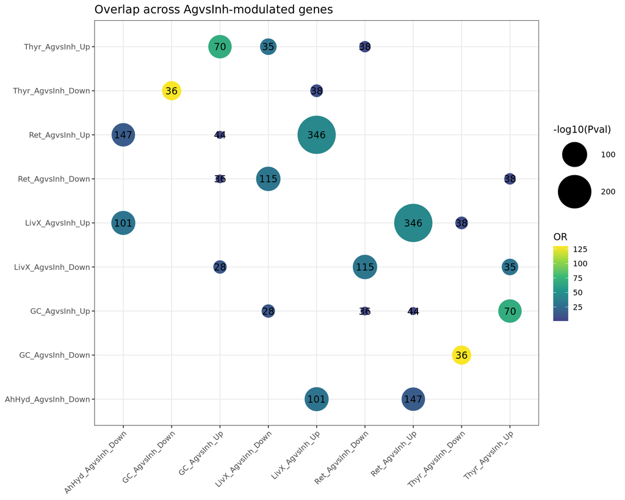

```r
Dot <- ggplot(ResSel, aes(DEGs, KBase, label=Numbers)) +
  geom_point(aes(size=-log10(Pval), col=OR)) +
  geom_text() +
  scale_size_continuous(range=c(2, 20), limits=c(2, round(-log10(min(ResSel$Pval)) + 0.5))) +
  scale_color_viridis_c(limits=c(1, round(max(ResSel$OR)+1)), begin=0.2) + xlab('') + ylab('') +
  theme_bw() +
  theme(axis.line = element_blank(), axis.title = element_blank(),
        axis.text.x = element_text(angle = 45, hjust = 1)) +
    ggtitle('Overlap across AgvsInh-modulated genes')

Dot
```

```r
ggsave(Dot, filename=paste0(OutputFolder, 'DotPlot_AgvsInh.pdf'), width=8, height=8)
```

## 7.3 Visualize overlap results selectively for retinoic, liverX, estrogen, thyroid

### Selection

```r
Path <- c('Thyr_AgvsInh_Up', 'Thyr_AgvsInh_Down', 'Ret_AgvsInh_Up', 'Ret_AgvsInh_Down',
          'Estr_AgvsInh_Up', 'Estr_AgvsInh_Down', 'LivX_AgvsInh_Up', 'LivX_AgvsInh_Down')
ResPath <- ResSel[ResSel$DEGs %in% Path & ResSel$KBase %in% Path, ]

ResPath
##                 DEGs             KBase        OR          Pval Numbers
## 1   Ret_AgvsInh_Down   Thyr_AgvsInh_Up  4.839574  5.098246e-13      38
## 3  LivX_AgvsInh_Down   Thyr_AgvsInh_Up 30.507319  1.560632e-35      35
## 5    LivX_AgvsInh_Up Thyr_AgvsInh_Down  6.680186  1.555239e-17      38
## 7    LivX_AgvsInh_Up    Ret_AgvsInh_Up 43.770373 5.369891e-272     346
## 9    Thyr_AgvsInh_Up  Ret_AgvsInh_Down  4.839574  5.098246e-13      38
## 11 LivX_AgvsInh_Down  Ret_AgvsInh_Down 31.801142  1.312420e-94     115
## 17 Thyr_AgvsInh_Down   LivX_AgvsInh_Up  6.680186  1.555239e-17      38
## 18    Ret_AgvsInh_Up   LivX_AgvsInh_Up 43.770373 5.369891e-272     346
## 20   Thyr_AgvsInh_Up LivX_AgvsInh_Down 30.507319  1.560632e-35      35
## 21  Ret_AgvsInh_Down LivX_AgvsInh_Down 31.801142  1.312420e-94     115
```

### DotPlot: visualization

```r
ResPath <- dplyr::filter(ResPath, OR > 2) %>% dplyr::filter(Numbers > 25)
min(ResPath$Pval)
```

```
## [1] 5.369891e-272
```

```r
max(ResPath$OR)
```

```
## [1] 43.77037
```

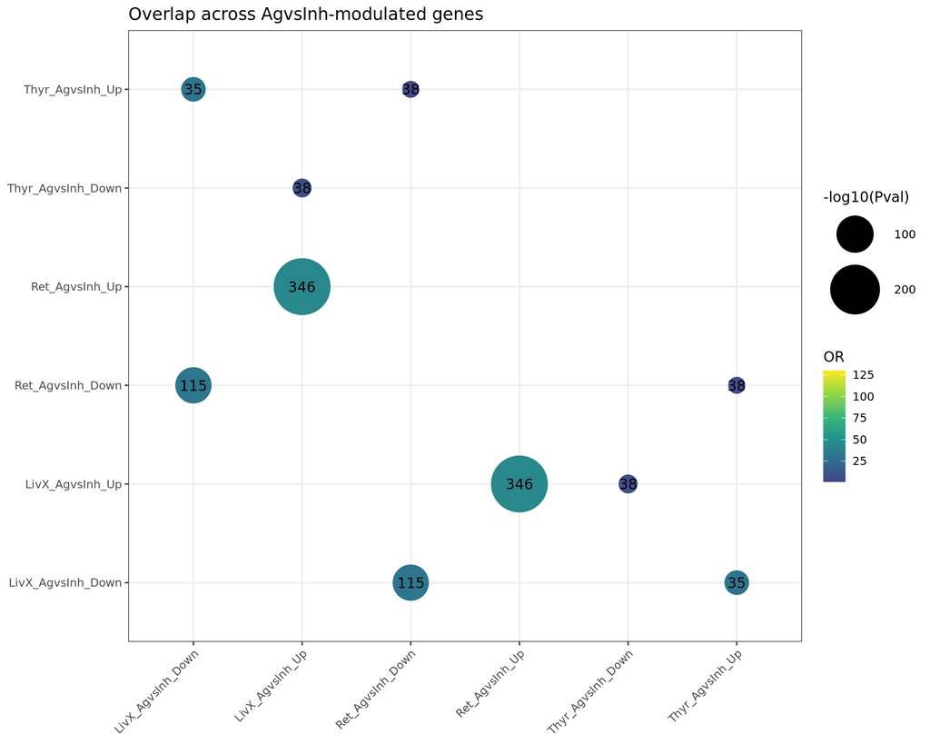

```r
Dot <- ggplot(ResPath, aes(DEGs, KBase, label=Numbers)) +
  geom_point(aes(size=-log10(Pval), col=OR)) +
  geom_text() +
  scale_size_continuous(range=c(2, 20), limits=c(2, round(-log10(min(ResSel$Pval)) + 0.5))) +
  scale_color_viridis_c(limits=c(1, round(max(ResSel$OR)+1)), begin=0.2) + xlab('') + ylab('') +
  theme_bw() +
  theme(axis.line = element_blank(), axis.title = element_blank(),
        axis.text.x = element_text(angle = 45, hjust = 1))+
  ggtitle('Overlap across AgvsInh-modulated genes')


Dot
```

```r
ggsave(Dot, filename=paste0(OutputFolder, 'DotPlot_AgvsInh_Selected.pdf'), width=8, height=8)
```

## 8. Session info

```r
SessionInfo <- sessionInfo()
Date <- date()
```

```r
Date
```

```
## [1] "Tue Jul 22 17:29:43 2025"
```

```r
SessionInfo
```